# **Data Modeling**

Fernando Nakamoto

2025-05-12

# Introduction

Data modeling is a fundamental process in statistics and data science that allows us to understand relationships, make predictions, and extract valuable insights from data. By applying mathematical and statistical techniques, we can build models that describe patterns, quantify uncertainty, and support decision-making in various fields, from finance and environmental sciences to business analytics and artificial intelligence.

This document explores different aspects of data modeling, covering essential statistical distributions, regression analysis, and machine learning techniques. Through theoretical discussions and practical case studies, we aim to provide a comprehensive guide to modeling approaches, their mathematical foundations, and their real-world applications.

# Statistics

## Distributions

A distribution is a fundamental concept in statistics that describes how values of a random variable are spread or dispersed. It provides insights into the likelihood of different outcomes and helps in understanding patterns within data. Distributions can be discrete, where the variable takes specific values (e.g., the number of customer arrivals in a store), or continuous, where the variable can take any value within a range (e.g., height measurements).

### Normal

The **normal distribution** models many natural phenomena.

#### Probability Density Function (PDF)

$$\begin{align*}
f(x) = \frac{1}{\sigma \sqrt{2\pi}} e^{-\frac{(x - \mu)^2}{2\sigma^2}},
\quad x \in (-\infty, \infty)
\end{align*}$$

#### Properties

- Mean: $\mu$
- Variance: $\sigma^2$
- Bell-shaped and symmetric

### Z

#### Probability Density Function (PDF)

The Z Distribution, also known as standard normal distribution, is a normal distribution with $\mu = 0$ and $\sigma = 1$:

$$\begin{align*}
f(z) = \frac{1}{\sqrt{2\pi}} e^{-\frac{z^2}{2}}, \quad z \in (-\infty,
\infty)
\end{align*}$$

#### Properties

- Mean: $\mu = 0$
- Variance: $\sigma^2 = 1$
- Symmetric about $z = 0$

### t

The t Distribution occurs when we don’t have the populational variance, and we want to find standardized probabilities involving $\overline{X}$. When we standardize based on sample standard deviation $s_x$, our statistic is called t distribution. The t distribution has a similar shape of the standard normal distribution, but is has **more area in the tails**.

Like any standardized statistic, t tells us how far $\overline{X}$ is from its mean μ in standard deviation units. However, there is a different t distribution for each sample size, specified by its degrees of freedom (df).

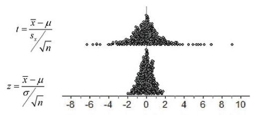

When comparing the density curves of the standard Normal distribution and t distributions, several facts are apparent:

- The density curves of the t distributions are similar in shape to the standard Normal curve.
- The spread of the t distributions is a bit larger than that of the standard Normal distribution.
- The t distributions have more probability in the tails and less in the center than does the standard Normal.
- As the degrees of freedom increase, the t density curve becomes ever closer to the standard Normal curve.

### F

The **F-distribution** arises in the analysis of variance (ANOVA) and hypothesis testing of variance ratios. It is used to compare variances of two independent normal distributions.

#### Probability Density Function (PDF)

$$\begin{align*}
f(x) = \frac{\Gamma(\frac{d_1 + d_2}{2})}{\Gamma(\frac{d_1}{2})
\Gamma(\frac{d_2}{2})} \cdot \left( \frac{d_1}{d_2}
\right)^{\frac{d_1}{2}} \cdot \frac{x^{\frac{d_1}{2} - 1}}{\left(1 +
\frac{d_1}{d_2} x \right)^{\frac{d_1 + d_2}{2}}}, \quad x > 0
\end{align*}$$

where: * $d_1$ = degrees of freedom of the numerator. * $d_2$ = degrees of freedom of the denominator.

#### Properties

- Mean: $\frac{d_2}{d_2 - 2}$ (for $d_2 > 2$)
- Variance:

$$\begin{align*}
\frac{2 d_2^2 (d_1 + d_2 - 2)}{d_1 (d_2 - 2)^2 (d_2 - 4)}, \quad d_2
> 4
\end{align*}$$

- **Right-skewed**, becomes more symmetric as $d_1, d_2$ increase.
- Used in **ANOVA**, regression, and **hypothesis testing**.

### Chi-Squared

The **Chi-Squared** distribution arises in statistical tests.

#### Probability Density Function (PDF)

$$\begin{align*}
f(x) = \frac{x^{\frac{k}{2}-1} e^{-\frac{x}{2}}}{2^{\frac{k}{2}}
\Gamma(\frac{k}{2})}, \quad x > 0
\end{align*}$$

#### Properties

- Mean: $k$
- Variance: $2k$
- Only defined for $x > 0$

### Gamma

The **Gamma** distribution generalizes the Exponential.

#### Probability Density Function (PDF)

$$\begin{align*}
f(x) = \frac{\lambda^\alpha x^{\alpha - 1} e^{-\lambda
x}}{\Gamma(\alpha)}, \quad x > 0
\end{align*}$$

#### Properties

- Mean: $\frac{\alpha}{\lambda}$
- Variance: $\frac{\alpha}{\lambda^2}$

### Beta

The **Beta** distribution models probabilities.

#### Probability Density Function (PDF)

$$\begin{align*}
f(x) = \frac{x^{\alpha - 1} (1 - x)^{\beta - 1}}{B(\alpha, \beta)},
\quad 0 \leq x \leq 1
\end{align*}$$

#### Properties

- Mean: $\frac{\alpha}{\alpha + \beta}$
- Variance: $\frac{\alpha \beta}{(\alpha + \beta)^2 (\alpha + \beta + 1)}$

### Bernoulli

The **Bernoulli** distribution models a single trial with two outcomes.

#### Probability Mass Function (PMF)

$$\begin{align*}
P(X = k) = p^k (1 - p)^{1-k}, \quad k \in \{0,1\}
\end{align*}$$

#### Properties

- Mean: $p$
- Variance: $p(1 - p)$
- Discrete distribution

### Binomial

The **Binomial** distribution models the number of successes in $n$ independent trials.

#### Probability Mass Function (PMF)

$$\begin{align*}
P(X = k) = \binom{n}{k} p^k (1 - p)^{n-k}, \quad k = 0, 1, \dots, n
\end{align*}$$

#### Properties

- Mean: $np$
- Variance: $np(1 - p)$
- Used for repeated Bernoulli trials

### Geometric

The **Geometric** distribution models the number of trials before the first success.

#### Probability Mass Function (PMF)

$$\begin{align*}
P(X = k) = (1 - p)^{k-1} p, \quad k = 1, 2, 3, \dots
\end{align*}$$

#### Properties

- Mean: $\frac{1}{p}$
- Variance: $\frac{1 - p}{p^2}$

### Poisson

The **Poisson** distribution models the number of events in a fixed interval.

#### Probability Mass Function (PMF)

$$\begin{align*}
P(X = k) = \frac{\lambda^k e^{-\lambda}}{k!}, \quad k = 0, 1, 2, \dots
\end{align*}$$

#### Properties

- Mean: $\lambda$
- Variance: $\lambda$

### Exponential

The **Exponential** distribution models waiting times between Poisson events.

#### Probability Density Function (PDF)

$$\begin{align*}
f(x) = \lambda e^{-\lambda x}, \quad x > 0
\end{align*}$$

#### Properties

- Mean: $\frac{1}{\lambda}$
- Variance: $\frac{1}{\lambda^2}$

### Uniform

The **Uniform** distribution is where all values are equally likely.

#### Probability Density Function (PDF)

$$\begin{align*}
f(x) = \frac{1}{b - a}, \quad a \leq x \leq b
\end{align*}$$

#### Properties

- Mean: $\frac{a + b}{2}$
- Variance: $\frac{(b - a)^2}{12}$

## Likelihood

The likelihood function measures how probable the observed data is, given a specific set of model parameters. In the context of logistic regression, where the response variable is binary (0 or 1), we assume each observation follows a Bernoulli distribution with a probability $p_i$ of success (i.e., $y_i$ =1). The likelihood function L(β) is the product of the probabilities assigned to each observation by the model. Because this product can become very small, it is common to work with the log-likelihood, which simplifies computation and transforms the product into a sum. The coefficients in a logistic regression model are estimated by maximizing this log-likelihood — a process known as maximum likelihood estimation (MLE). The deviance, often reported in model summaries, is derived from the log-likelihood and provides a measure of model fit.

$$\begin{align*}
L(\boldsymbol{\beta}) &= \prod_{i=1}^{n} p_i^{y_i}(1 - p_i)^{1 -
y_i} \\
\log L(\boldsymbol{\beta}) &= \sum_{i=1}^{n} \left[ y_i \log(p_i) +
(1 - y_i) \log(1 - p_i) \right]
\end{align*}$$

While for probability we have model parameters and data is unknown (“given this model, what’s the chance of this data?”), for likelihood we have the data, and the model parameters are unknown (“given this data, how likely is this model?”).

# Simple Linear Regression

## Overview

The simple linear regression model can be resumed by:

$$\begin{align*}
y_i = \beta_0 + \beta_1*x_i + e_i
\end{align*}$$

Where $\beta_0$ and $\beta_1$ are the coefficients, $y_i$ is the predicted variable, $x_i$ is the independent variable and $e_i$ is the residual. To find a good fit of the regression parameters ($\beta_0$ and $\beta_1$), we employ the **method of least squares**. Usinng an analytical approach, we get that the parameters can be solved by:

$$\begin{align*}
b_1 = \frac{\sum(X_i - \overline{X})(Y_i - \overline{Y})}{\sum(X_i -
\overline{X})^2}
\end{align*}$$

$$\begin{align*}
b_0 = \overline{Y} - b_1\overline{X}
\end{align*}$$

The estimated regression line fitted by the method of least squares has 6 main properties:

1. The sum of the residuals is zero:

$$\begin{align*}
\sum_{i=1}^{n}e_i = 0
\end{align*}$$

2. The sum of the squared residuals ($\sum e_{i}^{2}$) is minimal.
3. The sum of the observed values $Y_i$ equals the sum of the fitted values :

$$\begin{align*}
\sum_{i=1}^{n}Y_i = \sum_{i=1}^{n}\hat{Y}_i
\end{align*}$$

4. The sum of the weighted residuals (by X) is zero:

$$\begin{align*}
\sum_{i=1}^{n}X_i e_i = 0
\end{align*}$$

5. The sum of the weighted residuals (by fitted Y) is zero:

$$\begin{align*}
\sum_{i=1}^{n}\hat{Y}_i e_i = 0
\end{align*}$$

6. The regression line always goes through the point $(\overline{X},\overline{Y})$

## Statistical inferences

Statistical inference in simple linear regression involves drawing conclusions about the population relationship between an independent variable (X) and a dependent variable (Y) based on a sample. The primary goal is to estimate the regression parameters $(\beta_0,\beta_1)$ and assess their significance.

This is typically done using confidence intervals and hypothesis testing. The least squares method provides estimates $b_0$ and $b_1$, which are subject to sampling variability.

To evaluate the reliability of these estimates, we use the standard errors, which allow us to construct confidence intervals for $\beta_1$ and test hypotheses such as $H_0 :\beta1 = 0$ (indicating no relationship). The t-test is commonly applied to check whether $\beta_1$ is significantly different from zero, and the coefficient of determination $R^2$ helps quantify how well the model explains the variability in Y.

### $\beta_1$

We have that the estimated variance is:

$$\begin{align*}
s_{b_1}^2 = \frac{MSE}{\sum(X_i - \overline{X})^2}
\end{align*}$$

Since $b_1$ is normally distributed, we know that the standardized statistic $\frac{(b_1 - \beta_1)}{\sigma_{b_1}}$ is a standard normal variable. An theorem states that :

$$\begin{align*}
\frac{(b_1 - \beta_1)}{\sigma_{b_1}} \sim t(n-2)
\end{align*}$$

To see about confidence interval for $\beta_1$, see in “Confidence Interval”. To analyse if the parameter is significant, we can do the two sided test. We have two alternatives:

$$\begin{align*}
H_0: \beta_1 = 0 \\
H_a: \beta_1 \neq 0
\end{align*}$$

To test the null hypothesis $H_0: \beta_1 = 0$, we can compute the critical t statistic:

$$\begin{align*}
t^* = \frac{b_1}{s_{b_1}}
\end{align*}$$

The decision rule with this test statistic for controlling the level of significance at a is:

$$\begin{align*}
\text{if } |t^*| \le t(1-\frac{\alpha}{2}, n-2), \text{conclude } H_0 \\
\text{if } if |t^*| > t(1-\frac{\alpha}{2}, n-2), \text{conclude
} H_a
\end{align*}$$

### $\beta_0$

There are only infrequent occasions when we wish to make inferences concerning $\beta_0$, the intercept of the regression line. These occur when the scope of the model includes X = 0 times.

We have that the estimated variance is:

$$\begin{align*}
s_{b_0}^2 = MSE \left[ \frac{1}{n}+\frac{\overline{X}^2}{\sum(X_i -
\overline{X})^2} \right]
\end{align*}$$

Similar to $b_1$, the sampling distributions follows a t distribution with n-2 degree of freedom.

$$\begin{align*}
\frac{(b_0 - \beta_0)}{\sigma_{b_0}} \sim t(n-2)
\end{align*}$$

### $R^2$

The total variation (SSTO or SST) is:

$$\begin{align*}
SST = \sum_{i=1}^{n} \left( Y_i - \overline{Y} \right)^2
\end{align*}$$

The total error (SSE) or sum of squares of error is:

$$\begin{align*}
SSE = \sum_{i=1}^{n} \left( Y_i - \hat{Y}_i \right)^2
\end{align*}$$

The total regression (SSR) or regression sum of squares is:

$$\begin{align*}
SSR = \sum_{i=1}^{n} \left( \hat{Y}_i - \overline{Y} \right)^2
\end{align*}$$

The Cochran’s theorem states that the sum of squares of residuals and fitted values can be decomposed into independent chi-square distributed components. If we define sums of squares such as SST (Total Sum of Squares), SSR (Regression Sum of Squares), and SSE (Error Sum of Squares), they follow:

$$\begin{align*}
SST = SSE + SSR
\end{align*}$$

The mean square (MS) is the sum of square (SS) divided by the degree of freedom (df). Therefore the MSR (regression meman squarer) is:

$$\begin{align*}
MSR = \frac{SSR}{1}
\end{align*}$$

And the MSE (error mean square) is:

$$\begin{align*}
MSR = \frac{SSE}{n-2}
\end{align*}$$

The coefficient of determination $R^2$ represents how much of the total variance the model isi able to explain:

$$\begin{align*}
R^2 = \frac{SSR}{SST} = 1 - \frac{SSE}{SST}
\end{align*}$$

Limitations and misunderstandings:

- A high coefficient of determination indicates that useful predictions can be made. This is not necessarily correct.
- A high coefficient of determination indicates that the estimated regression line is a good fit;-Again, this is not necessarily correct.
- A coefficient of determination near zero indicates that X and Y are not related. This also is not necessarily correct, because the relationship can be curvilinear for example.

### Confidence Intervals

The confidence level, or C, is the overall capture rate if the method is used many times. The sample mean will vary from sample to sample, but when we use the method “estimate ± margin of error” to get each interval, C × 100% of all intervals capture the unknown population mean μ.

The sampling distribution of $\overline{X}$ tell us how close to μ the sample mean is likely to be. A confidence interval has the form “estimate ± margin of error”. We often choose a confidence level of 90% of higher becacuse we want to be quite sure about our conclusions. The most common confidence level is 95%.

The margin of error (m) depends normally on the confidence level C and on Z*. Higher confidence C implies a larger margin of error m (thus less precision in our estimates).

$$\begin{align*}
m = Z^*\frac{\sigma}{\sqrt{n}}
\end{align*}$$

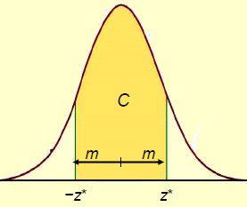

Confidence interval can vary a lot, depending on the data type and model utilized, as seem in the flowchart below.

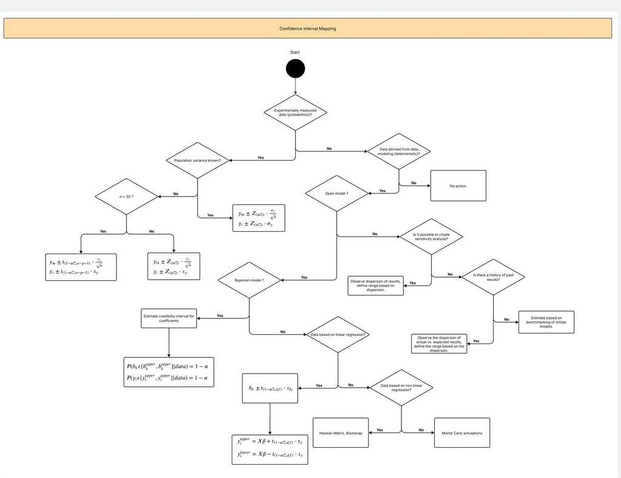

For a simple linear regression, we have that the confidence interval for $\beta_1$ is:

$$\begin{align*}
\beta_1 \pm t(1-\frac{\alpha}{2}, n-2)s_{b_1}
\end{align*}$$

Similarly, we have that the confidence interval for $\beta_0$ is:

$$\begin{align*}
\beta_0 \pm t(1-\frac{\alpha}{2}, n-2)s_{b_0}
\end{align*}$$

The confidence band is a region that likely contains the entire regression line across all x-values. The Working-Hoteling confidence band provides a simultaneous confidence intervals for the entire regression line. The formula given is:

$$\begin{align*}
\hat{Y}_h \pm W \cdot s_{\hat{Y}_h}
\end{align*}$$

Where:

- $W^2=2F(1-\frac{\alpha}{2},2, n-2)$ and F is the F-distribution.
- $s_{\hat{Y}_h}$ is the standard error of the fitted values.

In other words, the confidence band is constructed using:

### F test

The ANOVA table provide us with a test:

$$\begin{align*}
H_0: \beta_1 = 0 \\
H_a: \beta_1 \neq 0
\end{align*}$$

The F statistics is:

$$\begin{align*}
F^* = \frac{MSR}{MSE} = \frac{SSR}{\frac{SSE}{n-2}}
\end{align*}$$

For large values of $F^*$, we can conclude $H_a$. And if $F^*$ is near 1, we conclude $H_0$.

The critical F statistics is:

$$\begin{align*}
F \left( 1- \frac{\alpha}{2},1,n-2 \right)
\end{align*}$$

Hence:

$$\begin{align*}
\text{if } F^* \le F \left( 1- \frac{\alpha}{2},1,n-2 \right),
\text{conclude } H_0, \\
\text{if } F^* > F \left( 1- \frac{\alpha}{2},1,n-2 \right),
\text{conclude } H_a,
\end{align*}$$

### GLT

Help to answer if a variable is significant to the model. One way to do it is to check the p-value, however the General Lineat Test (GLT) drop the variable out of the model , and then the reduced model is compared to the full model.In ML models we don’t have p-values, so it’s used this idea. Let me drop one variable from the model to see the impact.

$$\begin{align*}
H_0: \beta_1 = 0 \\
H_a: \beta_1 \neq 0
\end{align*}$$

First step is to fit the full model and $SSE(F)$. Then fit the reduced model under $H_0$ and $SSE(R)$.

$$\begin{align*}
SSE(F) = \sum{ \left(Y_i - \hat{Y}_i \right)^2} = SSE \\
SSE(R) = \sum {\left( Y_i - \overline{Y} \right)^2} = SST
\end{align*}$$

If $SSE(F) \le SSE(R)$, suggests that using full model does not account for much more of the variability of the $Y_i$ than does the reduced model. It suggest that the reduced model is adequate, and $H_0$ holds.

## Diagnostics

When a regression model, such as the simple linear regression model, is considered for an application, we can usually not be certain in advance that the model is appropriate for that application. Anyone, or several, of the features of the model, such as linearity of the regression function or normality of the error terms, may not be appropriate for the particular data at hand. Hence, it is important to examine the aptness of the model for the data before inferences based on that model are undertaken.

Linear regression relies on the **Gauss-Markov** assumptions to ensure the results are valid:

- Linearity: the relationship between X and Y must be linear.
- Independence: the observations must be independent.
- Homoscedasticity: the variance of the residuals must be constant across all fitted values.
- Normality: residuals should be normally distributed.
- No perfect multicollinearity: independent variables should not be perfectly correlated.

### Properties of residuals

**Mean**: the mean of the residuals for the simple linear regression model is:

$$\begin{align*}
\overline{e} = \frac{\sum_{i=1}^{n}e_i}{n} = 0
\end{align*}$$

**Variance**: the variance of the residuals for the simple linear regression model is:

$$\begin{align*}
s^2 = \frac{\sum_{i=1}^{n} \left(e_i - \overline{e} \right)^2 }{n-2} =
\frac{SSE}{n-2} = MSE
\end{align*}$$

**semistudentized residuals**:The semistudentized residuals for the simple linear regression model is:

$$\begin{align*}
e_{i}^2 = \frac{\left(e_i - \overline{e} \right) }{\sqrt{MSE}} =
\frac{\left(e_i\right) }{\sqrt{MSE}}
\end{align*}$$

### Homoscedasticity

Homoscedasticity refers to the assumption that the variance of the residuals (errors) remains constant across all levels of the independent variable(s) in a regression model. When this assumption holds, the spread of residuals is roughly the same for all predicted values, ensuring reliable standard errors and valid hypothesis tests.

A violation of homoscedasticity (heteroscedasticity) occurs when the variance of residuals changes systematically, often forming a funnel shape in a residuals vs. fitted values plot. This can lead to inefficient estimates and misleading statistical inferences.

To check for homoscedasticity, analysts use residual plots and formal tests like the Breusch-Pagan test. If heteroscedasticity is detected, solutions include transforming the response variable (e.g., log transformation) or using robust standard errors to adjust for non-constant variance.

#### **Breusch - Pagan Test**

The Breusch-Pagan Test is a test to check homoscedasticity. The hypothesis are:

- $H_0$: the residual variance is constant (homoscedasticity).
- $H_a$: the residual variance depends on one or more explanatory variables (heteroscedasticity present).

If the p-value is small (<0.05) we reject $H_0$ and heteroscedasticity is present. If the p-value is large (>0.05) we fail to reject $H_0$ and homoscedasticity holds.

```r
install.packages("lmtest")  # Install the package (only needed once)
library(lmtest)  # Load the package
#Breusch-Pagan Test
bptest(model_1)
```

#### **Brown-Forsythe Test**

The Brown-Forsythe Test is a robust test for homogeneity of variances (homoscedasticity). It is a modified version of Levene’s test that uses the median instead of the mean, making it more robust to non-normality.

The hypotheses are:

- $H_0$: The residual variance is the same across groups (homoscedasticity holds).
- $H_a$: The residual variance is different across groups (heteroscedasticity is present).

If the p-value is small (< 0.05), we reject $H_0$, indicating that the residual variance is not constant (heteroscedasticity is present). If the p-value is large (> 0.05), we fail to reject $H_0$, meaning that homoscedasticity holds.

```r
install.packages("car")  # Install the package (only needed once)
library(car)  # Load the package

# Perform Brown-Forsythe Test
leveneTest(residuals_1 ~ as.factor(group), data = Data_1, center = median)


###example: Divide the 81 cases into two groups. placing the 40 cases with the smallest fitted values into group 1 and the remaining cases into group 2. Conduct the Brown-Forsythe test and check all model assumptions.

library(car)

# Compute fitted values from the model
Data_1$fitted_values <- fitted(model_1)

# Divide data into two groups based on fitted values
Data_1$group <- ifelse(rank(Data_1$fitted_values) <= 40,1,2)

# Perform Brown-Forsythe test
bf_test <- leveneTest(residuals_1 ~ as.factor(group), data = Data_1, center = median)

# Display results
print(bf_test)
```

#### **Residual Plot**

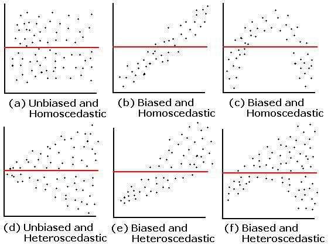

```r
# Residual x Fitted values plot
plot(model_1$fitted.values, resid(model_1),
     xlab = "Fitted Values", ylab = "Residuals",
     main = "Residuals vs Fitted Values")
abline(h = 0, col = "red")  # Adds reference line
```

### Normality

The normality assumption in regression states that the residuals (errors) should follow a normal distribution. This assumption is particularly important when conducting hypothesis tests on regression coefficients, as it ensures that p-values and confidence intervals are reliable. However, normality is not strictly required for estimating coefficients in Ordinary Least Squares (OLS) regression—OLS remains unbiased even if the errors are not normally distributed. The normality assumption becomes more critical in small samples, where violations can lead to incorrect inferences. In large samples, the Central Limit Theorem (CLT) helps mitigate issues with non-normal errors.

#### **Shapiro-Wilk Test**

The Shapiro-Wilk test is a statistical test used to determine whether a given sample comes from a normal distribution. The hypothesis are:

- $H_0$: the data follows a normal distribution.
- $H_a$: the data does not follows a normal distribution.

If W is close to 1 and p-value is large (>0.05), data is likely to be normally distributed. If W is far from 1 and p-value is small (<0.05), we reject the nunll hypothesis and thte residuals are not normally distributed.

```r
#Shapiro-Wilk Test
shapiro.test(resid(model_1))
```

#### **Q-Q Plot**

A Q-Q plot (Quantile-Quantile plot) is a graphical tool used to assess whether a dataset follows a particular theoretical distribution, most commonly the normal distribution. In regression analysis, we use Q-Q plots to check if the residuals are normally distributed, which is a key assumption for valid hypothesis tests and confidence intervals.

A Q-Q plot compares the quantiles of the observed residuals against the theoretical quantiles of a normal distribution. If the residuals are normally distributed, they should align closely with a 45-degree straight line.

For a S-shaped curve, with a skewness (left or right), we can apply a log or square root transformation. For a upward/downward curve at the ends, with a heavy tailed (kurtosis issue), we must consider a robust regression. A downward curve at both ends (light tailed or less variance than normal) suggests box-cox transformation, and random deviations with no clear pattern normally occurs with outliers or small sample size, and therefore removing outliers or getting more data should solve it.

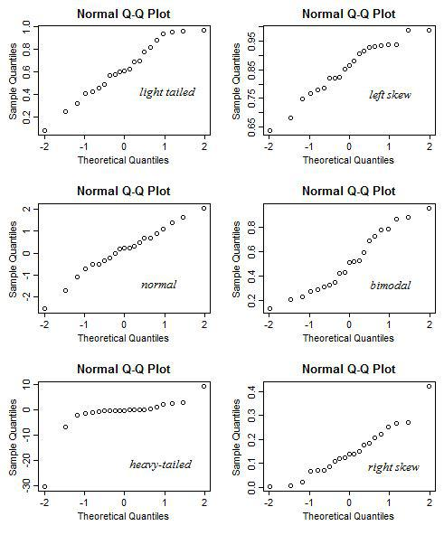

```r
# Q-Q Plot of residuals
plot(model_1, which = 2,
     col = "gray40",
     pch = 16)
```

### Leverage

Leverage measures how much an observation influences the predicted values in a regression model based on its position in the predictor space. Observations with extreme values in independent variables (X) have high leverage because they have more impact on the fitted regression line. Leverage points are observations that are very far away from the mean of the data, not necessarily an outlier though. Mathematically, leverage is given by the hat matrix H (see Overview in Multiple Linear Regression). The common rule to identify high leverage points is:

$$\begin{align*}
h_i > \frac{2(k+1)}{n}
\end{align*}$$

where k is the number of predictors and n is the sample size. Observations with $h_i$ exceeding this threshold are considered high leverage points.

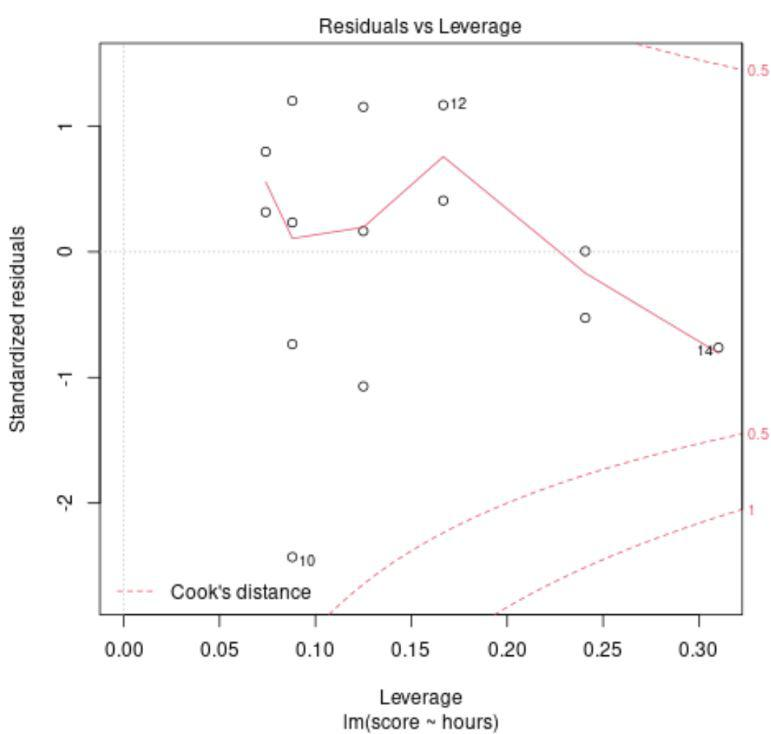

We can see high leverage points in “Residual vs Leverage” Plot. For influence, we can see Cook’s Distance interpretation: * Cook’s Distance > 1 → The point is highly influential and likely distorts the regression. * Cook’s Distance < 0.5 → The point has some influence but is not extreme.

### Outlier

An outlier is an extreme observation with a large residual, meaning it deviates significantly from the regression line. Outliers do not necessarily have high leverage or influence—some outliers may not distort the model significantly.

For a univariate outlier, we can do the InterQuartile Method (IQR):

```
# Function to detect outliers for each numeric variable, using Interquartile Range (IQR) method

detect_outliers <- function(x, column_name = NULL) {
  if (!is.numeric(x) || length(unique(x)) <= 2) return(NA)

    # Count negative values explicitly as outliers
    negative_outliers <- sum(x < 0, na.rm = TRUE)

    # Apply IQR method
    Q1 <- quantile(x, 0.25, na.rm = TRUE)
    Q3 <- quantile(x, 0.75, na.rm = TRUE)
    IQR <- Q3 - Q1

    # Set the lower bound to 0 (domain-specific rule)
    LowerBound <- max(0, Q1 - 1.5 * IQR)
    UpperBound <- Q3 + 1.5 * IQR

    # Identify IQR-based outliers
    iqr_outliers <- sum(x > UpperBound | (x >= 0 & x < LowerBound), na.rm = TRUE)

    # Return total outliers (negative + IQR-based)
    return(negative_outliers + iqr_outliers)
  }




# Apply the function with column names
outliers_count <- sapply(names(uswages),
                  function(col) detect_outliers(uswages[[col]],
                  column_name = col))


# Combine results into a data frame
outliers_df <- data.frame(
  Variable = colnames(uswages),
  Outliers = outliers_count

)

# Print the result
print(outliers_df)

boxplot(uswages$wage, main = "Boxplot of Wage", ylab = "Wage")
```

To check an outlier in a simple linear regression model we can do the semistudentized residual plot. Semistudentized residuals are standardized residuals:

$$\begin{align*}
r_i > \frac{e_i}{\hat{\sigma}_e}
\end{align*}$$

where $e_i$ is residual of observation i (difference between actual and predicted value), and $\hat{\sigma}_e$ is estimated standard deviation of residuals. A common rule for outliers is:

- $|r_i| > 4$: extreme outlier
- $|r_i| > 3$: potential strong outlier
- $|r_i| > 2$: Worth investigating, can be a moderate outlier

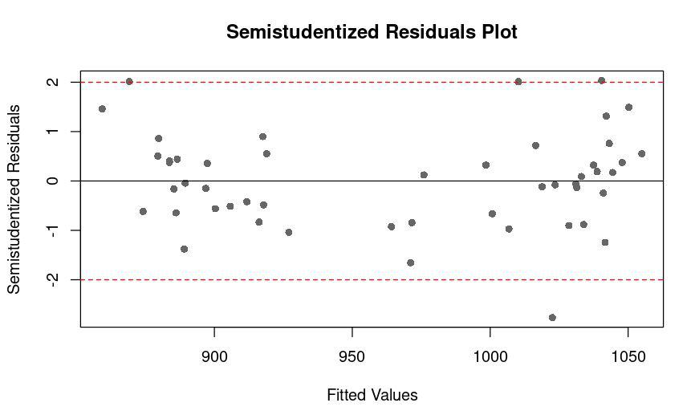

```r
# Compute residuals
residuals_1 <- resid(model_1)

# Compute estimated standard deviation of residuals (Residual Standard Error)
sigma_hat_1 <- summary(model_1)$sigma

# Compute semistudentized residuals
semistudentized_residuals_1 <- residuals_1 / sigma_hat_1

# Plot semistudentized residuals against fitted values
plot(fitted(model_1), semistudentized_residuals_1,
     col = "gray40", pch = 16,
     xlab = "Fitted Values", ylab = "Semistudentized Residuals",
     main = "Semistudentized Residuals Plot")

# Add a horizontal reference line at 0
abline(h = c(-2, 0, 2), col = c("red", "black", "red"), lty = c(2, 1, 2))



# Create a data frame of semi-studentized residuals with state names
outlier_data <- data.frame(
  State = rownames(data),
  SemiStudentized_Residuals = semistudentized_residuals_1
)

# Filter only the outliers (|residual| > 2)
outlier_data_filtered <- outlier_data[abs(outlier_data$SemiStudentized_Residuals) > 2, ]

# Print the results
print(outlier_data_filtered)
```

### Linearity

Linearity is one of the key assumptions in linear regression, meaning that the relationship between the independent variables (predictors) and the dependent variable (response) should be approximately linear. If the relationship is nonlinear, the model might provide biased predictions.

The most common way to check linearity is to plot a Residuals vs Fitted Plot. If the relationship is linear, the residuals should be randomly scattered around 0 without any systematic pattern.

CR plots (partial residual plots) help visualize the relationship between each predictor and the response while accounting for other predictors.

```r
# Component + Residual Plots
library(car)
crPlots(model_1)
```

#### **Box-Cox Transformation**

The Box-Cox transformation is a family of power transformations used to stabilize variance and make data more normally distributed. It is especially useful when the assumption of constant variance (homoscedasticity) and normality of residuals in linear regression is violated.

The Box-Cox transformation is defined as:

$$\begin{align*}
Y(\lambda) = \begin{cases}
\frac{Y^\lambda - 1}{\lambda}, & \text{if } \lambda \neq 0 \\
\log(Y), & \text{if } \lambda = 0
\end{cases}
\end{align*}$$

A 95% confidence interval for λ is given by:

$$\begin{align*}
\lambda_{\text{lower}}, \lambda_{\text{upper}} = \lambda_{\text{MLE}}
\pm 1.96 \cdot \frac{1}{\sqrt{n \cdot \text{Var}(\lambda)}}
\end{align*}$$

```r
#Box Cox Transformation
library(MASS)

boxcox_result <- boxcox(model_1, lambda = seq(-10, 10, 0.1))

# Identify optimum lambda
optimal_lambda <- boxcox_result$x[which.max(boxcox_result$y)]
cat("Optimal lambda:", optimal_lambda, "\n")
```

Decision on Transforming Y:

- if $\lambda \sim 1$, no transformation is needed (the data is already suitable for regression).
- if $\lambda = 0$, apply log transformation: $Y^*=log(Y)$.
- if $\lambda = 0.5$, use a square root transformation $Y^* = \sqrt{Y}$.
- if $\lambda <0 (negative)$, use a inverse transformation $Y^* = Y^{\lambda}$.

### Multicollinearity

Multicollinearity occurs when two or more predictor variables in a regression model are highly correlated, making it difficult to determine their individual effects on the response variable. This can lead to unstable estimates of regression coefficients and inflated standard errors, reducing the reliability of statistical inferences. They may occur when:

- High correlation between independent variables.
- Unstable regression coefficients (large changes when adding/removing predictors).
- Insignificant p-values for predictors despite a high $R^2$.
- High variance inflation factors (VIF).

#### **Correlation matrix**

A correlation matrix is a table that shows the correlation coefficients between multiple variables. It helps us understand how strongly two variables are related. The values in the matrix range from -1 to 1, where:

- r=1: Perfect positive correlation.
- r=-1: Perfect negative correlation
- r=0: No correlation

The Pearson correlation coefficient between two variables X and Y is given by:

$$\begin{align*}
r_{X,Y} = \frac{\sum (X_i - \overline{X})(Y_i -
\overline{Y})}{\sqrt{\sum (X_i - \overline{X})^2 \sum (Y_i -
\overline{Y})^2}}
\end{align*}$$

```r
# Compute correlation matrix for selected variables
cor_matrix <- round(cor(sat[, c("A", "B", "C", "D")]),2)
print(cor_matrix)
```

#### **Variance Inflation Factor (VIF)**

VIF measures how much the variance of a coefficient is inflated due to correlation with other predictors.

$$\begin{align*}
VIF_i = \frac{1}{1 - R^2_i}
\end{align*}$$

For interpretation, we have that:

- $VIF < 5$: low multicollinearity (acceptable)
- $5 \le VIF < 10$: moderate multicollinearity
- $VIF \ge 10$: high multicollinearity

```r
# Compute VIF values
vif_values <- vif(model_1)
print(round(vif_values,2))
```

# Multiple Linear Regression

Multiple regression analysis is one of the most widely used of all statistical methods. The goal here is to present and discuss some multiple regression models. Then, to present the basic statistical results for multiple regression in matrix form.

## Overview

The First Order Model with two predictor variables has the following regression model:

$$\begin{align*}
Y_i = \beta_0 + \beta_1 \cdot X_{i1} +\beta_2 \cdot X_{i2} + \epsilon_i
\end{align*}$$

Visually, it can be represented as a 3-axis graph.

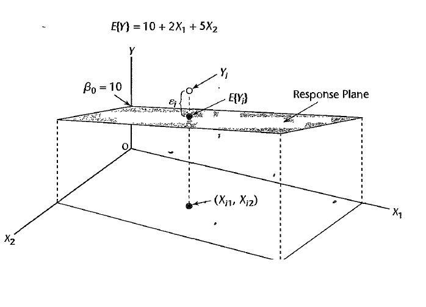

We can establish the meaning of $\beta_1$ and $\beta_2$ by taking the partial derivatives of the response surface:

$$\begin{align*}
\beta_1 = \displaystyle \frac{\partial E[Y]}{\partial X_1} \\
\beta_2 = \displaystyle \frac{\partial E[Y]}{\partial X_2}
\end{align*}$$

For a First Order Model with p-1 predictor variables $X_1 ,\cdots, X_{p-1}$, the regression model is:

$$\begin{align*}
Y_i = \beta_0 + \beta_1 \cdot X_{i,1} + \beta_2 \cdot X_{i,2} + \cdots
+\beta_{p-1} \cdot X_{i,p-1} +\epsilon_i
\end{align*}$$

### **Qualitative predictor variables**

For a qualitative predictor variables, say for example:

$$\begin{align*}
X_{i2} = \begin{cases}
1, & \text{for } A\\
0, & \text{for } B
\end{cases}
\end{align*}$$

For A, when $X_{i2} = 1$:

$$\begin{align*}
Y_i = (\beta_0 +\beta_2) + \beta_1 \cdot X_{i,1} + \epsilon_i
\end{align*}$$

For B, when $X_{i2} = 0$:

$$\begin{align*}
Y_i = \beta_0 + \beta_1 \cdot X_{i,1} + \epsilon_i
\end{align*}$$

Therefore, we will have two parallel lines.

### **Matrix Terms**

In Matrix Terms, we need to define the following matrices:

$$\begin{align*}
X = \begin{bmatrix}
1 & x_{1,1} & \cdots & X_{1,p-1}\\
1 & x_{2,1} & \cdots & X_{2,p-1}\\
\cdots & \cdots & \cdots & \cdots\\
1 & x_{n,1} & \cdots & X_{n,p-1}
\end{bmatrix}
\end{align*}$$

$$\begin{align*}
Y = \begin{bmatrix}
Y_1\\
Y_2\\
\cdots\\
Y_n
\end{bmatrix}
\end{align*}$$

$$\begin{align*}
\beta = \begin{bmatrix}
\beta_1\\
\beta_2\\
\cdots\\
\beta_n
\end{bmatrix}
\end{align*}$$

$$\begin{align*}
\epsilon = \begin{bmatrix}
\epsilon_1\\
\epsilon_2\\
\cdots\\
\epsilon_n
\end{bmatrix}
\end{align*}$$

In Matrix terms, the general linear regression model is:

$$\begin{align*}
Y = X \beta + \epsilon
\end{align*}$$

By the least squares method, the vector b of coefficients $b_0, \cdots, b_n$ is calculated as:

$$\begin{align*}
b = (X^`X)^{-1}(X^`X)Y
\end{align*}$$

Let the vector of the fitted values $\hat{Y}_i$ denoted as $\hat{Y}$ and the residual terms $e_i = Y_i - _i $ denoted as $e_i$:

$$\begin{align*}
e = \begin{bmatrix}
e_1\\
e_2\\
\cdots\\
e_n
\end{bmatrix}
\end{align*}$$

$$\begin{align*}
\hat{Y} = \begin{bmatrix}
\hat{Y}_1\\
\hat{Y}_2\\
\cdots\\
\hat{Y}_n
\end{bmatrix}
\end{align*}$$

The fitted values are represented by:

$$\begin{align*}
\hat{Y} = Xb
\end{align*}$$

and the residual terms by:

$$\begin{align*}
e = Y - \hat{Y} = Y - Xb
\end{align*}$$

The vector of the fitted values can be defined as:

$$\begin{align*}
\hat{Y} = HY
\end{align*}$$

where the hat matrix H is:

$$\begin{align*}
H = X(X^`X)^{-1}(X^`)
\end{align*}$$

Leverage measures how much an observation influences the predicted values in a regression model based on its position in the predictor space. Observations with extreme values in independent variables (X) have high leverage because they have more impact on the fitted regression line. Mathematically, leverage is given by the hat matrix. The common rule to identify high leverage points is:

$$\begin{align*}
h_i > \frac{2(k+1)}{n}
\end{align*}$$

where k is the number of predictors and n is the sample size. Observations with $h_i$ exceeding this threshold are considered high leverage points.

We have a high leverage if $h_i > 0.5$ and moderate leverage if $0.2<h_i < 0.5$.

```r
#Residuals vs Leverage Plot
plot(model_1, which = 5,
     col = "gray40",
     pch = 16)


# Extract leverage values
leverage_values <- hatvalues(model_1)
threshold <- 2 * (4 + 1) / nrow(data)  # k = 4 predictors, so (4+1)
print(threshold)  # Displays the cutoff leverage value

high_leverage_points <- which(leverage_values > threshold)
print(high_leverage_points)  # Shows indices of high leverage points

# Showing the hi values for the high leverage points
leverage_values[rownames(data) == "A"]
leverage_values[rownames(data) == "B"]
...
```

## Statistical inferences

### **Estimating Regression Coefficients**

The least squares method minimizes the sum of squared residuals:

$$\begin{align*}
Q = \sum_{i=1}^{n} (y_i - \beta_0 - \sum_{k=1}^{p-1} \beta_k X_{ik})^2
\end{align*}$$

The normal equations for estimating the regression coefficients in matrix form are:

$$\begin{align*}
\mathbf{b} = (\mathbf{X'X})^{-1} \mathbf{X'Y}
\end{align*}$$

where: - $\mathbf{X}$ is the matrix of predictor variables (including a column of ones for the intercept), - $\mathbf{Y}$ is the vector of response values, - $\mathbf{b}$ is the vector of estimated coefficients.

### **Interpretation of Regression Coefficients**

Each regression coefficient $\beta_k$ represents the expected change in $Y$ for a one-unit increase in $X_k$, holding all other predictors constant:

$$\begin{align*}
\frac{\partial E(Y)}{\partial X_k} = \beta_k
\end{align*}$$

If predictor variables interact, their effects are not additive, and an interaction term $\beta_{k,m} X_k X_m$ should be included.

### **Analysis of Variance (ANOVA)**

The total variation in $Y$ is decomposed into:

$$\begin{align*}
SSTO &= \sum (y_i - \overline{y})^2 \quad \text{(Total Sum of
Squares)} \\
SSR &= \sum (\hat{y}_i - \overline{y})^2 \quad \text{(Regression Sum
of Squares)} \\
SSE &= \sum (y_i - \hat{y}_i)^2 \quad \text{(Error Sum of Squares)}
\end{align*}$$

with the relationship:

$$\begin{align*}
SSTO = SSR + SSE
\end{align*}$$

### **Goodness of Fit**

The **coefficient of multiple determination** $R^2$ measures how well the predictors explain the variance in $Y$:

$$\begin{align*}
R^2 = \frac{SSR}{SSTO} = 1 - \frac{SSE}{SSTO}
\end{align*}$$

An adjusted version $R^2_{adj}$ accounts for the number of predictors:

$$\begin{align*}
R^2_{adj} = 1 - \frac{SSE/(n - p)}{SSTO/(n - 1)}
\end{align*}$$

The adjusted $R^2$ is designed to penalize the inclusion of additional parameters to prevent overfitting. The penalizing term is (n-p).As p increases, (n−p) gets smaller, which should increase the SSE term and lower the adjusted $R^2$. However, we have extreme scenarios that adjusted $R^2$ still tends to 1.

In an overfitting scenario, If p is very close to n (for example, 1000 parameters for 1050 observations), the model overfits the data. This means the residual error SSE is nearly zero, making the numerator in the adjusted $R^2$ tends to zero.

### **Hypothesis Testing**

To test if the regression model is significant, we use the **F-test**:

$$\begin{align*}
H_0: \beta_1 = \beta_2 = ... = \beta_{p-1} = 0 \\
H_a: \text{At least one } \beta_k \neq 0
\end{align*}$$

Test statistic:

$$\begin{align*}
F^* = \frac{MSR}{MSE} = \frac{SSR / (p - 1)}{SSE / (n - p)}
\end{align*}$$

where: - $MSR$ = Mean Square Regression - $MSE$ = Mean Square Error

If $F^* > F(1 - \alpha; p-1, n-p)$, we reject $H_0$, indicating that at least one predictor significantly affects $Y$.

For individual predictors, we use the **t-test**:

$$\begin{align*}
H_0: \beta_k = 0 \quad H_a: \beta_k \neq 0
\end{align*}$$

$$\begin{align*}
t^* = \frac{b_k}{s_{b_k}}
\end{align*}$$

If $|t^*| > t(1 - \frac{\alpha}{2}, n - p)$, we reject $H_0$, meaning $X_k$ contributes significantly.

### **Correlation matrix and scatter plot matrix**

We often do a scatter plot matrix and a correlation matrix to see the linearity and relationships between variables.

```r
# Load necessary libraries
library(ggpairs)    # For scatter plot matrix
library(GGally)     # For enhanced visualization

# Load the dataset
data <- read.csv("data.csv")  # Adjust filename if necessary

# View the first few rows
head(data)

# Compute the correlation matrix
cor_matrix <- cor(data)
print(cor_matrix)

# Generate scatter plot matrix
ggpairs(data, title = "Scatter Plot Matrix")
```

## Diagnostics

A multiple regression model should satisfy:

- Linearity: Residuals vs. fitted values plot should show no pattern.
- Independence: Errors should be uncorrelated.
- Homoscedasticity: Variance of residuals should be constant.
- Normality: Residuals should be normally distributed.
- No Multicollinearity: Independent variables should not be highly correlated.

For more about this conditions, see in Simple Linear Regression. Common diagnostic tests include:

- **Variance Inflation Factor (VIF)** for multicollinearity:
  $$\begin{align*}
  VIF_k = \frac{1}{1 - R^2_k}
  \end{align*}$$
  where $R^2_k$ is the determination coefficient for $X_k$ regressed on the other predictors.
- **Residual Plots** for checking normality and homoscedasticity.

### **Confidence and Prediction Intervals**

The confidence interval for the mean response at $X_h$:

$$\begin{align*}
\hat{Y}_h \pm t(1-\frac{\alpha}{2}, n-p) s_{\hat{Y}_h}
\end{align*}$$

where:

$$\begin{align*}
s_{\hat{Y}_h}^2 = MSE \left( X_h' (X'X)^{-1} X_h \right)
\end{align*}$$

The prediction interval for a new observation:

$$\begin{align*}
\hat{Y}_h \pm t(1-\frac{\alpha}{2}, n-p) \sqrt{MSE + s_{\hat{Y}_h}^2}
\end{align*}$$

### **Outliers**

For univariate outlier, we normally use thte interquartile range criteria (IQR), but for multivariate outliers, we do other analysis. A multivariate outlier is an observation that is unusual when considering multiple variables together, even if it does not appear as an outlier in any single variable. These types of outliers can distort regression models and affect statistical analyses, making their detection crucial in data analysis.

#### Mahalanobis Distance

Mahalanobis Distance measures how far a data point is from the center of a multivariate distribution, taking into account the correlations between variables.

It is more effective than Euclidean distance because it accounts for covariance between variables.

```r
library(MASS)

# Define independent variables
X <- mtcars[, c("disp", "hp", "wt")]

# Compute Mahalanobis distance
mahal_dist <- mahalanobis(X, colMeans(X), cov(X))

# Identify outliers (using Chi-square distribution with p = 3 variables)
threshold <- qchisq(0.975, df = ncol(X))  # 97.5% confidence level
outliers <- which(mahal_dist > threshold)

# Print outliers
print(outliers)
```

#### Cook’s Distance

Cook’s Distance measures how much a data point influences the overall regression model.It considers both leverage $h_i$ and residuals, identifying points that strongly impact the fitted model.High Cook’s Distance values indicate influential points.A common rule is: if $D_i > \frac{4}{n}$, (where n is the number of observations), the point is a potential outlier.

```r
# Compute Cook's Distance
cooks_d <- cooks.distance(model)

# Identify influential points
outliers <- which(cooks_d > (4 / nrow(mtcars)))

# Print outliers
print(outliers)
```

#### Leverage

See in Simple Linear Regression > Diagnostics.

## Other models

### **Polynomial Regression Models**

Polynomial regression is used when the relationship between X and Y is nonlinear but can be approximated using polynomial terms. A second-order polynomial model is:

$$\begin{align*}
E(Y) = \beta_0 + \beta_1 X + \beta_2 X^2
\end{align*}$$

The hierarchical approach is used to determine whether higher-order terms should be retained. If $\beta_2 = 0$, the quadratic term can be removed, leaving a simpler linear model.

A key consideration is multicollinearity between $X$ and $X^2$. A solution is centering the variables:

$$\begin{align*}
X_c = X - \overline{X}
\end{align*}$$

which reduces correlations between polynomial terms. Let’s generate a example:

```r
# Set seed for reproducibility
set.seed(0)

# Generate predictor variable 'x'
x <- runif(50, 5, 15)

# Generate response variable 'y' with a cubic relationship and added noise
y <- 0.1 * x^3 - 0.5 * x^2 - x + 5 + rnorm(length(x), 0, 10)



# Fit a cubic polynomial regression model
fit <- lm(y ~ poly(x, 3, raw = TRUE)) #In R, the poly() function is used to generate polynomial terms for regression models. By default, poly() computes orthogonal polynomials, which are uncorrelated and can improve numerical stability in regression analyses. Setting the argument raw = TRUE instructs poly() to produce raw (standard) polynomial terms.
summary(fit)
```

```
##
## Call:
## lm(formula = y ~ poly(x, 3, raw = TRUE))
##
## Residuals:
##      Min       1Q   Median       3Q      Max
## -20.8979  -4.8660   0.8612   4.9848  17.6253
##
## Coefficients:
##                          Estimate Std. Error t value Pr(>|t|)
## (Intercept)             132.56998   59.60850   2.224   0.0311 *
## poly(x, 3, raw = TRUE)1 -41.03168   19.36057  -2.119   0.0395 *
## poly(x, 3, raw = TRUE)2   3.52566    2.00286   1.760   0.0850 .
## poly(x, 3, raw = TRUE)3  -0.03109    0.06644  -0.468   0.6421
## ---
## Signif. codes:  0 '***' 0.001 '**' 0.01 '*' 0.05 '.' 0.1 ' ' 1
##
## Residual standard error: 8.623 on 46 degrees of freedom
## Multiple R-squared:  0.9797, Adjusted R-squared:  0.9784
## F-statistic: 741.3 on 3 and 46 DF,  p-value: < 2.2e-16
```

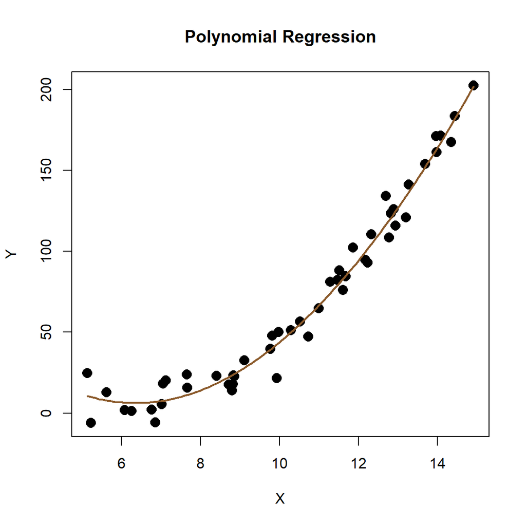

```r
# Create a sequence of 'x' values for smooth curve plotting
x_seq <- seq(min(x), max(x), length.out = 100)

# Predict 'y' values using the fitted model
y_pred <- predict(fit, newdata = data.frame(x = x_seq))



# Plot the original data points
plot(x, y, pch = 16, cex = 1.5, xlab = "X", ylab = "Y", main = "Polynomial Regression")

# Add the polynomial regression curve
lines(x_seq, y_pred, col = "tan4", lwd = 2)
```

### **Interaction Effects**

The main goal to study interaction effects is that it allows us to:

- Identify relationships between predictor variables.
- Improve model accuracy by capturing dependencies between variables.
- Interpret regression coefficients more precisely in cases where effects are conditional.
- Visualize effects more clearly using interaction plots that show how relationships change with different predictor levels.

#### **Qualitative Predictors**

When using categorical variables in regression, they must be converted into indicator (dummy) variables.

For example, let’s consider the following dataset, where we want to relate the speed with which particular insurance innovation is adopted (Y, in months), to the size of insurance firms $(X_1)$, and the type of firm.

```r
#import data
Example_1 <- read.csv("Example1.csv")
head(Example_1)
```

```
##    Y  X1 X2 Firm.Type
## 1 17 151  0    Mutual
## 2 26  92  0    Mutual
## 3 21 175  0    Mutual
## 4 30  31  0    Mutual
## 5 22 104  0    Mutual
## 6  0 277  0    Mutual
```

If $X_2$ represents firm type (Mutual or Stock), we define:

$$\begin{align*}
X_2 =
\begin{cases}
1, & \text{if Stock company} \\
0, & \text{if Mutual company} \\
\end{cases}
\end{align*}$$

The regression model becomes:

$$\begin{align*}
E(Y) = \beta_0 + \beta_1 X_1 + \beta_2 X_2
\end{align*}$$

where $\beta_2$ represents the difference in Y between Stock and Mutual firms. Let’s create a dummy variable (ignore $X_2$ that is already created in the dataset):

```r
#creating a dummy variable
Example_1$X.Stock = I(Example_1$Firm.Type == "Stock")*1
Example_1$X.Stock
```

```
##  [1] 0 0 0 0 0 0 0 0 0 0 1 1 1 1 1 1 1 1 1 1
```

```r
Example_1$X.Mutual = I(Example_1$Firm.Type == "Mutual")*1
Example_1$X.Mutual
```

```
##  [1] 1 1 1 1 1 1 1 1 1 1 0 0 0 0 0 0 0 0 0 0
```

```r
head(Example_1)
```

```
##    Y  X1 X2 Firm.Type X.Stock X.Mutual
## 1 17 151  0    Mutual       0        1
## 2 26  92  0    Mutual       0        1
## 3 21 175  0    Mutual       0        1
## 4 30  31  0    Mutual       0        1
## 5 22 104  0    Mutual       0        1
## 6  0 277  0    Mutual       0        1
```

We can also create dummy variables using library:

```r
library('fastDummies')
Example_1.Dat<-dummy_cols(Example_1, select_columns = 'Firm.Type')
Example_1.Dat[1:6,]
```

```
##    Y  X1 X2 Firm.Type X.Stock X.Mutual Firm.Type_Mutual Firm.Type_Stock
## 1 17 151  0    Mutual       0        1                1               0
## 2 26  92  0    Mutual       0        1                1               0
## 3 21 175  0    Mutual       0        1                1               0
## 4 30  31  0    Mutual       0        1                1               0
## 5 22 104  0    Mutual       0        1                1               0
## 6  0 277  0    Mutual       0        1                1               0
```

Now let’s plot the regression functions for different firm types:

```r
# Load necessary libraries
library(ggplot2)

# Fit the regression model
model <- lm(Y ~ X1 + X.Stock, data = Example_1)
summary(model)
```

```
##
## Call:
## lm(formula = Y ~ X1 + X.Stock, data = Example_1)
##
## Residuals:
##     Min      1Q  Median      3Q     Max
## -5.6915 -1.7036 -0.4385  1.9210  6.3406
##
## Coefficients:
##              Estimate Std. Error t value Pr(>|t|)
## (Intercept) 33.874069   1.813858  18.675 9.15e-13 ***
## X1          -0.101742   0.008891 -11.443 2.07e-09 ***
## X.Stock      8.055469   1.459106   5.521 3.74e-05 ***
## ---
## Signif. codes:  0 '***' 0.001 '**' 0.01 '*' 0.05 '.' 0.1 ' ' 1
##
## Residual standard error: 3.221 on 17 degrees of freedom
## Multiple R-squared:  0.8951, Adjusted R-squared:  0.8827
## F-statistic:  72.5 on 2 and 17 DF,  p-value: 4.765e-09
```

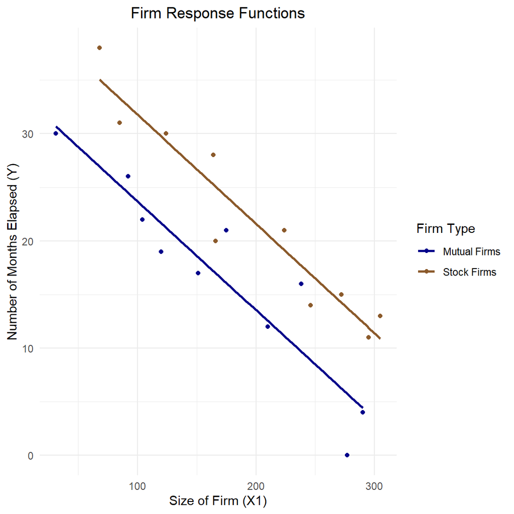

```r
# Predict values for plotting
Example_1$Predicted_Y <- predict(model, newdata = Example_1)

# Create the plot
ggplot(Example_1, aes(x = X1, y = Y, color = as.factor(X.Stock))) +
  geom_point() +  # Scatter plot
  geom_smooth(method = "lm", se = FALSE) +  # Regression lines
  labs(title = "Firm Response Functions",
       x = "Size of Firm (X1)",
       y = "Number of Months Elapsed (Y)",
       color = "Firm Type") +
  scale_color_manual(values = c("darkblue", "tan4"),
                     labels = c("Mutual Firms", "Stock Firms")) +
  theme_minimal()+
  theme(plot.title = element_text(hjust = 0.5))
```

```r
# Extract coefficients
coefficients <- coef(model)
intercept_mutual <- coefficients[1]  # β0
slope_x1 <- coefficients[2]  # β1
intercept_stock <- coefficients[1] + coefficients[3]  # β0 + β2

# Print the equations
cat("Regression Equation for Mutual Firms:\n")
```

```
## Regression Equation for Mutual Firms:
```

```r
cat(paste0("Y = ", round(slope_x1, 2), " * X1 + ", round(intercept_mutual, 2), "\n\n"))
```

```
## Y = -0.1 * X1 + 33.87
```

```r
cat("Regression Equation for Stock Firms:\n")
```

```
## Regression Equation for Stock Firms:
```

```r
cat(paste0("Y = ", round(slope_x1, 2), " * X1 + ", round(intercept_stock, 2), "\n"))
```

```
## Y = -0.1 * X1 + 41.93
```

#### **Interaction Between Quantitative and Qualitative Predictors**

When a qualitative variable interacts with a quantitative one, we include a cross-product term:

$$\begin{align*}
E(Y) = \beta_0 + \beta_1 X_1 + \beta_2 X_2 + \beta_3 X_1X_2
\end{align*}$$

where: - $\beta_3$ measures how the effect of $X_1$ changes depending on the category of $X_2$.

Let’s model this for the insurance innovation example.

```r
# Fit the regression model
model2 <- lm(Y ~ X1 + X.Stock + X1:X.Stock, data = Example_1)
summary(model2)
```

```
##
## Call:
## lm(formula = Y ~ X1 + X.Stock + X1:X.Stock, data = Example_1)
##
## Residuals:
##     Min      1Q  Median      3Q     Max
## -5.7144 -1.7064 -0.4557  1.9311  6.3259
##
## Coefficients:
##               Estimate Std. Error t value Pr(>|t|)
## (Intercept) 33.8383695  2.4406498  13.864 2.47e-10 ***
## X1          -0.1015306  0.0130525  -7.779 7.97e-07 ***
## X.Stock      8.1312501  3.6540517   2.225   0.0408 *
## X1:X.Stock  -0.0004171  0.0183312  -0.023   0.9821
## ---
## Signif. codes:  0 '***' 0.001 '**' 0.01 '*' 0.05 '.' 0.1 ' ' 1
##
## Residual standard error: 3.32 on 16 degrees of freedom
## Multiple R-squared:  0.8951, Adjusted R-squared:  0.8754
## F-statistic: 45.49 on 3 and 16 DF,  p-value: 4.675e-08
```

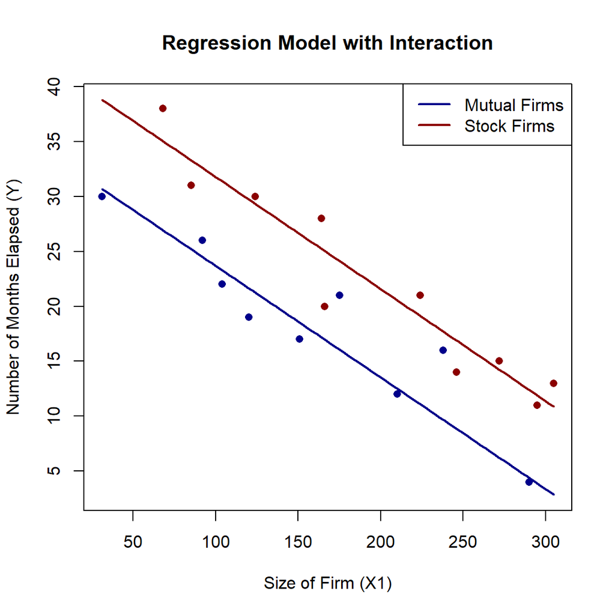

```r
# Define X1 range for predictions
X1_seq <- seq(min(Example_1$X1), max(Example_1$X1), length.out = 100)

# Compute predicted values for Mutual Firms (X.Stock = 0)
pred_mutual <- data.frame(X1 = X1_seq, X.Stock = 0)
pred_mutual$Y_hat <- predict(model2, newdata = pred_mutual)

# Compute predicted values for Stock Firms (X.Stock = 1)
pred_stock <- data.frame(X1 = X1_seq, X.Stock = 1)
pred_stock$Y_hat <- predict(model2, newdata = pred_stock)

# Plot the data points
plot(Example_1$X1, Example_1$Y, col = ifelse(Example_1$X.Stock == 0, "darkblue", "darkred"),
     pch = 16, xlab = "Size of Firm (X1)", ylab = "Number of Months Elapsed (Y)",
     main = "Regression Model with Interaction", ylim = range(c(pred_mutual$Y_hat, pred_stock$Y_hat)))

# Add regression lines
lines(pred_mutual$X1, pred_mutual$Y_hat, col = "darkblue", lwd = 2)  # Mutual Firms line
lines(pred_stock$X1, pred_stock$Y_hat, col = "darkred", lwd = 2)  # Stock Firms line

# Add legend
legend("topright", legend = c("Mutual Firms", "Stock Firms"), col = c("darkblue", "darkred"), lwd = 2)
```

The model allowed different slopes, but the data suggests that the slopes are actually similar, making the interaction term useless. That’s why the regression lines appear parallel. Since p-value is large (>0.05), we conclude that there is no interaction between size of firm and firm type.

## Model Selection

### Overview

The four phases of the data collection and model-building process in regression analysis are essential for ensuring that the final model is robust, interpretable, and capable of making reliable predictions.

The first phase is data collection and preparation, where the nature of the study dictates the data requirements. This stage includes different types of studies, such as controlled experiments, confirmatory observational studies, and exploratory observational studies. Controlled experiments allow researchers to manipulate explanatory variables, while observational studies rely on naturally occurring data. A crucial part of this phase is ensuring that the collected data is accurate, properly formatted, and free from errors that could bias the model.

The second phase is the reduction of explanatory or predictor variables, which is particularly relevant in exploratory observational studies. Here, researchers refine the list of potential predictor variables by removing those that are redundant, highly correlated, or not fundamental to the analysis. This step helps to avoid issues like multicollinearity and overfitting, ensuring that the model remains interpretable and does not include unnecessary complexity.

Next, the model refinement and selection phase involves evaluating different model specifications to determine the best combination of predictor variables. At this stage, statistical diagnostics, interaction effects, and transformations of variables are considered to improve model fit. This phase often involves iterative testing and the use of selection criteria such as Akaike’s Information Criterion (AIC) or adjusted R-squared to compare models.

The final phase is model validation, which ensures that the selected regression model generalizes well to new data. This can be done using techniques like cross-validation, splitting data into training and testing sets, or comparing model predictions against theoretical expectations. Validation is crucial to prevent overfitting and to ensure that the model maintains predictive accuracy when applied to different datasets.

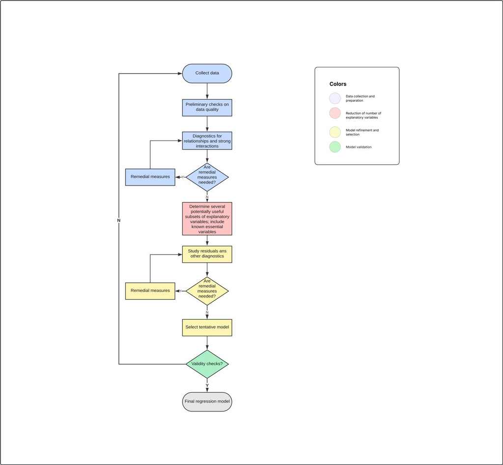

### Criteria for model selection

From any set of $p-1$ predictors, there are $2^{p-1}$ alternative models that can be constructed. This calculation is based on the fact that each predictor can either be included or excluded from the model.

A detailed examination can be made of the promising or candidates models , leading to the selection of the final regression model to be employed. While there are many criteria for comparising the regression models that have been developed, we will focus on six: $R_p^2$, $R_{a,p}^2$, $C_p$, $AIC_p$,$SBC_p$ and $PRESS_p$.

#### $R_p^2$

The criterion $R_p^2$ is equivalent to using the error sum of squares $SSE_p$ as the criterion.

$$\begin{align*}
R^2_{adj} = 1 - \left( \frac{SSE}{SST} \right)
\end{align*}$$

Here, higher values of $R_p^2$ is preferred.

#### $R_{a,p}^2$

$R_{a,p}^2$ accounts for model complexity by penalizing the inclusion of non-informative predictors. The criterion is equivalent to using the error sum of squares $SSE_p$ as the criterion.

$$\begin{align*}
R_{a,p}^2 = 1 - \left( \frac{SSE / (n - p)}{SST / (n - 1)} \right)
\end{align*}$$

where:

- SSE = Sum of Squared Errors
- SST = Total Sum of Squares
- n = Number of observations
- p = Number of predictors including the intercept

Here, higher values of $R_p^2$ is preferred.

#### $C_p$

Mallows’$C_p$ criterion balances goodness of fit and model complexity. It compares the total error of a given model to that of the full model.

$$\begin{align*}
C_p = \frac{SSE_p}{\hat{\sigma}^2} - (n - 2p)
\end{align*}$$

where:

- $\hat{\sigma}^2$ = Estimated error variance
- $SSE_p$ = Error sum of squares for the model with p predictors

when the C values for all possible regression models are plotted against p, those models with little bias will tend to fall near the line $C_p = p$. Models with substantial bias tend to fall above this line. So models with $C_p$ tending to p are preferred.

#### $AIC_p$

Akaike’s information criterion (AIC) is an information-theoretic criterion that penalizes overly complex models while rewarding goodness of fit.

The classical AIC formula (used in GLMs, including regression):

$$\begin{align*}
AIC = 2k - 2log(L)
\end{align*}$$
where k is the number of estimated parameters, and L the maximum likelihood of the model. The SSE-based version (for linear regression ) is:

$$\begin{align*}
AIC_p = n \ln(SSE_p) - n \ln(n) + 2p
\end{align*}$$
where SSE is the sum of squared errors with p predictors m and n is the sample size.

For both cases, Lower AIC values are preferred.

#### $SBC_p$

Schwarz’ Bayesian criterion (SBC) is an information-theoretic criterion that penalizes overly complex models while rewarding goodness of fit.

$$\begin{align*}
SBC_p = n \ln(SSE_p) - n \ln(n) + ln(n)p
\end{align*}$$

Lower SBC values are preferred. Notice that the key difference between AIC and SBC is the last term. For $n \ge 8$, the last term $ ln(n)p$ will be greater than $2p$, so SBC tends to penalizes more complex models.

#### $PRESS_p$

The $PRESS_p$ (prediction sum of squares) criterion is a measure of how well the use of the fitted values for a subset model can predict the observed responses $Y_i$. So PRESS evaluates the model’s generalizability by predicting each data point after omitting it.

$$\begin{align*}
PRESS = \sum_{i=1}^{n} (y_i - \hat{y}_{i(i)})^2
\end{align*}$$

Lower PRESS values indicate better predictive performance.

### Automatic search

#### Best Subsets Algorithms

Select the subset of predictors that do the best at meeting some well-defined objective criterion, such as having the largest $R^2$ value or the smallest MSE, Mallow’s Cp or AIC.

```r
library(olsrr)

# Fit full model
model <- lm(mpg ~ disp + hp + wt + qsec, data = mtcars)

# One way is to see all possible subsets
allsubsets <- ols_step_all_possible(exp)

# Or perform best subset selection
best_subset <- ols_step_best_subset(model)

# Print results
print(best_subset)

# Plot selection results
plot(best_subset)
```

#### Forward Stepwise Regression

Forward stepwise regression is an automatic feature selection method used in linear regression, and probably the most widely used of the automatic search methods. It starts with no predictors and sequentially adds variables that improve the model’s performance the most, each step adding or deleting an X variable. Then it evaluate each predictor independently and select the one with the lowest p-value or highest improvement in adjusted $R^2$. After adding the predictor, the process is repeated, and stops when no additional variable significantly improves the model.

This method is useful when dealing with many potential predictors but aiming for a parsimonious model (simpler, with only relevant variables).

```r
library(olsrr)

# Fit initial model (only intercept)
model <- lm(mpg ~ 1, data = mtcars)

# Perform forward stepwise selection
forward_model <- ols_step_forward_p(model)

# View selected model summary
summary(forward_model)

# Plot the selection process
plot(forward_model)
```

#### Backward Regression

Build regression model from a set of candidate predictor variables by removing predictors based on p values, in a stepwise manner until there is no variable left to remove any more. The model should include all the candidate predictor variables. If details is set to TRUE, each step is displayed.

```r
library(olsrr)

# Fit full model with all predictors
model <- lm(mpg ~ disp + hp + wt + qsec, data = mtcars)

# Perform backward stepwise regression
backward_model <- ols_step_backward_p(model)

# Print selected model
summary(backward_model)

# Plot the selection process
plot(backward_model)
```

#### Stepwise Regression

Build regression model from a set of candidate predictor variables by entering and removing predictors based on p values, in a stepwise manner until there is no variable left to enter or remove any more. The model should include all the candidate predictor variables. If details is set to TRUE, each step is displayed.

Stepwise regression is a hybrid approach that combines forward selection and backward elimination. Instead of only adding or only removing predictors, it adds variables step by step (like forward selection) but also removes them if they become insignificant (like backward selection).

```r
library(olsrr)

# Fit full model
model <- lm(mpg ~ disp + hp + wt + qsec, data = mtcars)

# Perform stepwise selection (both directions)
stepwise_model <- ols_step_both_p(model)

# Print selected model summary
summary(stepwise_model)

# Plot selection process
plot(stepwise_model)
```

## Remedial Measures

Remedial measures in regression analysis are corrective actions taken when your model violates key assumptions of linear regression. They help fix or adjust the model so that it better satisfies the assumptions and gives reliable results. Usually is used when:

- The regression model is not appropriate (e.g., assumptions are violated);
- There are influential observations skewing results;
- The error terms (residuals) have problems like: unequal variances (heteroscedasticity), Non-normality, Multicollinearity between predictors;

We have many ways to adjust a regression in this scenarios. The most usual measures are:

- Weighted Least Squares (WLS): Used when error variances are not constant. Assigns less weight to observations with higher variance;
- Transformations (e.g., log, square root): Applied to the response or predictors to stabilize variance or linearize relationships;
- Ridge and Lasso Regression: Tackles multicollinearity by adding a penalty term, reducing the variance of the coefficient estimates (though they become biased);
- Robust Regression: Reduces the influence of outliers without deleting them;
- Lowess and Regression Trees: Non-parametric approaches used when linear models aren’t a good fit.
- Bootstrapping: Used for estimating the precision (e.g., confidence intervals) of estimates, especially when assumptions about the distribution of errors are in doubt.
- Iteratively reweighted least squares Regression (IRLS): IRLS is a method used to handle outliers and non-constant variance by assigning weights to observations, then iteratively updating those weights based on the residuals until the model stabilizes.

### WLS

In multiple linear regression, one key assumption is that the variance of the errors is constant across all levels of the predictors (homoscedasticity). When this is violated, the model suffers from heteroscedasticity, which can make the standard errors and inference unreliable. Weighted Least Squares is a remedial measure used when the variance of the error terms is not constant. In WLS, we assign a weight to each observation, giving more weight to observations with lower error variance, and less weight to noisier points.

Suppose our usual multiple regression model is:

$$\begin{align*}
Y_i = \beta_0 + \beta_1 X_{i1} + \dots + \beta_p X_{ip} + \varepsilon_i,
\quad i = 1, \dots, n
\end{align*}$$

With WLS, we assume:

$$\begin{align*}
\text{Var}(\varepsilon_i) = \sigma_i^2
\end{align*}$$

And we assign weights:

$$\begin{align*}
w_i = \frac{1}{\sigma_i^2}
\end{align*}$$

Then, we solve for the coefficients that minimize the weighted sum of squared residuals:

$$\begin{align*}
\sum_{i=1}^n w_i (Y_i - \hat{Y}_i)^2
\end{align*}$$

Sometimes the true variances $\sigma_i^2$ are unknown. In that case, we can:

1. Fit an OLS model and extract residuals $e_i$.
2. Regress $|e_i|$ or $e_i^2$ on one or more predictors.
3. Use the fitted values from that model to estimate $\hat{\sigma}_i^2$, and set:

$$\begin{align*}
w_i = \frac{1}{\hat{\sigma}_i^2}
\end{align*}$$

This process may be repeated a few times (called iteratively reweighted least squares) to stabilize the estimates.

```r
# Step 1: Fit initial OLS model
ols <- lm(Y ~ X1 + X2, data = your_data)
res <- residuals(ols)

# Step 2: Regress absolute residuals on predictor(s) to estimate variance function
abs_res <- abs(res)
var_model <- lm(abs_res ~ X1, data = your_data)

# Step 3: Estimate weights
fitted_sd <- fitted(var_model)
weights <- 1 / (fitted_sd^2)

# Step 4: Fit WLS model
wls <- lm(Y ~ X1 + X2, data = your_data, weights = weights)

summary(wls)
```

### Ridge

Ridge Regression is a regularized version of linear regression. It addresses the problem of multicollinearity and overfitting by shrinking the regression coefficients toward zero.

The objective in OLS is to minimize the residual sum of squares:

$$\begin{align*}
\min_{\boldsymbol{\beta}} \sum_{i=1}^n (y_i - \mathbf{x}_i^\top
\boldsymbol{\beta})^2
\end{align*}$$

Ridge modifies the OLS by adding a penalty on the size of the coefficients:

$$\begin{align*}
\min_{\boldsymbol{\beta}} \left\{ \sum_{i=1}^n (y_i - \mathbf{x}_i^\top
\boldsymbol{\beta})^2 + \lambda \sum_{j=1}^p \beta_j^2 \right\}
\end{align*}$$

The Ridge Regression estimator has a closed-form solution:

$$\begin{align*}
\hat{\boldsymbol{\beta}}^{ridge} = \left( \mathbf{X}^\top \mathbf{X} +
\lambda \mathbf{I} \right)^{-1} \mathbf{X}^\top \mathbf{y}
\end{align*}$$

If your variables are on different scales (e.g., revenue in millions vs. temperature in Celsius), the penalty would disproportionately shrink coefficients based on scale, not on importance. Therefore, it’s import to:

- Center y (subtract mean): ensures the intercept is not regularized.
- Standardize X (subtract mean and divide by standard deviation).

To choose $\lambda$ , we Use cross-validation (e.g., cv.glmnet() in R) to find the optimal $\lambda$ that minimizes prediction error.

```r
library(glmnet)

# Define Predictors and Result matrix
x_train <- model.matrix(y ~ . , data = ex1_data_train)[, -1]
y_train <- ex1_data_train$y


# Adjust the ridge model
ridge_model <- glmnet(x_train, y_train, alpha = 0)




# Visualize the coefficients
plot(ridge_model, xvar = "lambda")

#OR

# Extract the coefficients
coefs <- as.matrix(ridge_model$beta)

# Grafic
matplot(log(ridge_model$lambda), t(coefs), type = "l", lty = 1,
        xlab = "Log(Lambda)", ylab = "Coefficients",
        main = "Ridge Coefficients Path")

# Legend with predictors
legend("bottomright", legend = rownames(coefs), col = 1:nrow(coefs), lty = 1, cex = 0.5)
#"topright" or "bottomright" or "topleft" , where there is more space
# adjust cex = 0.6, 0.7, according to the dedsired size.



#Cross validation
set.seed(1023)
cv_ridge <- cv.glmnet(x_train, y_train, alpha = 0)
plot(cv_ridge)

coef(cv_ridge, s = "lambda.min")


#This last line can be done as well with:

# Best lambda
best_lambda_ridge <- cv_ridge$lambda.min

# Adjust model
ridge_final <- glmnet(x_train, y_train, alpha = 0, lambda = best_lambda_ridge)

# Coefficients of the final model
coef(ridge_final)
```

### Lasso

Lasso (Least Absolute Shrinkage and Selection Operator) is a linear regression method that uses L1 regularization to penalize the absolute values of the regression coefficients.

$$\begin{align*}
\text{Loss} = \sum_{i=1}^{n} (y_i - \hat{y}_i)^2 + \lambda
\sum_{j=1}^{p} |\beta_j|
\end{align*}$$
Where:

- $y_i$ is the actual response
- $\hat{y}_i$ is the predicted response
- $\beta_j$ are the model coefficients
- $\lambda$ is the regularization parameter
- $n$ is the number of observations
- $p$ is the number of predictors

As $\lambda$ increases, the penalty grows, and more coefficients are driven to exactly zero.Lasso and Ridge are two different types of regularization techniques used in linear regression. They’re closely related but not variants of each other — they just belong to the same family of methods: penalized regression.

```r
library(glmnet)

# Adjust the Lasso model
lasso_model <- glmnet(x_train, y_train, alpha = 1)

# Visualize the coefficients
plot(lasso_model, xvar = "lambda", main = "Lasso Coefficient Paths")
#Use xvar = "lambda" if you want that the coefficients changes as soon as the penalization changes
#Use xvar = "norm" if you want to see the model complexity growing

# Cross-validation to find best lambda
set.seed(1023)
cv_lasso <- cv.glmnet(x_train, y_train, alpha = 1)
plot(cv_lasso)

# Coefficients with best lambda
coef(cv_lasso, s = "lambda.min")
```

### Elastic Net

Elastic Net is a regularized regression technique that combines both Ridge Regression (L2 penalty) and Lasso Regression (L1 penalty). It is particularly useful when:

- There are many correlated predictors
- You want both shrinkage (from Ridge) and variable selection (from Lasso)

Elastic Net addresses limitations of Ridge (which keeps all variables) and Lasso (which can be unstable when variables are highly correlated).

The objective function minimized by Elastic Net is:

$$\begin{align*}
\text{Loss} = \sum_{i=1}^{n} (y_i - \hat{y}_i)^2 + \lambda \left[ \alpha
\sum_{j=1}^{p} |\beta_j| + (1 - \alpha) \sum_{j=1}^{p} \beta_j^2 \right]
\end{align*}$$

Where:

- $y_i$: actual response
- $\hat{y}_i$: predicted response
- $\beta_j$: model coefficients
- $\lambda$: regularization strength (penalty term)
- $\alpha$: mixing parameter
- $\alpha = 1$: pure Lasso
- $\alpha = 0$: pure Ridge
- $0 < \alpha < 1$: Elastic Net

In this model, we typically set $\alpha = 0.5$ to balance both penalties equally.

Elastic Net is particularly useful when dealing with high-dimensional data or datasets with correlated predictors, as it tends to perform better than either Ridge or Lasso alone in such settings.

```r
library(glmnet)

# Fit Elastic Net model
elastic_model <- glmnet(x_train, y_train, alpha = 0.5)

# Plot coefficient paths
plot(elastic_model, xvar = "lambda", main = "Elastic Net Coefficient Paths")

# Cross-validation to find best lambda
set.seed(1023)
cv_elastic <- cv.glmnet(x_train, y_train, alpha = 0.5)
plot(cv_elastic)

# Coefficients for best lambda
coef(cv_elastic, s = "lambda.min")
```

### Robust

Robust Regression is a technique designed to limit the influence of outliers on the model. Unlike ordinary least squares (OLS), which minimizes the sum of squared residuals, robust regression uses alternative loss functions that reduce the effect of extreme residuals (outliers).

The most common approach is M-estimation, which replaces the squared loss with a function $\rho(\cdot)$ that grows slower than the square function:

$$\begin{align*}
\min_{\beta} \sum_{i=1}^{n} \rho\left( y_i - \mathbf{x}_i^\top \beta
\right)
\end{align*}$$

Where:

- $\rho$ is a loss function (e.g., Huber function)
- $y_i$ is the actual response
- $\mathbf{x}_i^\top \beta$ is the predicted response
- $\beta$ are the coefficients being estimated

One popular choice for $\rho$ is the Huber function, which behaves like squared loss for small residuals and like absolute loss for large ones. This makes it robust to outliers.

```r
library(MASS)

# Fit robust regression on training data
robust_model <- rlm(siri ~ ., data = ex1_data_train)

# Summary of the model
summary(robust_model)
```

In robust regression the summary results don’t show the significance, since rlm() is based on M-estimation, and its estimation procedure does not rely on the same distributional assumptions (e.g., normality of residuals) as OLS.

You can approximate them using the t-values. A t-value > 1.96 (in absolute value) is often considered potentially significant in practice (just like in lm()). If your sample size is moderately large (say, n>30), the t-distribution starts to resemble the normal distribution.For a two-sided test at significance level, the critical value of the t-distribution is approximately:

# Other regressions

## Logistic

Logistic or binary regression is a statistical method used for modeling a binary outcome, where the response variable can take on only two possible values, typically coded as 0 and 1. In R, logistic regression can be fitted using the glm() function from base R, specifying family = binomial to indicate a binomial distribution and logit link function. Instead of modeling the response variable directly, logistic regression models the log-odds of the probability that the response equals 1, as a linear function of the predictors. The fitted model estimates the coefficients that best explain the relationship between the predictors and the log-odds of the binary outcome.

### Overview

The equation below is the general form of a logistic regression model with any number of predictors:

$$\begin{align*}
\log\left(\frac{p}{1 - p}\right) = \beta_0 + \beta_1 x_1 + \beta_2 x_2 +
\cdots + \beta_k x_k
\end{align*}$$

Here, p represents the probability that the response variable equals 1 (e.g., a tumor is malignant), and $x_1,x_2,...,x_k$ are the predictor variables. The coefficients $\beta_1,\beta_2,...,\beta_k$ are estimated from the training dataset.

In R, to fit the logistic regression model:

```r
# Fit a logistic regression model (binary regression)
model <- glm(Class ~ ., data = train_data, family = binomial)
```

### Diagnostics

Residual deviance is a measure of how well your model fits the data. It plays a similar role to the residual sum of squares (RSS) in linear regression, but is based on likelihoods rather than squared errors.

$$\begin{align*}
Deviance = -2 (log(L_{model})- log(L_{saturated}))
\end{align*}$$

where $L_{model}$ is the likelihood of the fitted model, and $L_{saturated}$ is the likelihood of a model that fits the data perfectly. Smaller deviance = better fit. Null deviance is the deviance from a model with only the intercept (no predictors), and Residual deviance is the deviance from the full model (all predictors).

We can compare the fitted model to the null model (which has no predictors) by considering the difference between the residual and null deviance. Hence, the p-value for the test of the hypothesis that at least one of the predictors is related to the response is:

- H_0: variables are not important
- H_a: variables are important

```r
diff_deviance = x
diff_df = y

1-pchisq(diff_deviance,diff_df)
```

If the result is small, we are confident that there is some relationship between the predictors and the response. So we can accept $H_a$.

### ROC and AUC

AUC (Area Under the Curve) refers to the area under the ROC (Receiver Operating Characteristic) curve, which plots True Positive Rate (Sensitivity) vs. False Positive Rate (1 – Specificity).It reflects the model’s ability to rank a randomly chosen positive instance higher than a randomly chosen negative one.

```r
library(pROC)
roc_obj <- roc(Titanic.ModelData_test$survived, test_probs)
plot(roc_obj, main = "ROC Curve - Logistic Regression", col = "#2E86C1")
auc(roc_obj)
```

Interpretation:

- 0.90 – 1.00 Excellent (rare and often ideal)
- 0.80 – 0.90 Very good
- 0.70 – 0.80 Good / Acceptable
- 0.60 – 0.70 Poor (but better than random guessing)
- 0.50 – 0.60 Fail / Useless / Essentially guessing
- 0.50 Random guess (no discriminative power)
- < 0.50 Worse than random (model is reversed!)

## Time Series

### Overview

Autocorrelation refers to the correlation of a variable with its own past values, and is a common phenomenon in time series data. More precisely, in the context of regression, autocorrelation often describes a situation where the residuals (error terms) are not independent but instead follow a pattern over time.

Autocorrelation is not unusual in real-world datasets. It frequently occurs in economics, finance, environmental studies, and any domain where observations are collected sequentially over time. For example:

- In a model predicting monthly sales, an underprediction in one month is often followed by another underprediction in the next.
- In meteorology, today’s temperature is often highly correlated with yesterday’s.

Autocorrelation does not bias the estimated coefficients of an ordinary least squares (OLS) regression. However, it invalidates many inferential statistics by underestimating standard errors, leading to:

- Overconfident t-tests (Type I errors)
- Misleading p-values
- Incorrect confidence intervals

### Diagnostics

Detecting autocorrelation is a key step when dealing with time series or any regression model with temporally ordered data. The goal is to identify whether residuals from a model are correlated over time — a violation of the classical OLS assumption of independent errors.

The first approach is graphical. Plot the residuals versus time:

```r
plot(residuals ~ time, type = "b", pch = 19,
     xlab = "Time", ylab = "Residuals",
     main = "Residuals vs Time")
abline(h = 0, col = "red", lty = 2)
```

What to look for:

- A wave-like pattern indicates positive autocorrelation.
- Alternating residuals suggest negative autocorrelation.
- Ideally, residuals should fluctuate randomly around zero.

#### **Durbin- Watson Test**

The Durbin-Watson (DW) statistic formally tests for first-order autocorrelation in the error terms. It is defined as:

$$\begin{align*}
D &= \frac{\sum_{t=2}^{n} (e_t - e_{t-1})^2}{\sum_{t=1}^{n} e_t^2}
\end{align*}$$

Where:

- $e_t$ is the residual at time t
- n is the smaple size

Range of values:

- $D \approx 2$: no autocorrelation
- $D < 2$: positive autocorrelation
- $D > 2$: negative autocorrelation

Hypotheses (one-sided, for positive autocorrelation):

- $H_0$: ${\rho}$ = 0 (no autocorrelation)
- $H_a$: ${\rho}$ > 0 (positive autocorrelation)

${\rho}$ is the correlation between consecutive errors in your model. If it’s significantly different from 0, it means your model’s residuals are not independent, and your standard OLS assumptions are violated.

```r
library(lmtest)
dwtest(model, alternative = "greater")

#if Positive autocorrelation, alternative = "greater" (default, residuals follow wave-like pattern). If negative autocorrelation, alternative = "less" (When residuals alternate sharply). When you're not sure of the direction, alternative = "two.sided" (Any autocorrelation (positive or negative)).
If alternative = "greater", we are saying "Please calculate the p-value for the hypothesis that ρ>0"
```

#### **Ljung–Box Q Test**

This test evaluates whether a set of autocorrelations (not just lag-1) are significantly different from zero. The test statistic is:

$$\begin{align*}
Q &= n(n + 2) \sum_{k=1}^{h} \frac{\hat{\rho}_k^2}{n - k}
\end{align*}$$

Where:

- n is the sample size
- h is the number of lags
- $\hat{\rho}_k$ is the sample autocorrelation at lag k

Hypotheses:

- $H_0: {\rho}_1={\rho}_2=...={\rho}_h=0$
- $H_a$: at least one ${\rho}_k \neq 0$

```r
Box.test(residuals(model), lag = 1, type = "Ljung-Box")
```

### Dynamic models

#### AR

Autoregressive models assumes that the error at time t depends on previous errors. For AR(1), we have that:

$$\begin{align*}
\varepsilon_t = \rho \varepsilon_{t-1} + u_t
\end{align*}$$

Substituting into the regression model:

$$\begin{align*}
Y_t &= \beta_0 + \beta_1 X_t + \varepsilon_t \\
\varepsilon_t &= \rho \varepsilon_{t-1} + u_t
\end{align*}$$

For stationarity, we require:

$$\begin{align*}
|\rho| < 1
\end{align*}$$

A general AR(p) model expresses the current value as a linear function of its own past values:

$$\begin{align*}
Y_t = \phi_1 Y_{t-1} + \phi_2 Y_{t-2} + \dots + \phi_p Y_{t-p} + u_t
\end{align*}$$

#### MA

A Moving Average (MA) model relates $Y_t$ to past shocks:

$$\begin{align*}
Y_t = \mu + u_t + \theta_1 u_{t-1} + \theta_2 u_{t-2} + \dots + \theta_q
u_{t-q}
\end{align*}$$

#### ARMA

Autoregressive Moving Average Model combines both AR and MA structures:

$$\begin{align*}
Y_t = \phi_1 Y_{t-1} + \dots + \phi_p Y_{t-p} + u_t + \theta_1 u_{t-1} +
\dots + \theta_q u_{t-q}
\end{align*}$$

#### ARIMA

When the series is non-stationary, differencing is applied to make it stationary before fitting an ARMA model. The result is an ARIMA(p, d, q) model:

$$\begin{align*}
\Delta^d Y_t = \phi_1 \Delta^d Y_{t-1} + \dots + \phi_p \Delta^d Y_{t-p}
+ u_t + \theta_1 u_{t-1} + \dots + \theta_q u_{t-q}
\end{align*}$$

Where the differencing operator is defined as:

$$\begin{align*}
\Delta Y_t = Y_t - Y_{t-1}
\end{align*}$$

And $\Delta^d Y_t$ is the result of applying the differencing operator d times.

#### ARDL

In many time series regressions, both the dependent and independent variables can exhibit autocorrelation or dynamic behavior. One flexible framework to model this is the **Autoregressive Distributed Lag (ARDL)** model, which incorporates lags of both the dependent and independent variables.

An ARDL(p, q) model with one independent variable takes the form:

$$\begin{align*}
Y_t = \alpha_0 + \sum_{i=1}^{p} \alpha_i Y_{t-i} + \sum_{j=0}^{q}
\beta_j X_{t-j} + \varepsilon_t
\end{align*}$$

Where: - $p$ is the number of lags of the dependent variable $Y$ - $q$ is the number of lags of the independent variable $X$ - $\varepsilon_t \sim N(0, \sigma^2)$

- ARDL models can **separate short-term and long-term effects**
- Useful when series are **stationary or integrated of order 1 (I(1))**
- ARDL allows for **lag structure estimation** without requiring variables to be strictly stationary

The **short-run dynamics** are captured by the lagged differences of $Y$ and $X$.  
The **long-run relationship** is derived by solving the steady-state form:

If the model is stable and $Y$ and $X$ are cointegrated, then:

$$\begin{align*}
Y_t = \frac{\alpha_0 + \sum_{j=0}^{q} \beta_j X_{t-j}}{1 -
\sum_{i=1}^{p} \alpha_i}
\end{align*}$$

### Remedial measures

When autocorrelation is detected in the residuals of a regression model, especially in time series data, the classical OLS assumptions are violated. While OLS remains unbiased, it becomes inefficient and standard errors are underestimated, leading to misleading inference.

One cause of autocorrelation may be the omission of important explanatory variables. If the error term is capturing a systematic effect, adding the missing variable to the model may resolve the issue.

Instead of modeling with original variables, we can transform them to remove autocorrelation, as in the **Cochrane-Orcutt**, **Hildreth-Lu**, and **First Difference** procedures.

#### **Cochrane–Orcutt Procedure**

This iterative method estimates $\rho$ and transforms the model to eliminate autocorrelated residuals.

Step 1: Estimate $\rho$

From residuals $e_t$, compute:

$$\begin{align*}
e_t = \rho e_{t-1} + u_t
\end{align*}$$

Estimate $\rho$ by regressing $e_t$ on $e_{t-1}$ through the origin.

Step 2: Transform the Variables

Use the estimated $\hat{\rho}$ to transform the data:

$$\begin{align*}
Y_t^* &= Y_t - \hat{\rho} Y_{t-1} \\
X_t^* &= X_t - \hat{\rho} X_{t-1}
\end{align*}$$

Then run regression on transformed data:

$$\begin{align*}
Y_t^* = \beta_0 (1 - \hat{\rho}) + \beta_1 X_t^* + u_t
\end{align*}$$

Step 3: Iterate

Repeat until the Durbin-Watson statistic indicates no remaining autocorrelation.

#### **Hildreth–Lu Procedure**

A grid search over possible values of $\rho$ is performed to find the value that minimizes the sum of squared errors (SSE) for the transformed model.

Unlike Cochrane-Orcutt, it does not rely on initial OLS estimation of $\rho$, making it more robust in some cases.

$$\begin{align*}
SSE = \sum (Y_t^* - \hat{Y}_t^*)^2 = \sum (Y_t^* - b_0' - b_1'
X_t^*)^2
\end{align*}$$

#### **First Difference Method**

Assumes strong autocorrelation, possibly $\rho = 1$. We apply the first-difference transformation:

$$\begin{align*}
Y_t - Y_{t-1} = \beta_1 (X_t - X_{t-1}) + (u_t - u_{t-1})
\end{align*}$$

Or simply:

$$\begin{align*}
\Delta Y_t = \beta_1 \Delta X_t + \varepsilon_t
\end{align*}$$

This method is quick and effective when **unit root behavior** is suspected.A unit root refers to a characteristic of a time series that suggests the series is non-stationary—specifically, that it has a random walk behavior. This type of behavior implies that the series is highly persistent, and its values tend to follow a trend over time, rather than fluctuating around a constant mean.

## Poisson

Poisson regression is used when the response variable represents count data — that is, non-negative integer values like 0, 1, 2, and so on.

The main goal of Poisson regression is to model the expected number of events occurring in a fixed period of time, area, or other unit, based on predictor variables.

It assumes that the response variable $Y$ follows a Poisson distribution, where the mean and variance are equal:

$$\begin{align*}
E(Y_i) = Var(Y_i) = \lambda_i
\end{align*}$$

The Poisson regression model relates the expected value $\lambda_i$ to the predictors using a log-link function:

$$\begin{align*}
\log(\lambda_i) = \beta_0 + \beta_1 X_{1i} + \beta_2 X_{2i} + \cdots +
\beta_p X_{pi}
\end{align*}$$

where: - $\lambda_i$ is the expected count for observation $i$, - $X_{1i}, X_{2i}, \dots, X_{pi}$ are the predictor variables, - $\beta_0, \beta_1, \dots, \beta_p$ are the regression coefficients.

The model predicts the expected number of events by exponentiating the linear predictor:

$$\begin{align*}
\lambda_i = \exp(\beta_0 + \beta_1 X_{1i} + \beta_2 X_{2i} + \cdots +
\beta_p X_{pi})
\end{align*}$$

### **Purpose**

- Model count data appropriately when traditional linear regression assumptions (normality, constant variance) are violated.
- Predict how the rate or number of events changes based on explanatory variables.
- Understand the effect of each predictor on the expected count by interpreting $\exp(\beta)$ as a multiplicative effect.

### **Key Assumptions**

- The observations are independent.
- The mean and variance of the response variable are equal.
- The log of the expected value of the response variable is a linear function of the predictors.

### **Example**

```r
data_poisson <- read.csv("20250425_poisson_example.csv")
model_poisson <- glm(Emission_Events ~ ., family=poisson, data_poisson)
summary(model_poisson)
```

```
##
## Call:
## glm(formula = Emission_Events ~ ., family = poisson, data = data_poisson)
##
## Coefficients:
##                   Estimate Std. Error z value Pr(>|z|)
## (Intercept)     -0.9026306  0.4153321  -2.173  0.02976 *
## Days_Worked      0.0168746  0.0126483   1.334  0.18216
## Production       0.0012594  0.0004544   2.771  0.00558 **
## Number_Auditory -0.0555455  0.0194431  -2.857  0.00428 **
## ---
## Signif. codes:  0 '***' 0.001 '**' 0.01 '*' 0.05 '.' 0.1 ' ' 1
##
## (Dispersion parameter for poisson family taken to be 1)
##
##     Null deviance: 141.83  on 119  degrees of freedom
## Residual deviance: 124.95  on 116  degrees of freedom
## AIC: 252.17
##
## Number of Fisher Scoring iterations: 5
```

```r
#The Poisson regression model reveals that Production and Number of Auditories are statistically significant predictors of emission events. Specifically, an increase in production is associated with a higher expected number of emissions, while a higher number of audits significantly reduces emissions. Although Days Worked has a positive coefficient, it is not statistically significant at the 5% level. The model’s deviance dropped from 141.83 to 124.95, suggesting a modest improvement in fit when including all predictors.

#The null deviance measures how well a model with only the intercept (i.e., no predictors) fits the data.


anova(model_poisson,test="Chi")
```

```
## Analysis of Deviance Table
##
## Model: poisson, link: log
##
## Response: Emission_Events
##
## Terms added sequentially (first to last)
##
##
##                 Df Deviance Resid. Df Resid. Dev Pr(>Chi)
## NULL                              119     141.83
## Days_Worked      1   0.5464       118     141.28 0.459777
## Production       1   8.0573       117     133.22 0.004532 **
## Number_Auditory  1   8.2709       116     124.95 0.004028 **
## ---
## Signif. codes:  0 '***' 0.001 '**' 0.01 '*' 0.05 '.' 0.1 ' ' 1
```

```r
#This runs an Analysis of Deviance Table (similar to ANOVA for linear models), using the Chi-squared test to evaluate the contribution of each predictor in your Poisson regression model.

#The null model (with only the intercept) starts with a deviance of 141.83. Adding Days_Worked reduces the deviance only slightly (Δ = 0.5464), and the p-value is 0.4598. Not statistically significant — this variable does not significantly improve the model.

#Adding Production next reduces the deviance by 8.0573, with a p-value of 0.0045 →Statistically significant (p < 0.01) — this predictor adds meaningful explanatory power.

#Finally, Number_Auditory reduces the deviance further by 8.2709, also highly significant (p = 0.0040) → Strong evidence that this variable helps explain variation in emission events.

#It uses the chi square test, also called likelihood ratio test to evaluate the significance of each predictor in a GLM (like Poisson).It compares: A reduced model (without the predictor), Versus the full model (with the predictor), and tests whether the reduction in deviance is large enough to be statistically significant.

drop1(model_poisson,test="Chi")
```

```
## Single term deletions
##
## Model:
## Emission_Events ~ Days_Worked + Production + Number_Auditory
##                 Df Deviance    AIC    LRT Pr(>Chi)
## <none>               124.95 252.16
## Days_Worked      1   126.72 251.94 1.7717 0.183171
## Production       1   132.82 258.03 7.8658 0.005038 **
## Number_Auditory  1   133.22 258.44 8.2709 0.004028 **
## ---
## Signif. codes:  0 '***' 0.001 '**' 0.01 '*' 0.05 '.' 0.1 ' ' 1
```

```r
# It tests the importance of each predictor individually. For each variable, it drops it from the full model and tests if the model becomes significantly worse (using a Chi-squared test). It tries to answers the question: "If I remove this predictor, will the model's fit get significantly worse?".

#In this example, Removing Production or Number_Auditory makes the model significantly worse — both have p < 0.01, so they are important.Removing Days_Worked barely changes the deviance, and has p = 0.18 → not statistically significant.

#mean(data_poisson$Emission_Events)
#var(data_poisson$Emission_Events)
```

## Negative Binomial

Negative Binomial Regression is used for modeling count data when the variance of the response variable exceeds the mean — a situation called overdispersion. It extends the Poisson regression by introducing an additional parameter to model the variance separately from the mean.

### **Purpose**

- Handle overdispersed count data where Poisson regression would otherwise underestimate the standard errors.
- Improve model fit and inference when the variability in the data is larger than the Poisson assumption allows.

### **Model Equation**

Negative Binomial regression still models the expected count $\lambda_i$ with a log-link function:

$$\begin{align*}
\log(\lambda_i) = \beta_0 + \beta_1 X_{1i} + \beta_2 X_{2i} + \cdots +
\beta_p X_{pi}
\end{align*}$$

However, the variance is now given by:

$$\begin{align*}
Var(Y_i) = \lambda_i + \alpha \lambda_i^2
\end{align*}$$

where: - $\lambda_i$ is the expected count, - $\alpha$ is the dispersion parameter (estimated from the data).

If $\alpha = 0$, the model reduces to a regular Poisson model.

### **Interpretation**

- The coefficients are interpreted similarly to Poisson regression:  
  $\exp(\beta_k)$ represents the multiplicative change in the expected count for a one-unit increase in predictor $X_k$.
- A positive coefficient increases the expected number of events, and a negative coefficient decreases it.

### **Key Differences from Poisson Regression**

| Aspect | Poisson Regression | Negative Binomial Regression |
| --- | --- | --- |
| Variance assumption | $Var(Y) = E(Y)$ | $Var(Y) > E(Y)$ |
| Dispersion parameter | None | Estimated from data ($\alpha$) |
| Best for | Counts with equal variance and mean | Counts with overdispersion |

### **Example**

```r
library(MASS)  #for negative.binomial()
data_nb <- read.csv("20250425_negative_binomial_example.csv")

model_nb <- glm(regulatory_violations ~ .,negative.binomial(1),data_nb)
summary(model_nb)
```

```
##
## Call:
## glm(formula = regulatory_violations ~ ., family = negative.binomial(1),
##     data = data_nb)
##
## Coefficients:
##                            Estimate Std. Error t value Pr(>|t|)
## (Intercept)                1.425666   0.431201   3.306  0.00119 **
## independent_board_members -0.106380   0.051896  -2.050  0.04217 *
## transparency_perc         -0.030295   0.005528  -5.480 1.82e-07 ***
## external_audits           -0.295498   0.131671  -2.244  0.02632 *
## ---
## Signif. codes:  0 '***' 0.001 '**' 0.01 '*' 0.05 '.' 0.1 ' ' 1
##
## (Dispersion parameter for Negative Binomial(1) family taken to be 0.7335337)
##
##     Null deviance: 116.158  on 149  degrees of freedom
## Residual deviance:  84.614  on 146  degrees of freedom
## AIC: 225.21
##
## Number of Fisher Scoring iterations: 6
```

```r
anova(model_nb,test="Chi")
```

```
## Analysis of Deviance Table
##
## Model: Negative Binomial(1), link: log
##
## Response: regulatory_violations
##
## Terms added sequentially (first to last)
##
##
##                           Df Deviance Resid. Df Resid. Dev  Pr(>Chi)
## NULL                                        149    116.158
## independent_board_members  1   3.0083       148    113.150   0.04285 *
## transparency_perc          1  24.8430       147     88.307 5.899e-09 ***
## external_audits            1   3.6928       146     84.614   0.02485 *
## ---
## Signif. codes:  0 '***' 0.001 '**' 0.01 '*' 0.05 '.' 0.1 ' ' 1
```

```r
drop1(model_nb,test="Chi")
```

```
## Single term deletions
##
## Model:
## regulatory_violations ~ independent_board_members + transparency_perc +
##     external_audits
##                           Df Deviance    AIC scaled dev. Pr(>Chi)
## <none>                         84.614 225.21
## independent_board_members  1   88.080 227.94       4.725  0.02973 *
## transparency_perc          1  110.399 258.36      35.151 3.05e-09 ***
## external_audits            1   88.307 228.25       5.034  0.02485 *
## ---
## Signif. codes:  0 '***' 0.001 '**' 0.01 '*' 0.05 '.' 0.1 ' ' 1
```

```r
# Create a prediction dataframe comparing observed and fitted values
pred.dat <- data.frame(
  Y = data_nb$regulatory_violations,
  Yhat_NB = model_nb$fitted.values
)

# Residual Sum of Squares for the Negative Binomial model
sum((pred.dat$Y - pred.dat$Yhat_NB)^2)
```

```
## [1] 68.91383
```

```r
#The negative binomial regression model reveals that all three predictors—independent board members, transparency percentage, and external audits—are statistically significant in explaining the number of regulatory violations. Higher levels of transparency (p<0.001) and a greater number of external audits (p=0.026) are both associated with a significant reduction in violations, suggesting strong governance mechanisms reduce risk. Additionally, the number of independent board members is also a significant factor (p=0.043), albeit with a smaller effect size. The model significantly reduces deviance from 116.16 (null model) to 84.61, and the residual sum of squares is 68.91, indicating a good fit given the overdispersed count nature of the data.
```

# Machine Learning

Machine Learning (ML) is a branch of artificial intelligence that focuses on developing algorithms that can learn from data and make predictions or decisions without being explicitly programmed. By leveraging statistical and computational techniques, ML models identify patterns, generalize from past observations, and improve their performance over time.

These models can be broadly categorized into supervised learning, where the algorithm learns from labeled data, unsupervised learning, which identifies hidden structures in unlabeled data, and reinforcement learning, where agents learn through trial and error by maximizing rewards. Machine learning is widely applied in various fields, including finance, healthcare, environmental science, and automation, making it a crucial tool for data-driven decision-making.

## Overview

Machine Learning (ML) is a field of Artificial Intelligence (AI) that enables systems to learn patterns from data and make predictions. It is generally categorized into:

- **Supervised Learning**: Models learn from labeled data.
- **Unsupervised Learning**: Models extract patterns from unlabeled data.
- **Reinforcement Learning**: Models learn through rewards and penalties.

## Supervised Learning

Supervised learning is a machine learning approach in which a model is trained on a labeled dataset, meaning each training example includes both the input features and the corresponding output (target). The goal is to learn a function that maps inputs to outputs so that the model can make accurate predictions on new, unseen data. Common Types of Supervised Learning Models are:

- Decision Trees: Rule-based models that split the data into branches based on feature values, leading to interpretable, flowchart-like decision rules.
- Regression Trees: A variant of decision trees used when the target variable is continuous. They recursively split the feature space and predict the average of the target variable in each region.
- Random Forest (RF): An ensemble method that builds multiple decision trees on random subsets of the data and averages their predictions, reducing variance and overfitting.
- Support Vector Machines (SVM): Models that find the optimal hyperplane that best separates the data into classes, often using kernel functions to capture non-linear boundaries.
- Neural Networks (NN): Layered networks of interconnected nodes that learn complex patterns through weights and activations, particularly powerful for large-scale and high-dimensional data.

### Trees

#### **Decision Trees**

A decision tree splits data into branches based on feature values, making predictions based on the final leaves. Decision trees are supervised learning models that recursively split the data using feature values. Trees structure have root nodes (entire dataset), decision nodes (where split happen), and leaves (final outputs).

Impurity is a measure of how mixed or “impure” the data is within a node of a decision tree. In the context of classification, it quantifies how heterogeneous the class labels are — that is, how many different classes are present in that node.

- A pure node contains only data points from a single class (impurity = 0).
- A highly impure node contains a mixture of multiple classes.

We have mainly three ways to evaluate impurity: Gini Index, Entropy, and Classification Error.

The **Gini Index** measures the probability that a randomly chosen element from the node would be incorrectly classified if it were randomly labeled according to the distribution of labels in the node. Mathematically, it minimizes the impurity measure I:

$$\begin{align*}
I = 1 - \sum_{i=1}^{k} p_i^2
\end{align*}$$
where $p_i$ is the proportion of class i in a node.

Interpretation:

- 0: the node is pure (only one class).
- Close to 0.5 or higher → the node is impure (mixed classes).
- Commonly used in the CART algorithm.

```r
rpart(Y ~ ., data = ex1_data_train, method = "class")
```

**Entropy** comes from information theory and measures the amount of disorder or uncertainty in a node. Mathematically, we have:

$$\begin{align*}
I = -\sum_{i=1}^{k} p_i \log_2(p_i)
\end{align*}$$

Entropy is measured in bits. If there are only two possible classes, entropy values can range from 0 to 1. For n classes, entropy ranges from 0 to log2(n).

- 0:pure node (only one class).
- Maximum when all classes are equally likely.

**Classification error** simply reflects the fraction of misclassified samples if the majority class were used for prediction. Mathematically, we have:

$$\begin{align*}
I = 1 - \max(p_i)
\end{align*}$$

Interpretation:

- 0: all samples in the node belong to the same class.
- Higher values indicate more class mixing.
- Less sensitive than Gini and Entropy, often used for pruning rather than splitting.

**Information Gain (IG)** is a metric used in decision trees to choose the best feature to split on at each step of the tree construction.

It measures the reduction in impurity (such as entropy or Gini index) after a dataset is split based on a given feature. The idea is simple: a good split is one that reduces uncertainty the most.

$$\begin{align*}
\text{Gain}(A) = I(D) - \sum_{j=1}^{n} \frac{|D_j|}{|D|} I(D_j)
\end{align*}$$

Where:

- $\text{Gain}(A)$ is the information gain from splitting on attribute $A$
- $I(D)$ is the impurity (e.g., entropy or Gini) of the full dataset $D$
- $D_j$ are the resulting subsets from the split
- $\frac{|D_j|}{|D|}$ is the proportion of samples in subset $D_j$
- $I(D_j)$ is the impurity of subset $D_j$

Interpretation:

- A **higher information gain** means the feature leads to purer child nodes, making it a better split.
- A **gain of 0** means the feature does not reduce impurity at all.

**Pruning** is the process of **reducing the size of a decision tree** by removing sections (subtrees or branches) that provide little or no predictive power. The goal of pruning is to improve the tree’s **generalization performance** on unseen data by reducing **overfitting**.

When a decision tree grows deep, it may start to fit the noise in the training data. Pruning simplifies the model by cutting off unnecessary complexity.

1. **Pre-pruning** (Early Stopping)

Pre-pruning involves **stopping the tree from growing** once a certain condition is met during construction. Common criteria include:

- Maximum tree depth
- Minimum number of samples required to split
- Minimum impurity decrease
- Minimum number of observations in a node

The tree is never allowed to grow past those limits.

2. **Post-pruning** (Cost-Complexity Pruning)

Post-pruning means the full tree is built first, and then **subtrees are pruned back** based on validation performance or a cost function. A popular technique is **cost-complexity pruning**, which penalizes tree complexity.

A typical pruning objective is:

$$\begin{align*}
C_\alpha(T) = R(T) + \alpha \cdot |T|
\end{align*}$$

Where:

- $C_\alpha(T)$ is the **cost-complexity** of the tree
- $R(T)$ is the total error (e.g., misclassification rate or RSS)
- $|T|$ is the number of terminal nodes (leaves) in the tree
- $\alpha$ is a hyperparameter that controls the trade-off between complexity and accuracy

Higher $\alpha$ leads to more aggressive pruning.

**Benefits of Pruning**

- Reduces overfitting
- Simplifies the model for better interpretability
- Often improves test accuracy
- Helps avoid reliance on noisy splits

#### **Regression Trees**

Regression trees extend decision trees to predict numeric outcomes instead of classes. They split the data using recursive binary partitioning, just like classification trees, but use numerical criteria such as variance reduction or minimizing RSS (residual sum of squares) instead of entropy or Gini.

The predictor space is divided into non-overlapping regions (e.g., $R_1,R_2,...,R_j$). Each region predicts a constant value: the mean response of the training samples in that region. Regions are typically rectangular, created through axis-aligned splits.

Split Criterion: Choose the split that most reduces variance (or minimizes the RSS):

$$\begin{align*}
RSS = \sum_{j=1}^{J} \sum_{i \in R_j} (y_i - \bar{y}_{R_j})^2
\end{align*}$$

Pros:

- Handles nonlinear relationships well
- No need to specify a functional form
- Automatically selects relevant features

Cons:

- Less interpretable than linear models for large trees
- Requires more training data
- Hard to assess the individual effect of features

```r
rpart(Y ~ ., data = ex1_data_train, method = "anova")  # or omit method, as this is default
```

### Bagging

It’s an ensemble learning method that builds many models and averages their predictions to make a more stable and accurate final prediction. Decision trees are great, but they’re unstable (high variance): Small changes in the data → different tree, different prediction. Bagging fixes this by Creating many different versions of the training data (bootstrap samples), Training a tree on each version, Averaging their outputs.

How it works: 1.Bootstrap Sampling:

- Take B samples from the training data with replacement.
- Each sample has the same size as the original dataset but may repeat rows.

2.Model Training:

- Train one model (e.g., tree) on each bootstrap sample.
- Each model is a bit different because it sees different data.

3.Aggregation:

- Regression → average the predictions across all trees.
- Classification → take a majority vote across all trees.

Therefore, the advantages of Bagging are: average of many trees (low variance), more stable and generalizable, robust to noise and outliers.

```r
library(MASS)           # for Boston dataset
library(randomForest)   # for bagging and random forest
library(gbm)            # for boosting
data("Boston")
set.seed(42)

# Train/Test Split
train_idx <- sample(1:nrow(Boston), nrow(Boston) * 0.7)
train_data <- Boston[train_idx, ]
test_data  <- Boston[-train_idx, ]


# Bagging = Random Forest with all features tried at each split
# here for mtry = ncol(Boston) - 1, it's saying "Use all 13 predictors (ignore medv) when splitting.”
# Default for random forest is p/3 = 4 for 13 predictors.
# Smaller mtry equals more randomness and more diversity between trees and better enbsemble generalization.
# Larger mtry equals trees become more similar, less diversity and possibly overfitting.
bag_model <- randomForest(medv ~ ., data = train_data, mtry = ncol(Boston) - 1, importance = TRUE)

# Predict and evaluate
bag_preds <- predict(bag_model, newdata = test_data)
bag_mse <- mean((bag_preds - test_data$medv)^2)

print(paste("Bagging Test MSE:", round(bag_mse, 2)))
```

```
## [1] "Bagging Test MSE: 12.88"
```

```r
print(bag_model)
```

```
##
## Call:
##  randomForest(formula = medv ~ ., data = train_data, mtry = ncol(Boston) -      1, importance = TRUE)
##                Type of random forest: regression
##                      Number of trees: 500
## No. of variables tried at each split: 13
##
##           Mean of squared residuals: 13.50798
##                     % Var explained: 83.63
```

### RF

Random Forests are an ensemble method that builds many decorrelated decision trees and aggregates their predictions. They are an extension of bagging, with an added layer of randomness.Introduced to make bagging trees less correlated and improve accuracy.At each split in each tree, instead of using all features, select a random subset (mtry) of features.

- For classification: default mtry is $\sqrt{p}$.
- For regression: default mtry is $p/3$.

$$\begin{align*}
\hat{f}(x) = \frac{1}{B} \sum_{b=1}^{B} f_b(x)
\end{align*}$$
where:

$f_b(x)$ is the prediction of the b-th tree B is the total number of trees.

Strengths:

- Works well on many tasks
- Handles high-dimensional data and missing values
- Automatically ranks feature importance
- Less prone to overfitting than single trees

Weaknesses:

- Less interpretable than single trees
- More computationally intensive

```r
library(MASS)           # for Boston dataset
library(randomForest)   # for bagging and random forest
library(gbm)            # for boosting


data("Boston")
set.seed(42)

# Train/Test Split
train_idx <- sample(1:nrow(Boston), nrow(Boston) * 0.7)
train_data <- Boston[train_idx, ]
test_data  <- Boston[-train_idx, ]


rf_model <- randomForest(medv ~ ., data = train_data, importance = TRUE)

rf_preds <- predict(rf_model, newdata = test_data)
rf_mse <- mean((rf_preds - test_data$medv)^2)

print(paste("Random Forest Test MSE:", round(rf_mse, 2)))
```

```
## [1] "Random Forest Test MSE: 11.92"
```

```r
print(rf_model)
```

```
##
## Call:
##  randomForest(formula = medv ~ ., data = train_data, importance = TRUE)
##                Type of random forest: regression
##                      Number of trees: 500
## No. of variables tried at each split: 4
##
##           Mean of squared residuals: 11.48935
##                     % Var explained: 86.07
```

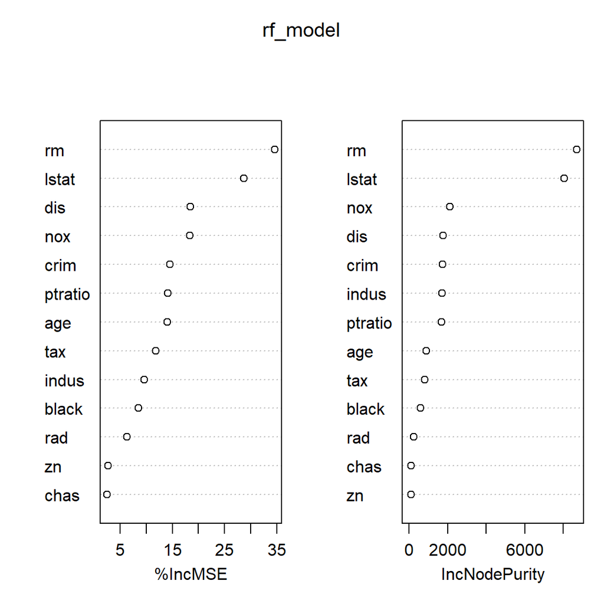

```r
# Variable Importance Plot
varImpPlot(rf_model)
```

In this example, the random forest model was trained to predict median housing values (medv) using the Boston dataset, with 500 trees and mtry = 4, meaning four randomly chosen predictors were considered at each split. The model achieved a Test MSE of 11.92, indicating that on average, its predictions deviate by about √11.92 ≈ 3.45 units from the actual values. The mean squared residuals on the training set was 11.49, with a high explained variance of 86.07%, suggesting the model captures a strong portion of the underlying data structure. According to the variable importance plots, the most influential predictors were rm (average number of rooms) and lstat (lower socioeconomic status), contributing the most to prediction accuracy based on both %IncMSE(Measures how much worse the model performs when a variable is randomly permuted) and IncNodePurity(Measures how much a variable reduces impurity when used in splits across the forest). This confirms domain expectations, as wealth and housing size are typically strong indicators of home value.

### Boosting

Boosting builds trees sequentially, where each new tree focuses on the errors of the previous one.Unlike bagging (parallel, independent trees), boosting is adaptive.

How it works:

1.Start with initial predictions (e.g., mean for regression). 2.Fit a small tree (usually shallow) to the residuals or misclassified points. 3.Add that tree to the model with a weight. 4.Repeat for many iterations (each tree improves on the previous ensemble).

```r
library(MASS)           # for Boston dataset
library(randomForest)   # for bagging and random forest
library(gbm)            # for boosting


data("Boston")
set.seed(42)

# Train/Test Split
train_idx <- sample(1:nrow(Boston), nrow(Boston) * 0.7)
train_data <- Boston[train_idx, ]
test_data  <- Boston[-train_idx, ]

# Boosting with 500 trees and shrinkage (learning rate) = 0.01
boost_model <- gbm(medv ~ ., data = train_data,
                   distribution = "gaussian",
                   n.trees = 500, interaction.depth = 4,
                   shrinkage = 0.01, cv.folds = 5, verbose = FALSE)

# Predict and evaluate
boost_preds <- predict(boost_model, newdata = test_data, n.trees = 500)
boost_mse <- mean((boost_preds - test_data$medv)^2)

print(paste("Boosting Test MSE:", round(boost_mse, 2)))
```

```
## [1] "Boosting Test MSE: 12.2"
```

```r
print(boost_model)
```

```
## gbm(formula = medv ~ ., distribution = "gaussian", data = train_data,
##     n.trees = 500, interaction.depth = 4, shrinkage = 0.01, cv.folds = 5,
##     verbose = FALSE)
## A gradient boosted model with gaussian loss function.
## 500 iterations were performed.
## The best cross-validation iteration was 498.
## There were 13 predictors of which 13 had non-zero influence.
```

In this example, the gradient boosting model was trained on the Boston housing dataset to predict median house value (medv) using all 13 predictors. The model used 500 trees, a shrinkage (learning rate) of 0.01, and an interaction depth of 4, meaning each tree could capture up to 4-way interactions between variables. Cross-validation with 5 folds was used to select the optimal number of iterations.

The best number of boosting rounds was 498, showing that nearly all 500 iterations contributed to improving performance. The model achieved a Test MSE of 12.2, meaning that on average, predictions deviate from actual values by about √12.2 ≈ 3.5 units. This is quite close to the performance of your random forest model.

All 13 predictors were used in the model and had non-zero influence, suggesting that each variable contributed meaningfully to the boosted ensemble. Compared to bagging and random forest, boosting often provides more refined predictions by focusing on previous errors, though it can be more sensitive to tuning parameters and noise.

### SVM

Support Vector Machines (SVM) finds the optimal hyperplane that separates different classes by maximizing the margin:

$$\begin{align*}
\max ||w||^2 \quad \text{subject to} \quad y_i (w \cdot x_i + b) \geq 1
\end{align*}$$

where w is the weight vector and b is the bias.

In R:

```r
library(e1071)
svm_model <- svm(y ~ ., data = dataset, kernel = "radial")
```

### NN

Neural networks (NNs) are a family of machine learning models inspired by the structure of the human brain. Each model consists of layers of interconnected nodes, called neurons, that process information through weighted connections. Neural networks are capable of modeling complex relationships for both classification and numeric prediction tasks. They are particularly useful when the underlying relationship between input variables and the output variable is nonlinear or hard to describe analytically.

Neural networks fall under the broader categories of artificial intelligence (AI) and machine learning (ML). In contrast to traditional statistical models, they require minimal assumptions about the underlying data distribution.

The concept of the artificial neuron has evolved significantly since its inception in 1943. Initially, the McCulloch-Pitts neuron was introduced as a simple binary threshold unit that could only process Boolean inputs and outputs, with no capacity for learning. In 1957, Rosenblatt advanced this model with the perceptron, allowing real-valued inputs and introducing adjustable weights, making it capable of learning linearly separable patterns. However, it still lacked the ability to solve more complex problems like XOR. The modern neuron, developed around 1986, introduced key enhancements such as non-linear activation functions, bias terms, and the use of gradient descent for learning via backpropagation. These advancements laid the foundation for deep neural networks, enabling them to model complex, non-linear relationships and powering modern AI applications in fields like image recognition, natural language processing, and medical diagnostics.

A single artificial neuron can be described mathematically as follows. Given input features $x_1, x_2, \ldots, x_n$ and associated weights $w_1, w_2, \ldots, w_n$, the net input $z$ to the neuron is:

$$z = \sum_{i=1}^{n} w_i x_i + b$$

where $b$ is the bias term.

In statistical learning, bias refers to the systematic error introduced by approximating a real-world problem (which may be complex) with a simpler model.

While error is the total difference between the predicted value and the true value, bias is only one component of this error.

We can break down the total expected prediction error (mean squared error) into three components:

$$\begin{align}
\text{E}[(\hat{y} - y)^2] = \underbrace{(\mathbb{E}[\hat{y}] -
y)^2}_{\text{Bias}^2} + \underbrace{\mathbb{E}[(\hat{y} -
\mathbb{E}[\hat{y}])^2]}_{\text{Variance}} +
\underbrace{\sigma^2}_{\text{Irreducible noise}}
\end{align}$$

Where: - $\hat{y}$ is the model’s prediction - $y$ is the true value - $\mathbb{E}[\hat{y}]$ is the expected prediction over different training sets - $\sigma^2$ is the irreducible error (from randomness or unobserved variables)

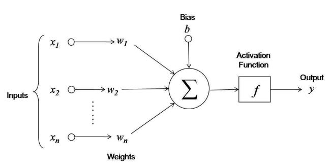

The output $y$ of the neuron is the result of applying an activation function $f(\cdot)$ to $z$:

$$y = f(z)$$

Common activation functions include the sigmoid function, hyperbolic tangent (tanh), and rectified linear unit (ReLU).

#### **Activation functions**

In artificial neural networks, the **activation function** defines how the weighted sum of the inputs to a neuron is transformed into its output. The choice of activation function has a significant impact on the network’s learning dynamics, convergence, and ability to model complex relationships.

Below are some common activation functions and their properties:

- **Identity**
  $$f(z) = z$$
  A linear function. When used in all neurons, the entire network becomes equivalent to a linear regression, regardless of the number of layers — it cannot model nonlinear patterns.
- **Binary Step**
  $$f(z) = \begin{cases}
  0 & \text{if } z < 0 \\
  1 & \text{if } z \geq 0
  \end{cases}$$
  A threshold function. Useful for binary classification, but not differentiable, which makes it unsuitable for gradient-based learning (e.g., backpropagation).
- **Sigmoid (Logistic)**
  $$f(z) = \frac{1}{1 + e^{-z}}$$
  Outputs values between 0 and 1. Good for probability-based interpretation, especially in output layers. However, it suffers from the vanishing gradient problem — gradients become very small for extreme input values, which slows learning in deep networks.
- **Hyperbolic Tangent (Tanh)**
  $$f(z) = \tanh(z) = \frac{e^z - e^{-z}}{e^z + e^{-z}}$$
  Similar to sigmoid, but outputs between -1 and 1, centering the data. Helps with optimization compared to sigmoid, but still affected by vanishing gradients for large input magnitudes.
- **ArcTan**
  $$f(z) = \tan^{-1}(z)$$
  Smooth and continuous like Tanh, but less commonly used. Outputs values in the range $(-π/2, π/2)$, also subject to gradient saturation.
- **Softsign / Softstep**
  $$f(z) = \frac{z}{1 + |z|}$$
  A smoother version of the Tanh function. It transitions gently between values and avoids sharp saturation, but is rarely used in practice.
- **Inverse Square Root Unit (ISRU)**
  $$f(z) = \frac{z}{\sqrt{1 + a z^2}}$$
  Controlled by a parameter $a$. Helps regulate large input values while maintaining smooth gradients. It’s a more recent and less standard activation.
- **ReLU (Rectified Linear Unit)**
  $$f(z) = \max(0, z)$$
  The most commonly used activation in modern deep networks. Efficient, simple, and avoids vanishing gradients in the positive domain. However, neurons can “die” (output always 0) if gradients fall to zero for all inputs — this is known as the dying ReLU problem.

**Summary Table**:

| Function | Output Range | Nonlinear | Differentiable | Notes |
| --- | --- | --- | --- | --- |
| Identity | $(-∞, ∞)$ | No | Yes | Linear model |
| Binary Step | $\{0, 1\}$ | Yes | No | No gradient |
| Sigmoid | $(0, 1)$ | Yes | Yes | Vanishing gradient |
| Tanh | $(-1, 1)$ | Yes | Yes | Centered sigmoid |
| ArcTan | $(-π/2, π/2)$ | Yes | Yes | Smooth, uncommon |
| Softsign | $(-1, 1)$ | Yes | Yes | Gentle transition |
| ISRU | $(-1, 1)$ | Yes | Yes | Requires tuning |
| ReLU | $[0, ∞)$ | Yes | (except at 0) | Fast, simple |

Choosing the right activation function depends on the task, model architecture, and optimization behavior. Most modern networks use **ReLU** in hidden layers and **Sigmoid** or **Softmax** in the output layer (for binary or multi-class classification, respectively).

```r
library(nnet)
nn_model <- nnet(y ~ ., data = dataset, size = 5, maxit = 500)
```

Using neuralnet, the sigmoid function is the default.

#### **Topology**

The topology of a neural network refers to its structure — specifically, how neurons are organized into layers and how those layers are connected. A typical neural network is composed of three types of layers: the input layer, one or more hidden layers, and the output layer.

The input layer receives the raw data. Each neuron in this layer represents a feature (or variable) from the dataset. For example, if your model uses temperature, humidity, and rainfall as predictors, the input layer will have three neurons.

The output layer produces the final prediction. Its structure depends on the type of task:

- For regression, it usually contains one neuron with a linear or identity activation function.
- For binary classification, it typically has one neuron with a sigmoid activation.
- For multi-class classification, it has as many neurons as classes, often with softmax activation.

Between these two is the hidden layer — or often, several hidden layers. This is where the network “learns” internal representations of the data by transforming the inputs through weighted connections and activation functions. A hidden layer is called “hidden” because its values are not directly observed; they are intermediate computations. The composition of multiple hidden layers allows the network to learn increasingly abstract and complex patterns.

Choosing the right number of hidden layers and neurons per layer is not trivial and depends on the complexity of the problem:

- Shallow networks (with 1 hidden layer) can already approximate any continuous function, according to the Universal Approximation Theorem.
- Deeper networks (with multiple hidden layers) are better at capturing hierarchical or highly nonlinear relationships, especially in problems involving images, language, or audio.
- Too few neurons or layers may lead to underfitting (the model is too simple to capture patterns).
- Too many may cause overfitting (the model learns noise and performs poorly on new data).

| # of Hidden Layers | Recommendation |
| --- | --- |
| 0 | Equivalent to logistic or linear regression |
| 1 (shallow NN) | Can approximate any continuous function (Universal Approximation Theorem) |
| 2–3 | Ideal for many structured/tabular data problems |
| > 3 (deep) | Needed for highly complex tasks (images, text, voice) |

**Rule of thumb**: Start with 1 or 2 layers and increase only if needed.

There is no one-size-fits-all formula to determine the ideal network topology. It’s often found through experimentation, cross-validation, and hyperparameter tuning. Some practical heuristics include:

- Starting with 1–2 hidden layers for structured/tabular data.
- Setting the number of neurons per layer between the size of the input and output layers, or using values like 4, 8, 16, depending on dataset size.
- Monitoring training error and generalization performance (e.g., validation RMSE or accuracy) to guide adjustments.

It’s important to state that there are several different types of architectures of neural network:

| Network Type | Description | Application |
| --- | --- | --- |
| Feedforward (MLP) | Information flows only forward | Tabular data |
| CNN (Convolutional Neural Network) | Uses filters to capture spatial patterns | Images, videos |
| RNN (Recurrent Neural Network) | Has cycles/loops to handle sequential data | Text, time series |
| LSTM / GRU | Improved versions of RNNs | Natural language, long-term memory |
| Autoencoders | Compress and reconstruct data | Dimensionality reduction |
| GANs (Generative Adversarial Networks) | Two networks competing with each other | Image generation, deepfakes |
| Transformers | Use attention instead of recurrence | Translation, language, modern vision tasks |

#### **Training using backpropagation and gradient descent**

Training a neural network involves adjusting the weights $w_i$ and biases $b$ to minimize a cost function, typically the mean squared error (MSE) for regression tasks:

$$\text{MSE} = \frac{1}{n} \sum_{i=1}^n (y_i - \hat{y}_i)^2$$

Backpropagation is the process of calculating the gradient of the loss function with respect to each weight by the chain rule. The gradient tells us the direction to adjust each weight to decrease the error.

Gradient descent updates the weights according to:

$$w_i \leftarrow w_i - \alpha \frac{\partial J}{\partial w_i}$$

where $\alpha$ is the learning rate and $J$ is the cost function.

Choosing an appropriate learning rate is critical. If the learning rate is too small, training will be slow; if too large, the training process may become unstable.

#### **Strengths and weaknesses**

Neural networks are extremely flexible and capable of approximating almost any function given enough neurons and data. However, they have weaknesses as well. They are computationally intensive, sensitive to hyperparameter settings, prone to overfitting, and result in models that are often difficult to interpret (“black box” models).

For these reasons, careful cross-validation and regularization techniques are often needed when applying neural networks in practice.

#### **Example**

```r
# Step 1: Load libraries
#install.packages("neuralnet")
library(neuralnet)
# Step 2: Load and explore data
energy_data <- read.csv("20250426_NN_example.csv")
str(energy_data)
```

```
## 'data.frame':    200 obs. of  4 variables:
##  $ temperature       : num  13.4 32.2 33.3 21.1 19.7 ...
##  $ rainfall          : num  70.3 91.9 48.2 24 96 ...
##  $ humidity          : num  51.2 46.5 86.2 79.8 57.5 ...
##  $ energy_consumption: num  239 281 339 312 249 ...
```

```r
head(energy_data)
```

```
##   temperature rainfall humidity energy_consumption
## 1    13.38720 70.25720 51.22751           238.9393
## 2    32.19629 91.94644 46.49030           281.0321
## 3    33.31514 48.17460 86.18837           339.1044
## 4    21.13920 24.02825 79.81439           312.3970
## 5    19.70589 96.03228 57.50928           248.7116
## 6    16.43991 69.10622 32.93509           270.2111
```

```r
summary(energy_data)
```

```
##   temperature       rainfall          humidity     energy_consumption
##  Min.   :10.08   Min.   : 0.1689   Min.   :30.19   Min.   :203.4
##  1st Qu.:15.95   1st Qu.:26.3346   1st Qu.:45.41   1st Qu.:267.4
##  Median :21.72   Median :53.4651   Median :57.72   Median :288.3
##  Mean   :22.33   Mean   :51.2502   Mean   :59.76   Mean   :289.2
##  3rd Qu.:28.40   3rd Qu.:73.9213   3rd Qu.:74.63   3rd Qu.:310.9
##  Max.   :34.99   Max.   :99.4575   Max.   :89.64   Max.   :380.8
```

```r
# Step 3: Normalize the data
normalize <- function(x) {
  return((x - min(x)) / (max(x) - min(x)))
}

#Neural networks learn by adjusting weights based on input values.
#If your input variables have very different scales, it can seriously hurt the training process.
energy_norm <- as.data.frame(lapply(energy_data, normalize))
head(energy_norm)
```

```
##   temperature  rainfall   humidity energy_consumption
## 1   0.1327989 0.7059044 0.35389564          0.2004762
## 2   0.8879024 0.9243508 0.27422079          0.4377832
## 3   0.9328193 0.4834962 0.94189999          0.7651771
## 4   0.4440081 0.2403028 0.83469636          0.6146088
## 5   0.3864667 0.9655019 0.45954825          0.2555697
## 6   0.2553519 0.6943121 0.04623653          0.3767773
```

```r
# Step 4: Split into training and testing sets
# Sample() choose randomly rows , creating a sequence. Neural networks do not require that your training and test sets perfectly respect the distribution (like stratified sampling).
# Neural networks are very flexible and robust to sampling, because they learn patterns even if the proportions in train/test are not exactly identical.
# createDataPartition() from the caret package is used mostly for classification problems (like logistic regression or decision trees), especially to preserve class balance.

set.seed(123)
train_indices <- sample(1:nrow(energy_norm), size = 0.75 * nrow(energy_norm))

energy_train <- energy_norm[train_indices, ]
energy_test  <- energy_norm[-train_indices, ]

# Step 5: Train a neural network
energy_model <- neuralnet(energy_consumption ~ temperature + rainfall + humidity,
                          data = energy_train)

# Plot the neural network
plot(energy_model)

# in NN, we have Input layer, hidden layer(s), and output layer. The first receive the data, the second Processes the input internally, finding patterns and transforming the information, and the third Produces the final prediction.
# Left-side nodes: input features: temperature, rainfall, humidity
# Middle note: Hidden layer node (one hidden neuron)
# Right-side node: The output: predicted energy_consumption
# Numbers on connections:   The weights learned by the network during training
# Error: Sum of squared errors (SSE) on the training set
# Steps: Number of iterations the network needed to converge, in this case, 354.
# In this case (neuralnet package default), the activation function is usually logistic (sigmoid)
# The blue arrows are bias connections.They are connecting a constant input of b=1 to each neuron.The numbers on the blue arrows are the bias weights learned during training.



# Step 6: Make predictions
model_results <- compute(energy_model, energy_test[ , 1:3])  # Only input features, columns 1:3
predicted_energy <- model_results$net.result

# Step 7: Evaluate performance
cor(predicted_energy, energy_test$energy_consumption)
```

```
##           [,1]
## [1,] 0.9473231
```

```r
# Step 8: unnormalize the predictions (optional)
unnormalize <- function(x, min_value, max_value) {
  return(x * (max_value - min_value) + min_value)
}

# Unnormalize predictions and actual values
min_energy <- min(energy_data$energy_consumption)
max_energy <- max(energy_data$energy_consumption)

predicted_energy_unnorm <- unnormalize(predicted_energy, min_energy, max_energy)
actual_energy_unnorm <- unnormalize(energy_test$energy_consumption, min_energy, max_energy)

# Compare predictions and real values
data.frame(Actual = actual_energy_unnorm, Predicted = predicted_energy_unnorm)
```

```
##       Actual Predicted
## 2   281.0321  289.2693
## 10  293.7243  295.1727
## 15  256.7682  254.2603
## 18  296.1142  299.4627
## 19  288.1779  276.9725
## 28  306.4628  310.5481
## 33  301.7764  292.2401
## 44  311.4887  330.3544
## 45  286.3283  296.6430
## 47  274.4164  278.8913
## 49  261.3721  255.0928
## 57  321.6391  324.2703
## 58  259.6752  265.3202
## 59  294.4323  290.9185
```

[output cut: 36 more lines]

```r
# Optional: calculate RMSE
sqrt(mean((predicted_energy_unnorm - actual_energy_unnorm)^2))
```

```
## [1] 10.27193
```

[figure not shown]

Let’s now try to change the number of neurons and hidden layers:

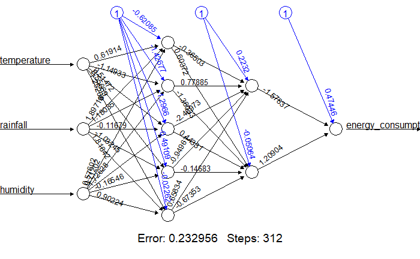

```r
# One hidden layer with 5 neurons
hidden = c(5)

# Two hidden layers, one with 4 neurons and another with 3 neurons
hidden = c(4, 3)

# Two hidden layers: first with 5 neurons, second with 2
energy_model_2 <- neuralnet(energy_consumption ~ temperature + rainfall + humidity,
                            data = energy_train,
                            hidden = c(5, 2))
# Plot the neural network
plot(energy_model_2)
```

We can try to use different activation function as well:

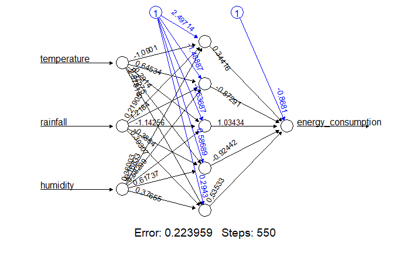

```r
softplus <- function(x) log(1 + exp(x))

energy_model_softplus <- neuralnet(energy_consumption ~ temperature + rainfall + humidity,
                                   data = energy_train,
                                   hidden = c(5),
                                   act.fct = softplus)

plot(energy_model_softplus)
```

## Unsupervised Learning

Unsupervised learning discovers patterns in data without labeled outputs.

### Clustering: K-Means

K-Means clustering partitions data into k clusters by minimizing within-cluster variance:

$$\begin{align*}
\arg \min_{S} \sum_{i=1}^{k} \sum_{x_j \in S_i} || x_j - \mu_i ||^2
\end{align*}$$

where: $x_j$ is a data point. $\mu_i$ is the centroid of cluster i.

In R:

```r
set.seed(42)
kmeans_model <- kmeans(dataset, centers = 3)
```

### Principal Component Analysis (PCA)

PCA reduces dimensionality while preserving variance:

$$\begin{align*}
Z = XW
\end{align*}$$

where: Z is the transformed data. X is the original data matrix. W contains eigenvectors.

In R:

```r
pca_result <- prcomp(dataset, center = TRUE, scale. = TRUE)
biplot(pca_result)
```

## Reinforcement Learning

Reinforcement Learning (RL) involves an agent that interacts with an environment, receiving rewards for actions.

### Markov Decision Processes (MDP)

MDPs are defined by:

$$\begin{align*}
(s, a, r, s')
\end{align*}$$

where: s is the state, a is the action, r is the reward, s’ is the next state.

### Q-Learning

Q-Learning updates the action-value function:

$$\begin{align*}
Q(s, a) = Q(s, a) + \alpha [r + \gamma \max_{a'} Q(s', a') -
Q(s, a)]
\end{align*}$$

where: α is the learning rate, γ is the discount factor.

## Diagnostics

### Confusion Matrix

A confusion matrix is a table used to evaluate the performance of a classification model. It compares the predicted labels with the actual ones, summarizing the number of correct and incorrect predictions. The matrix is structured around four terms: true positives (TP), true negatives (TN), false positives (FP), and false negatives (FN). It is the foundation for most classification metrics. A false positive occurs when the model predicts positive (1) but the true label is negative (0).A false negative occurs when the model predicts negative (0) but the true label is positive (1). A true positive occurs when the model predicts positive (1) and the actual class is also positive (1). A true negative occurs when the model predicts negative (0) and the actual class is also negative (0).

$$\begin{bmatrix}
\text{TP} & \text{FP} \\
\text{FN} & \text{TN} \\
\end{bmatrix}$$

### Accuracy

Accuracy is the proportion of correct predictions over the total number of predictions. It is a general measure of model performance but can be misleading when the dataset is imbalanced.

$$\text{Accuracy} = \frac{TP + TN}{TP + FP + TN + FN}$$

High Accuracy means:

- The model is generally making correct predictions.

Accuracy can be misleading when: Classes are imbalanced.

### Precision

Precision measures the proportion of correctly predicted positive observations among all predicted positives. It reflects the model’s ability to avoid false positives and is especially useful when the cost of a false alarm is high.

$$\text{Precision} = \frac{TP}{TP + FP}$$

High Precision (close to 1) means:

- Your model rarely gives false positives.
- When it predicts positive, it’s usually correct.

Low Precision (close to 0) means:

- Your model often predicts positive when it’s wrong.
- You have many false positives.

### Recall

Recall, also known as sensitivity or true positive rate, measures the proportion of correctly predicted positive observations among all actual positives. It is useful when missing a positive case (false negative) is costly.

$$\text{Recall} = \frac{TP}{TP + FN}$$

High Recall (close to 1) means:

- Your model finds most of the actual positives.
- Few false negatives (i.e., few misses).

Low Recall (close to 0) means:

- Your model misses a lot of positives.
- Many false negatives.

### F1-Score

The F1-score is the harmonic mean of precision and recall. It balances the trade-off between the two metrics and is most useful when the dataset is imbalanced or when both false positives and false negatives matter.

$$\text{F1 - Score} = 2 \cdot \frac{\text{Precision} \cdot
\text{Recall}}{\text{Precision} + \text{Recall}}$$

High F1 Score (close to 1) means:

- Your model is performing well both in precision and recall.
- You have few false positives and few false negatives.
- You are capturing most of the relevant cases and making few mistakes in predictions.

Low F1 Score (close to 0) means:

- Either precision, recall, or both are low.
- Your model may be making many false positives or false negatives.
- Especially problematic in sensitive applications like medical diagnosis or fraud detection.

### ROC Curve and AUC

The ROC (Receiver Operating Characteristic) curve plots the true positive rate against the false positive rate at various classification thresholds. The AUC (Area Under the Curve) quantifies the overall ability of the model to discriminate between classes. A higher AUC indicates better classification performance across all thresholds.

$$\text{TPR} = \frac{TP}{TP + FN}, \quad \text{FPR} = \frac{FP}{FP + TN}$$

### Balanced Accuracy

Balanced Accuracy is an adjusted version of accuracy that accounts for class imbalance. It is the average of recall (sensitivity) calculated separately for each class. In binary classification, it is the mean of the true positive rate (TPR) and the true negative rate (TNR).

$$\text{Balanced Accuracy} = \frac{1}{2} \left( \frac{TP}{TP + FN} +
\frac{TN}{TN + FP} \right)$$

### Cohen’s Kappa

Cohen’s Kappa measures the agreement between predicted and actual labels, adjusted for chance agreement. It ranges from -1 (complete disagreement) to 1 (perfect agreement), where 0 represents agreement no better than random guessing.

$$\kappa = \frac{p_o - p_e}{1 - p_e}$$

Where $p_o$ is the observed agreement (same as accuracy) and $p_e$ is the expected agreement by chance, calculated based on the marginal frequencies of predicted and actual labels. Kappa compares your model’s performance to random chance.

- k=1: perfect agreement between the predicted and actual classifications
- k=0: no better than random
- k<0: worse than random

### Hosmer-Lemeshow

The Hosmer-Lemeshow Goodness of Fit Test is a statistical test used to evaluate the calibration of a logistic regression model—that is, how well the predicted probabilities align with the observed outcomes. The test works by dividing the data into deciles (or groups) based on predicted probabilities, and then comparing the number of observed and expected outcomes within each group using a chi-squared statistic.

We have two hypothesis:

- $H_0$: the model is a good fit.
- $H_a$: the model is not a good fit.

A high p-value (typically > 0.05) indicates good fit, suggesting that the model’s predictions are consistent with the observed data (we do not reject the null hypothesis). Conversely, a low p-value suggests that the model may be poorly calibrated. It is important to note that this test is sensitive to sample size and groupings, and should be interpreted alongside other diagnostics such as residual plots or ROC curves.

```r
library(ResourceSelection)

# Get predicted probabilities
train_probs <- predict(step_model, newdata = Ex1_data_train, type = "response")

# Perform Hosmer-Lemeshow test
hoslem.test(Ex1_data_train$Class, train_probs, g = 10)
```

Here it’s important to state that Hosmer-Lemeshow test is checking for calibration, not discrimination. It’s asking “are the predicted probabilities consistent with actual observed frequencies across deciles?”.A high p-value indicates that , when the model says “there is a 10% chance of malignant”, about 10% of those cases really are malignant, even if it misclassifies most of them. So it can happen that accuracy is low and also the model has a good fit. For the accuracy, it can happen because of the classification threshold (ex. 0.5, 0.9) and not the underlying probability estimates.

# Case Studies

## Case 1

Inflation vs Expected inflation

Let’s suppose we want to analyze the relationship between the IPCA and the inflation expectations projected by the Top 5 Long-Term economists from Focus, with a one-year lead. Our goal is to assess the accuracy and reliability of these forecasts for the IPCA.

### Importing data

```r
Data_1 <- read.csv("Case1.csv")
summary(Data_1)
```

```
##       Ano        Expectativa         IPCA
##  Min.   :2005   Min.   :3.500   Min.   : 2.950
##  1st Qu.:2010   1st Qu.:4.022   1st Qu.: 4.423
##  Median :2014   Median :4.860   Median : 5.740
##  Mean   :2014   Mean   :4.923   Mean   : 5.593
##  3rd Qu.:2019   3rd Qu.:5.478   3rd Qu.: 6.005
##  Max.   :2024   Max.   :6.830   Max.   :10.670
```

```r
head(Data_1)
```

```
##    Ano Expectativa IPCA
## 1 2005        5.72 5.69
## 2 2006        4.77 3.14
## 3 2007        3.95 4.46
## 4 2008        4.23 5.90
## 5 2009        4.95 4.31
## 6 2010        4.68 5.91
```

### Fit the simple regression model

Fit using the lm() function to fit a simple linear regression model, with Y as the response and X as the predictor. The basic syntax is lm(y ~ x, data), where y is the response, x is the predictor, and data is the data set in which these two variables are kept.

```r
X <- Data_1$Expectativa
Y <- Data_1$IPCA
model_1 <- lm(Y ~ X, data = Data_1)
summary(model_1)
```

```
##
## Call:
## lm(formula = Y ~ X, data = Data_1)
##
## Residuals:
##     Min      1Q  Median      3Q     Max
## -2.5273 -0.7813 -0.1489  0.1493  5.4163
##
## Coefficients:
##             Estimate Std. Error t value Pr(>|t|)
## (Intercept)   2.3095     2.2102   1.045    0.310
## X             0.6669     0.4407   1.513    0.148
##
## Residual standard error: 1.881 on 18 degrees of freedom
## Multiple R-squared:  0.1129, Adjusted R-squared:  0.06358
## F-statistic:  2.29 on 1 and 18 DF,  p-value: 0.1476
```

The residuals suggest that the model underpredicts some values (as seen from the large positive residual of 5.4163) and overpredicts others (negative residual of -2.5273). Ideally, residuals should be symmetrically distributed around zero with no pattern.

About the coefficients, b0 is equal to 2.31. It suggests that when the expected inflation is zero, the predicted inflation is 2.31. The p-value (0.310) is quite large, meaning this intercept is not significantly different from zero at a conventional significance level (5%). The slope (b1) is 0.6669. This means that for each 1-unit increase in expected inflation, the actual inflation is expected to increase by 0.6669 units, on average. The p-value (0.148) indicates that we fail to reject the null hypothesis (H₀: β₁ = 0). This suggests that the expected inflation does not significantly explain the actual inflation at the 5% level.

The R-squared is 0.1129. This means that only 11.29% of the variance in actual inflation (Y) is explained by expected inflation (X).This is a very low R-squared, suggesting that the model does not capture much of the variability in the data.

The F-statistic tests the overall significance of the model (H₀: all coefficients = 0).A p-value of 0.1476 means we fail to reject the null hypothesis, implying that the model does not significantly explain variations in Y.

```r
names(model_1)
```

```
##  [1] "coefficients"  "residuals"     "effects"       "rank"
##  [5] "fitted.values" "assign"        "qr"            "df.residual"
##  [9] "xlevels"       "call"          "terms"         "model"
```

```r
coef(model_1)
```

```
## (Intercept)           X
##   2.3094627   0.6669112
```

```r
confint(model_1)
```

```
##                  2.5 %   97.5 %
## (Intercept) -2.3339652 6.952891
## X           -0.2589747 1.592797
```

We can use the names() function in order to find out what other pieces of information are stored in model_1. Although we can extract these quantities by name, it is safer to use the extractor functions like coef() to access them. In order to obtain a confidence interval for the coefficient estimates, we can use the confint() command.

```r
predict(model_1, data.frame(X = (c(1,5,10))),interval = "confidence")
```

```
##        fit        lwr       upr
## 1 2.976374 -0.7622356  6.714983
## 2 5.644019  4.7576721  6.530365
## 3 8.978575  4.1959982 13.761151
```

```r
predict(model_1, data.frame(X = (c(1,5,10))),interval = "prediction")
```

```
##        fit       lwr       upr
## 1 2.976374 -2.463210  8.415957
## 2 5.644019  1.594639  9.693399
## 3 8.978575  2.774954 15.182195
```

The predict() function can be used to produce confidence intervals and prediction intervals for the prediction of Y for a given value of X. For instance, the 95 % confidence interval associated with a X value of 10 is (4.19, 13.76), and the 95 % prediction interval is (2.77, 15.18). As expected, the confidence and prediction intervals are centered around the same point (a predicted value of 8.98 for Y when X equals 10), but the latter are substantially wider. That’s because the prediction has has a additional +1 term inside the formula, which makes it wider. Normally we use confidence intervals when interested in the mean response of Y for a given X, and we use prediction when making predictions for a new individual observation.

### Plots

#### Scatter plot with a regression line

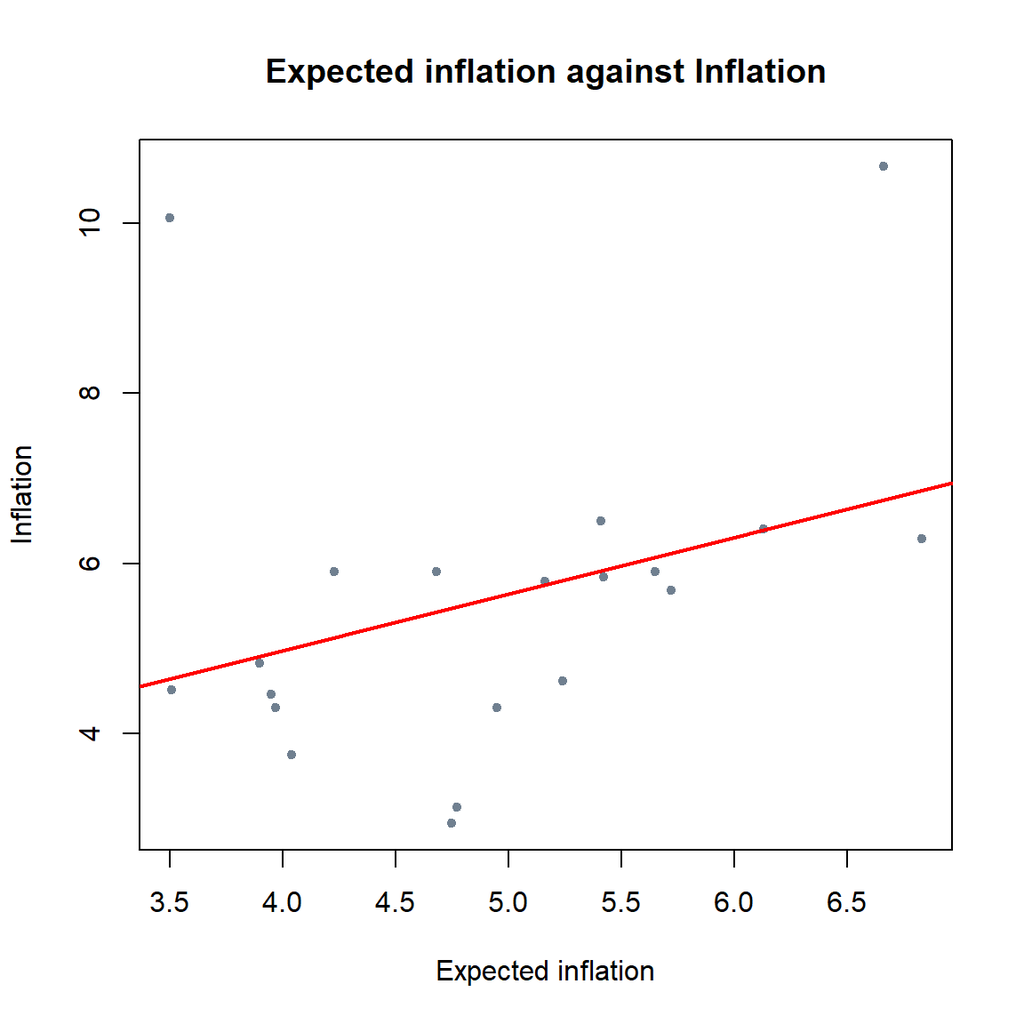

```r
# Scatter plot with regression line
plot(X, Y,
     main = "Expected inflation against Inflation",
     xlab = "Expected inflation", ylab = "Inflation",
     pch = 20,
     col = "slategray",
     xlim = range(X),
     ylim = range(Y))
abline(model_1, lwd = 2, col = "red")
```

#### Scatter plot with a regression line with confidence band

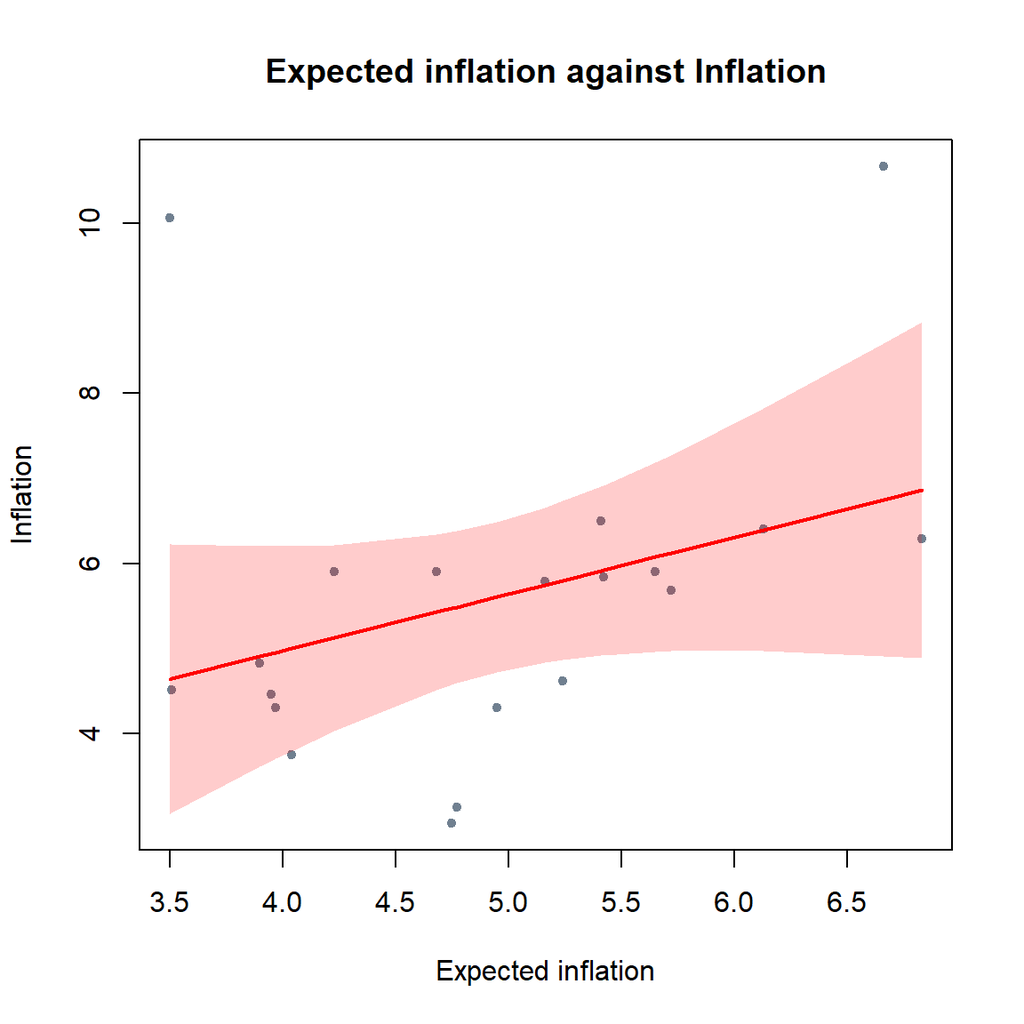

```r
# Scatter plot with regression line and confidence band
plot(X, Y,
     main = "Expected inflation against Inflation",
     xlab = "Expected inflation",
     ylab = "Inflation",
     pch = 20,
     col = "slategray",
     xlim = range(X),
     ylim = range(Y))

# Get predictions with confidence intervals
predictions <- predict(model_1, interval = "confidence")

# Extract fitted values and confidence intervals
X_sorted <- sort(X)  # Ensure X is sorted for smooth bands
pred_sorted <- predictions[order(X), ]  # Match sorted X

# Add regression line
lines(X_sorted, pred_sorted[, "fit"], col = "red", lwd = 2)

# Add confidence band (shaded area)
polygon(c(X_sorted, rev(X_sorted)),
        c(pred_sorted[, "lwr"], rev(pred_sorted[, "upr"])),
        col = rgb(1, 0, 0, 0.2), border = NA)  # Transparent red band
```

## Case 2

LULUCF Emission vs Rate of deforestation

Let’s suppose we want to analyze the relationship between the LULUCF Emission $(ktCO_{2}e)$ and the Rate of deforestation $(km^{2})$ from TerraBrasilis. Our goal is to understand how much of the variance can be explained by the rate of deforestation.

### Creating the model

Let’s create here a data partition with a sample of 70% observations from the data set for the train data and remaining cases for test data set.

```r
library(caret)
Data_2 <- read.csv("Case2.csv")
head(Data_2)
```

```
##   year  Area  LULUCF
## 1 1990 13730  908066
## 2 1991 11030  726204
## 3 1992 13786  839122
## 4 1993 14896  874712
## 5 1994 14896  854112
## 6 1995 29059 1973225
```

```r
# Set seed for reproducibility
set.seed(1023)

#split the data into two parts 70-30 split
DataSplit<-createDataPartition(y = Data_2$LULUCF, p = 0.7, list = FALSE)

#creating the train and test data set
Case2_data_train<-Data_2[DataSplit,]
Case2_data_test<-Data_2[-DataSplit,]

# You need to verify, do I have really 70% or close
n <- length(Y)
Seventy_percent_sample_size<-round(0.7*n,0)
# Result of the R-function
R_function<-length(Case2_data_train$LULUCF)

# Compare side by side
cbind(Seventy_percent_sample_size,R_function)
```

```
##      Seventy_percent_sample_size R_function
## [1,]                          14         25
```

```r
#Try to perfect
ind<-sample(1:n,0.71*n)
Case2_data_train <- Data_2[ind, ]
Case2_data_test <- Data_2[-ind, ]

#put the results together to compare side by side
Alternative_R_function<-length(Case2_data_train$LULUCF)
cbind(Seventy_percent_sample_size,Alternative_R_function)
```

```
##      Seventy_percent_sample_size Alternative_R_function
## [1,]                          14                     14
```

Now let’s create the model with the train data:

```r
model_2 <- lm(Case2_data_train$LULUCF ~ Case2_data_train$Area, data = Case2_data_train)
summary(model_2)
```

```
##
## Call:
## lm(formula = Case2_data_train$LULUCF ~ Case2_data_train$Area,
##     data = Case2_data_train)
##
## Residuals:
##     Min      1Q  Median      3Q     Max
## -400192 -130766    4618  130948  395987
##
## Coefficients:
##                         Estimate Std. Error t value Pr(>|t|)
## (Intercept)           -342535.42  198874.16  -1.722    0.111
## Case2_data_train$Area      93.46      10.59   8.823 1.36e-06 ***
## ---
## Signif. codes:  0 '***' 0.001 '**' 0.01 '*' 0.05 '.' 0.1 ' ' 1
##
## Residual standard error: 244500 on 12 degrees of freedom
## Multiple R-squared:  0.8664, Adjusted R-squared:  0.8553
## F-statistic: 77.85 on 1 and 12 DF,  p-value: 1.36e-06
```

Here we see that the model have a high $R^2$, with the overall p-value < 0.05, showing that the model is significant. Also, the p-value of the variable X is smaller than 0.05, showing that the reject the null hypotheshis $H_0: \beta_1 = 0$.

```r
dispRegFunc <- function(reg) {
coefs <- reg$coefficients
b0 = coefs[1]
n <- length(coefs)
my_formula <- paste0("Y = ", round(b0, digits = 6))
for (i in 2:n) {
my_formula <- paste0(my_formula, " + ", round(coefs[i],6), "*", names(coefs)[i])
}
my_formula
}
dispRegFunc(model_2)
```

```
## [1] "Y = -342535.423751 + 93.463387*Case2_data_train$Area"
```

Let’s do a scatter plot:

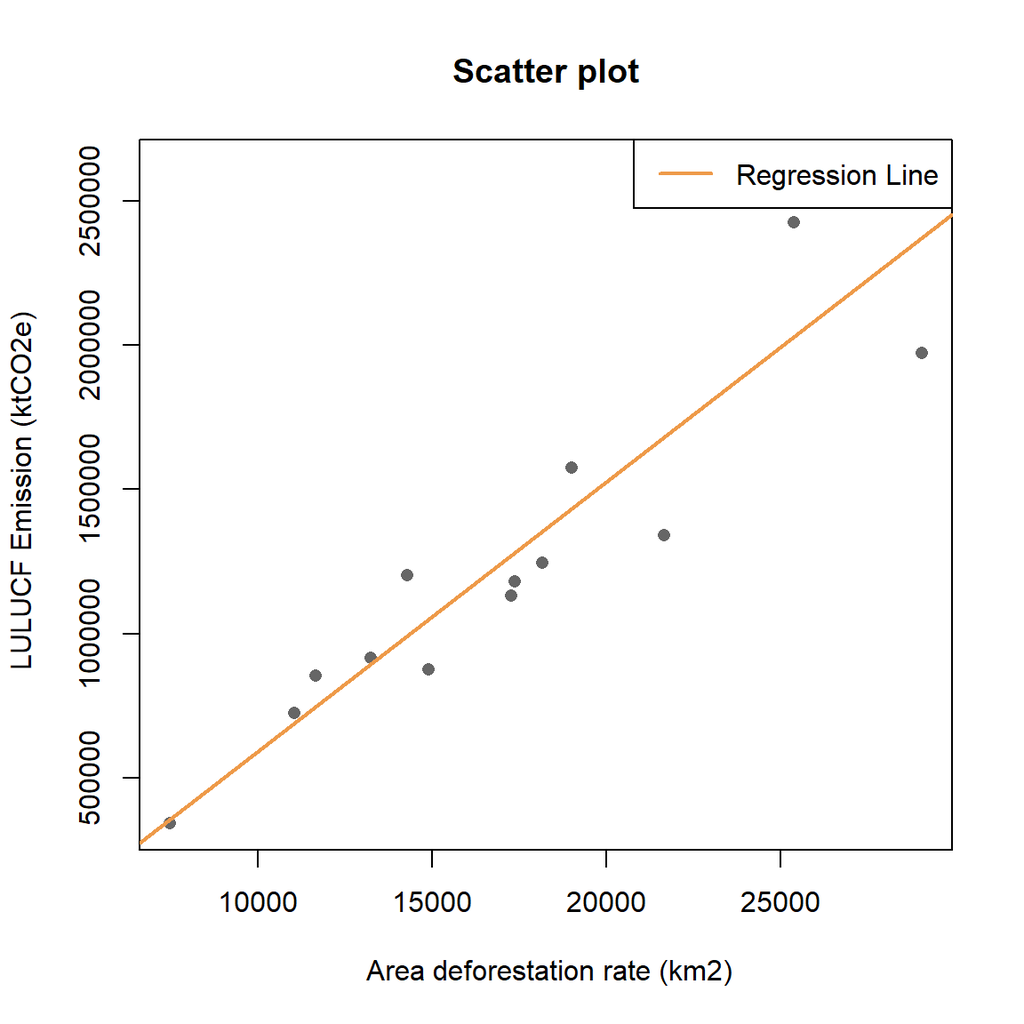

```r
# Plot scatter plot of data
plot(Case2_data_train$Area, Case2_data_train$LULUCF,
     main = "Scatter plot",
     xlab = " Area deforestation rate (km2)",
     ylab = " LULUCF Emission (ktCO2e)",
     col = "gray40",
     pch = 16)

# Add regression line
abline(model_2, col = "tan2", lwd = 2)

# Add legend
legend("topright", legend = "Regression Line", col = "tan2", lwd = 2)
```

Let’s now test whether or not there is a linear association between Area and LULUCF, using a t test with $\alpha =0.01$.

```r
#Setting General parameters
n <- length(Case2_data_train$Area)
df <- n-2
alpha <- 0.01


#Calculating critical t-value
tdf <- qt(1-alpha/2,df)
print(paste("The critical t-value is " ,round(tdf,2)))
```

```
## [1] "The critical t-value is  3.05"
```

```r
#Calculating t
Sxx <-sum((Case2_data_train$Area - mean(Case2_data_train$Area))^2)
b1 <- sum((Case2_data_train$Area - mean(Case2_data_train$Area))*(Case2_data_train$LULUCF - mean(Case2_data_train$LULUCF)))/Sxx
b0 <- mean(Case2_data_train$LULUCF) - b1*mean(Case2_data_train$Area)
SSE <- sum((Case2_data_train$LULUCF - (b0+b1*Case2_data_train$Area) )^2)
MSE <- SSE/df
sb1 <- sqrt(MSE/Sxx)
sb0 <- sqrt(MSE*(1/n + (mean(Case2_data_train$Area)^2/Sxx)))

t <- b1/sb1
print(paste("The t-value is " ,abs(round(t,2))))
```

```
## [1] "The t-value is  8.82"
```

```r
#Calculating p-value
p_value <- 2 * pt(abs(t), df, lower.tail = FALSE)
print(paste("The p-value is " ,abs(round(p_value,15))))
```

```
## [1] "The p-value is  1.360445471e-06"
```

First we state the null hypothesis $H_0: b_1 = 0$ (there is no relationship between X and Y), and the alternative hypothesis $H_a: b_1 \ne 0$ (there is a relationship between X and Y).

Since the absolute value of the t-value is bigger than the critical t-value, we reject $H_0$, meaning that, at a 1% significance level, the X variable is significant. We can conclude the same by checking that the p-value (<<0.01) is very small and less than 0.01.

For last, let’s compute the confidence band:

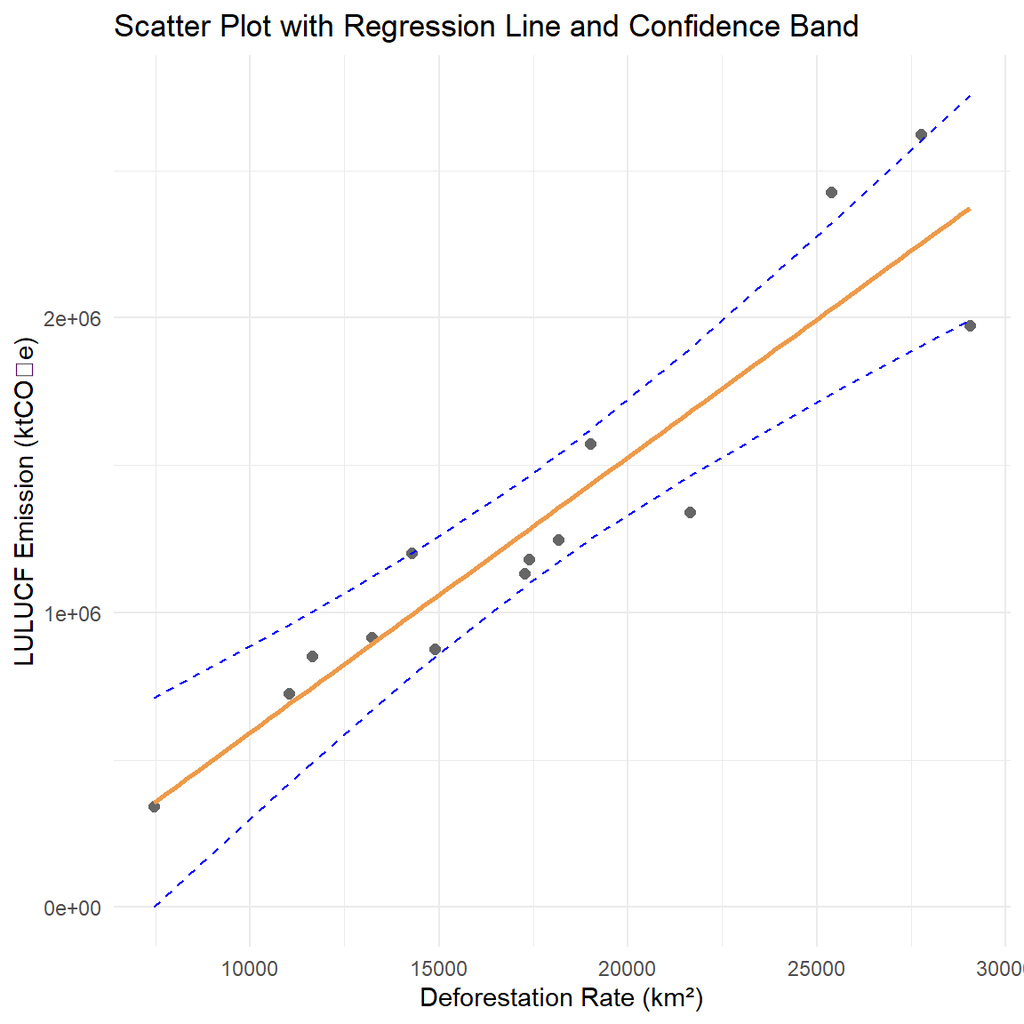

```r
# Define alpha and degrees of freedom
alpha <- 0.05
n <- length(Case2_data_train$Area)
df <- n - 2

# Compute the critical W value for the confidence band
F_value <- qf(1 - alpha, df1 = 2, df2 = df)
W <- sqrt(2 * F_value)

# Generate predicted values and standard errors
predictions <- predict(model_2, newdata = data.frame(Area = Case2_data_train$Area), se.fit = TRUE)

# Calculate upper and lower confidence band
Y_fit <- predictions$fit
se_Y_fit <- predictions$se.fit
lower_band <- Y_fit - W * se_Y_fit
upper_band <- Y_fit + W * se_Y_fit

# Create the plot
ggplot(Case2_data_train, aes(x = Area, y = LULUCF)) +
  geom_point(color = "gray40", size = 2) +  # Scatter plot points
  geom_smooth(method = "lm", color = "tan2", se = FALSE) +  # Regression line
  geom_line(aes(y = lower_band), color = "blue", linetype = "dashed") +  # Lower bound
  geom_line(aes(y = upper_band), color = "blue", linetype = "dashed") +  # Upper bound
  labs(
    title = "Scatter Plot with Regression Line and Confidence Band",
    x = "Deforestation Rate (km²)",
    y = "LULUCF Emission (ktCO₂e)"
  ) +
  theme_minimal()
```

## Case 3

CO2 emissions by ship type

Let’s suppose we want to analyze the relationship between the CO2 emission by distance from ships by ship type, fuel consumption , weather conditions, engine efficiency, fuel type.

### Importing data

Let’s import the data.

```r
library(caret)
library(DT)

#Import the data
Data_3 <- read.csv("Case3.csv")
Y <- Data_3$CO2_Emissions
X1 <- Data_3$ship_type
X2 <- Data_3$distance
X3 <- Data_3$fuel_type
X4 <- Data_3$fuel_consumption
X5 <- Data_3$weather_conditions
X6 <- Data_3$engine_efficiency

#Create a table
datatable(Data_3, options = list(
  pageLength = 6,
  autoWidth = TRUE,
  columnDefs = list(list(width = '150px', targets = "_all"))
), caption = "Dataset")
```

|  | ship_id | ship_type | route_id | month | distance | fuel_type | fuel_consumption | CO2_emissions | weather_conditions | engine_efficiency |
| --- | --- | --- | --- | --- | --- | --- | --- | --- | --- | --- |
| 1 | NG001 | Oil Service Boat | Warri-Bonny | January | 132.26 | HFO | 3779.77 | 10625.76 | Stormy | 92.14 |
| 2 | NG001 | Oil Service Boat | Port Harcourt-Lagos | February | 128.52 | HFO | 4461.44 | 12779.73 | Moderate | 92.98 |
| 3 | NG001 | Oil Service Boat | Port Harcourt-Lagos | March | 67.3 | HFO | 1867.73 | 5353.01 | Calm | 87.61 |
| 4 | NG001 | Oil Service Boat | Port Harcourt-Lagos | April | 71.68 | Diesel | 2393.51 | 6506.52 | Stormy | 87.42 |
| 5 | NG001 | Oil Service Boat | Lagos-Apapa | May | 134.32 | HFO | 4267.19 | 11617.03 | Calm | 85.61 |
| 6 | NG001 | Oil Service Boat | Port Harcourt-Lagos | June | 85.93 | Diesel | 2342.13 | 6753.42 | Stormy | 72.82 |
| 7 | NG001 | Oil Service Boat | Warri-Bonny | July | 85.67 | HFO | 2974.79 | 8498.16 | Moderate | 93.93 |
| 8 | NG001 | Oil Service Boat | Warri-Bonny | August | 44.81 | Diesel | 1376.38 | 3509.56 | Moderate | 91.1 |
| 9 | NG001 | Oil Service Boat | Escravos-Lagos | September | 116.44 | Diesel | 3661.75 | 9423.97 | Calm | 73.41 |
| 10 | NG001 | Oil Service Boat | Lagos-Apapa | October | 99.73 | HFO | 2551.99 | 6416.66 | Moderate | 94.68 |

[output cut: 1430 more lines]

Now let’s create the dummy variables for Ship type, fuel type and weather condition:

```r
# View unique values of categorical variables
unique(X1)
```

```
## [1] "Oil Service Boat" "Fishing Trawler"  "Surfer Boat"      "Tanker Ship"
```

```r
unique(X3)
```

```
## [1] "HFO"    "Diesel"
```

```r
unique(X5)
```

```
## [1] "Stormy"   "Moderate" "Calm"
```

```r
# Convert categorical variables into numeric labels
Data_3$X1c <- as.numeric(as.factor(X1))
Data_3$X5c <- as.numeric(as.factor(X5))

#creating a dummy variable
Data_3$X3c = I(Data_3$fuel_type == "HFO")*1

# Remove specific columns
Data_3 <- subset(Data_3, select = -c(ship_id, route_id, month))


head(Data_3)
```

```
##          ship_type distance fuel_type fuel_consumption CO2_emissions
## 1 Oil Service Boat   132.26       HFO          3779.77      10625.76
## 2 Oil Service Boat   128.52       HFO          4461.44      12779.73
## 3 Oil Service Boat    67.30       HFO          1867.73       5353.01
## 4 Oil Service Boat    71.68    Diesel          2393.51       6506.52
## 5 Oil Service Boat   134.32       HFO          4267.19      11617.03
## 6 Oil Service Boat    85.93    Diesel          2342.13       6753.42
##   weather_conditions engine_efficiency X1c X5c X3c
## 1             Stormy             92.14   2   3   1
## 2           Moderate             92.98   2   2   1
## 3               Calm             87.61   2   1   1
## 4             Stormy             87.42   2   3   0
## 5               Calm             85.61   2   1   1
## 6             Stormy             72.82   2   3   0
```

```r
unique(Data_3$X1c)
```

```
## [1] 2 1 3 4
```

```r
unique(Data_3$X3c)
```

```
## [1] 1 0
```

```r
unique(Data_3$X5c)
```

```
## [1] 3 2 1
```

### Creating the model

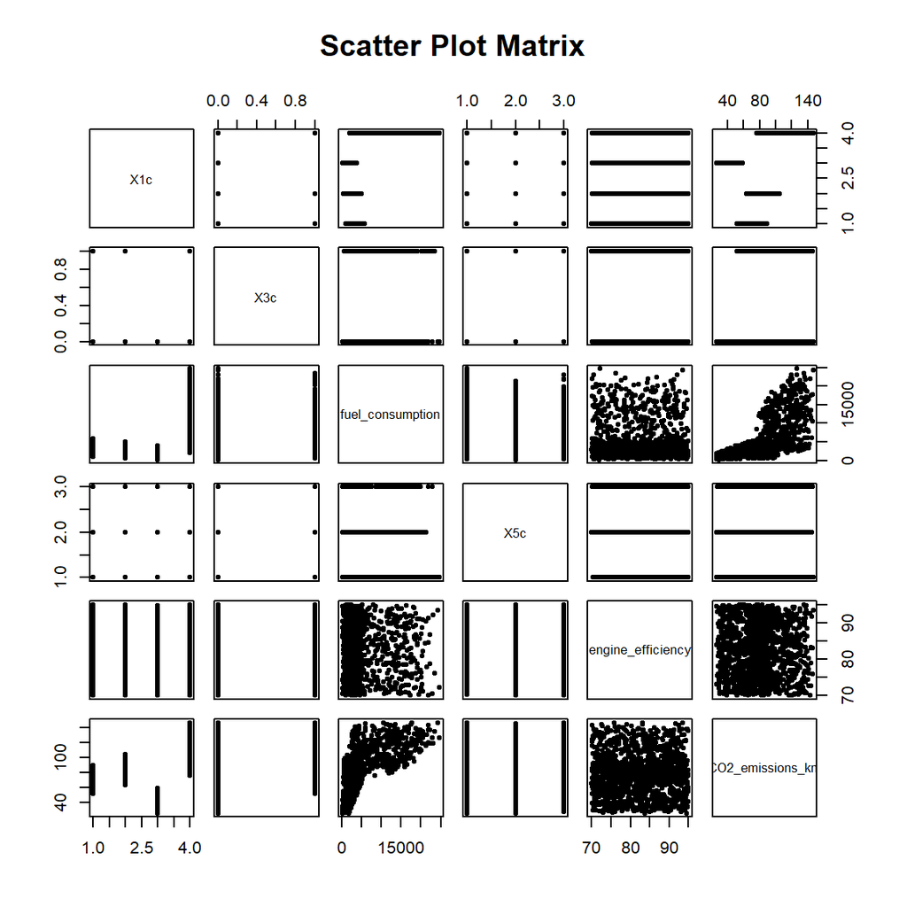

```r
Data_3$CO2_emissions_km <- Data_3$CO2_emissions/Data_3$distance
Data_3b <- subset(Data_3, select = c(X1c, X3c, fuel_consumption, X5c,engine_efficiency, CO2_emissions_km))

# Plot scatter plot matrix
pairs(Data_3b, main = "Scatter Plot Matrix", pch = 20, col = "black")
```

```r
# Compute correlation matrix for selected variables
cor_matrix <- round(cor(Data_3b),1)
print(cor_matrix)
```

```
##                    X1c  X3c fuel_consumption  X5c engine_efficiency
## X1c                1.0 -0.1              0.6  0.0                 0
## X3c               -0.1  1.0              0.1  0.0                 0
## fuel_consumption   0.6  0.1              1.0  0.0                 0
## X5c                0.0  0.0              0.0  1.0                 0
## engine_efficiency  0.0  0.0              0.0  0.0                 1
## CO2_emissions_km   0.4  0.3              0.7 -0.1                 0
##                   CO2_emissions_km
## X1c                            0.4
## X3c                            0.3
## fuel_consumption               0.7
## X5c                           -0.1
## engine_efficiency              0.0
## CO2_emissions_km               1.0
```

We see strong linear relationship between CO2 emissions by km and fuel consumption. Let’s create a model.

```r
model_3a <- lm(Data_3b$CO2_emissions_km ~ Data_3b$X1c  + Data_3b$X3c + Data_3b$fuel_consumption + Data_3b$X5c + Data_3b$engine_efficiency, data = Data_3b)
summary(model_3a)
```

```
##
## Call:
## lm(formula = Data_3b$CO2_emissions_km ~ Data_3b$X1c + Data_3b$X3c +
##     Data_3b$fuel_consumption + Data_3b$X5c + Data_3b$engine_efficiency,
##     data = Data_3b)
##
## Residuals:
##     Min      1Q  Median      3Q     Max
## -40.487 -15.920  -0.128  14.198  69.609
##
## Coefficients:
##                            Estimate Std. Error t value Pr(>|t|)
## (Intercept)               50.979329   6.361608   8.014 2.29e-15 ***
## Data_3b$X1c                1.621986   0.578123   2.806  0.00509 **
## Data_3b$X3c               11.409608   1.116378  10.220  < 2e-16 ***
## Data_3b$fuel_consumption   0.003487   0.000132  26.418  < 2e-16 ***
## Data_3b$X5c               -0.956496   0.639581  -1.496  0.13500
## Data_3b$engine_efficiency  0.053062   0.073611   0.721  0.47112
## ---
## Signif. codes:  0 '***' 0.001 '**' 0.01 '*' 0.05 '.' 0.1 ' ' 1
##
## Residual standard error: 19.95 on 1434 degrees of freedom
## Multiple R-squared:  0.4928, Adjusted R-squared:  0.4911
## F-statistic: 278.7 on 5 and 1434 DF,  p-value: < 2.2e-16
```

Let’s remove the engine_efficiency and the categorical weather condition variable:

```r
model_3b <- lm(Data_3b$CO2_emissions_km ~ Data_3b$X1c  + Data_3b$X3c + Data_3b$fuel_consumption, data = Data_3b)
summary(model_3b)
```

```
##
## Call:
## lm(formula = Data_3b$CO2_emissions_km ~ Data_3b$X1c + Data_3b$X3c +
##     Data_3b$fuel_consumption, data = Data_3b)
##
## Residuals:
##     Min      1Q  Median      3Q     Max
## -40.951 -15.985   0.353  14.138  69.344
##
## Coefficients:
##                           Estimate Std. Error t value Pr(>|t|)
## (Intercept)              5.346e+01  1.454e+00  36.763  < 2e-16 ***
## Data_3b$X1c              1.612e+00  5.782e-01   2.787  0.00538 **
## Data_3b$X3c              1.152e+01  1.114e+00  10.342  < 2e-16 ***
## Data_3b$fuel_consumption 3.489e-03  1.319e-04  26.456  < 2e-16 ***
## ---
## Signif. codes:  0 '***' 0.001 '**' 0.01 '*' 0.05 '.' 0.1 ' ' 1
##
## Residual standard error: 19.95 on 1436 degrees of freedom
## Multiple R-squared:  0.4919, Adjusted R-squared:  0.4908
## F-statistic: 463.3 on 3 and 1436 DF,  p-value: < 2.2e-16
```

Now we can see if there is any relevant interactions:

```r
model_3c <- lm(Data_3b$CO2_emissions_km ~ Data_3b$X1c  + Data_3b$X3c + Data_3b$fuel_consumption+
                 Data_3b$X1c*Data_3b$X3c + Data_3b$X1c *Data_3b$fuel_consumption+ Data_3b$X3c*Data_3b$fuel_consumption+
                 Data_3b$X1c*Data_3b$X3c*Data_3b$fuel_consumption, data = Data_3b)
summary(model_3c)
```

```
##
## Call:
## lm(formula = Data_3b$CO2_emissions_km ~ Data_3b$X1c + Data_3b$X3c +
##     Data_3b$fuel_consumption + Data_3b$X1c * Data_3b$X3c + Data_3b$X1c *
##     Data_3b$fuel_consumption + Data_3b$X3c * Data_3b$fuel_consumption +
##     Data_3b$X1c * Data_3b$X3c * Data_3b$fuel_consumption, data = Data_3b)
##
## Residuals:
##     Min      1Q  Median      3Q     Max
## -37.219 -13.402  -1.209  11.173  76.484
##
## Coefficients:
##                                                    Estimate Std. Error t value
## (Intercept)                                      54.5585820  4.3903374  12.427
## Data_3b$X1c                                      -1.4348869  1.3990716  -1.026
## Data_3b$X3c                                       0.9413068  6.4910005   0.145
## Data_3b$fuel_consumption                          0.0068269  0.0012173   5.608
## Data_3b$X1c:Data_3b$X3c                          13.0918016  2.0874411   6.272
## Data_3b$X1c:Data_3b$fuel_consumption             -0.0005432  0.0003202  -1.696
## Data_3b$X3c:Data_3b$fuel_consumption             -0.0058632  0.0018589  -3.154
## Data_3b$X1c:Data_3b$X3c:Data_3b$fuel_consumption  0.0004879  0.0004847   1.007
##                                                  Pr(>|t|)
## (Intercept)                                       < 2e-16 ***
## Data_3b$X1c                                       0.30525
## Data_3b$X3c                                       0.88472
## Data_3b$fuel_consumption                         2.45e-08 ***
## Data_3b$X1c:Data_3b$X3c                          4.72e-10 ***
## Data_3b$X1c:Data_3b$fuel_consumption              0.09003 .
## Data_3b$X3c:Data_3b$fuel_consumption              0.00164 **
## Data_3b$X1c:Data_3b$X3c:Data_3b$fuel_consumption  0.31431
## ---
## Signif. codes:  0 '***' 0.001 '**' 0.01 '*' 0.05 '.' 0.1 ' ' 1
##
## Residual standard error: 18.31 on 1432 degrees of freedom
## Multiple R-squared:  0.5734, Adjusted R-squared:  0.5713
## F-statistic:   275 on 7 and 1432 DF,  p-value: < 2.2e-16
```

We have that ship type × fuel type is significant (different ship types react differently to fuel types in terms of emissions), fuel type × fuel consumption is significant (the relationship between fuel consumption and emissions depends on the fuel type), ship type and fuel type alone are not significant, and that the 3-way interaction is not significant as well.

```r
model_3d <- lm(Data_3b$CO2_emissions_km ~ Data_3b$fuel_consumption+
                 Data_3b$X1c*Data_3b$X3c +  Data_3b$X3c*Data_3b$fuel_consumption, data = Data_3b)
summary(model_3d)
```

```
##
## Call:
## lm(formula = Data_3b$CO2_emissions_km ~ Data_3b$fuel_consumption +
##     Data_3b$X1c * Data_3b$X3c + Data_3b$X3c * Data_3b$fuel_consumption,
##     data = Data_3b)
##
## Residuals:
##     Min      1Q  Median      3Q     Max
## -38.843 -13.526  -0.971  10.920  77.474
##
## Coefficients:
##                                        Estimate Std. Error t value Pr(>|t|)
## (Intercept)                          61.4043559  1.7296523  35.501  < 2e-16 ***
## Data_3b$fuel_consumption              0.0047772  0.0001482  32.236  < 2e-16 ***
## Data_3b$X1c                          -3.4976728  0.6921555  -5.053  4.9e-07 ***
## Data_3b$X3c                          -5.2298997  2.4742812  -2.114   0.0347 *
## Data_3b$X1c:Data_3b$X3c              14.9583380  1.0998491  13.600  < 2e-16 ***
## Data_3b$fuel_consumption:Data_3b$X3c -0.0040244  0.0002580 -15.600  < 2e-16 ***
## ---
## Signif. codes:  0 '***' 0.001 '**' 0.01 '*' 0.05 '.' 0.1 ' ' 1
##
## Residual standard error: 18.31 on 1434 degrees of freedom
## Multiple R-squared:  0.5726, Adjusted R-squared:  0.5711
## F-statistic: 384.2 on 5 and 1434 DF,  p-value: < 2.2e-16
```

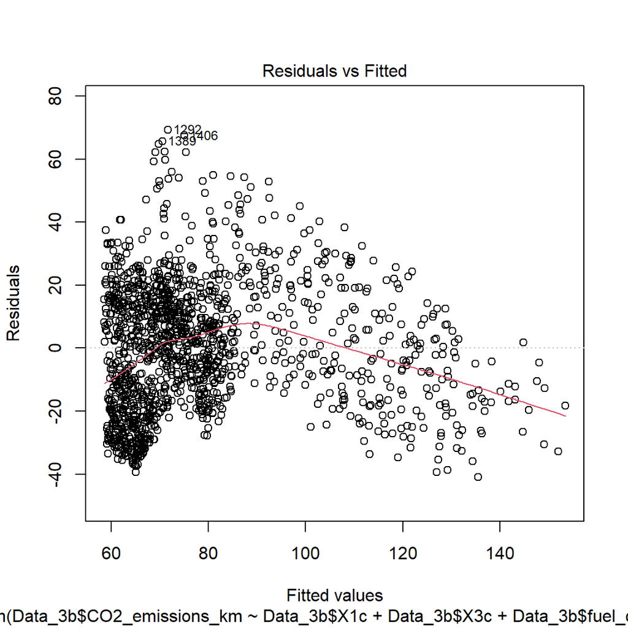

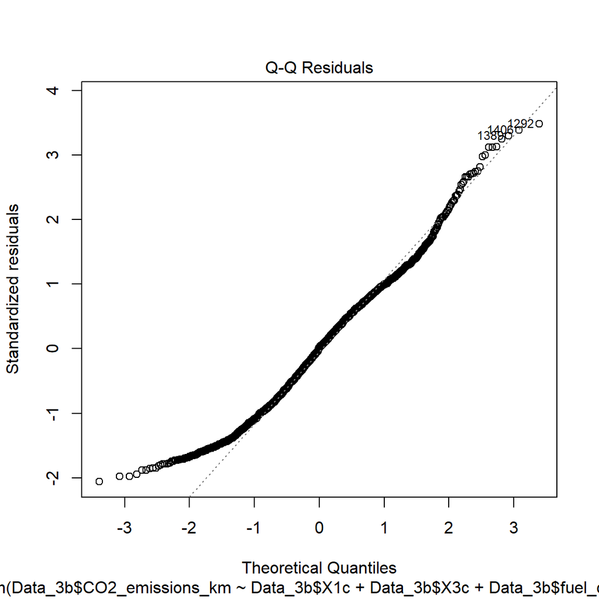

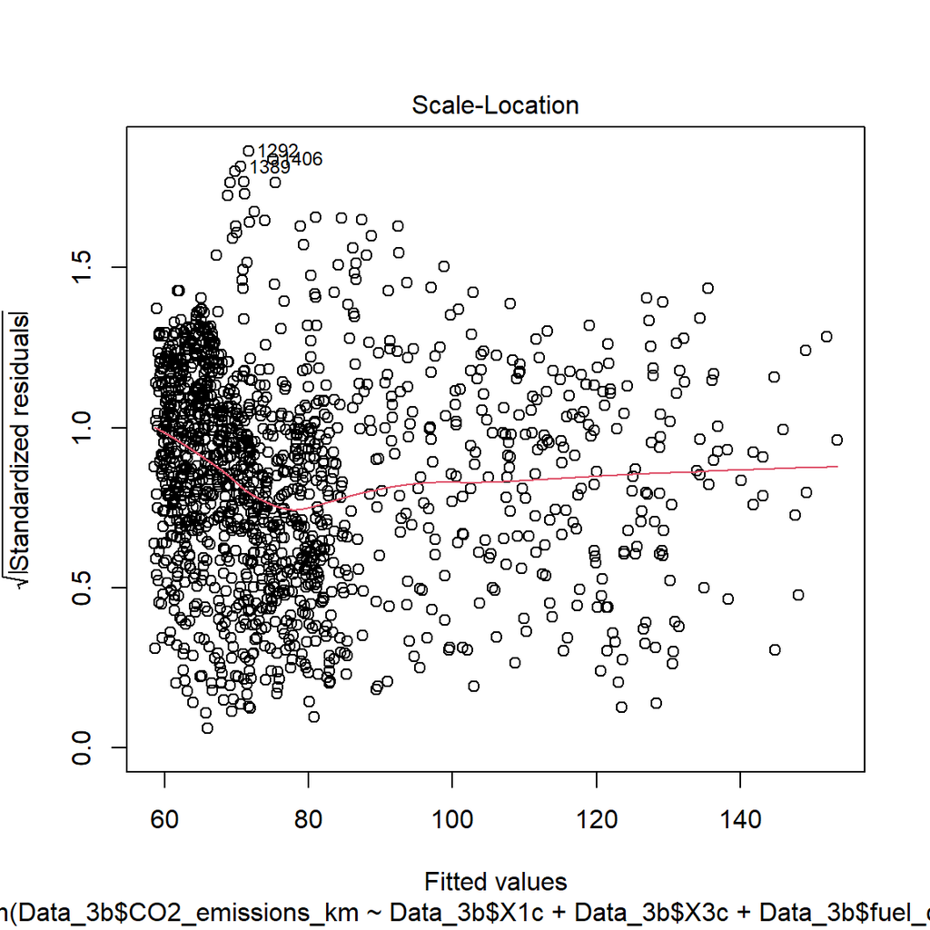

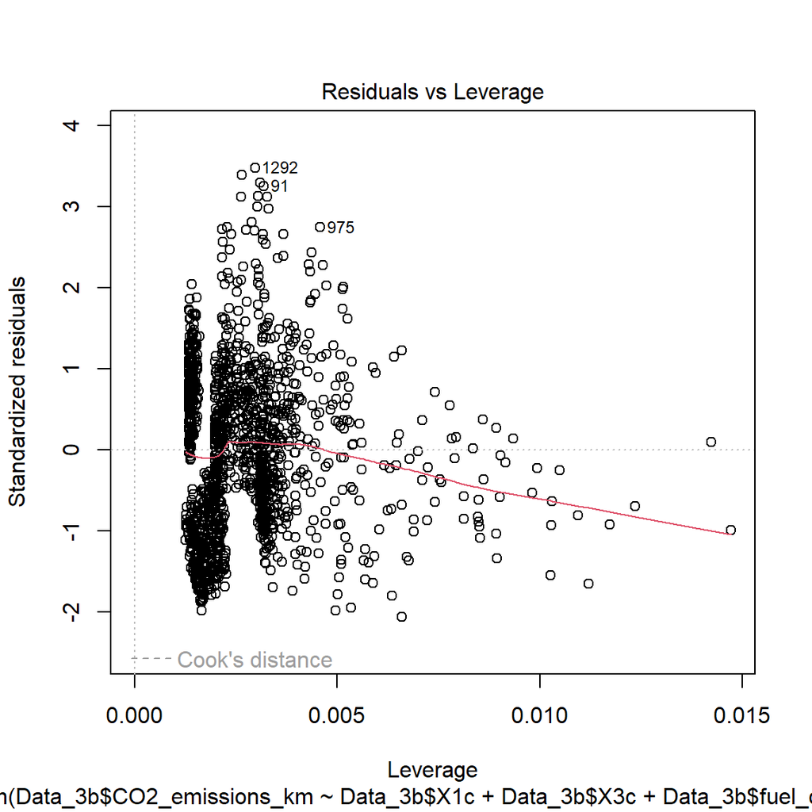

```r
plot(model_3b)
```

### Plotting results

Let’s see how the CO2 emission (kgCO2e/km) is for different ship models and fuels:

[figure not shown]

```r
# Split data for Diesel and HFO
Data_Diesel <- subset(Data_3b, X3c == 0)
Data_HFO <- subset(Data_3b, X3c == 1)


# Plot for Diesel (X3c == 0)
plot(Data_Diesel$fuel_consumption, Data_Diesel$CO2_emissions_km,
     col = Data_Diesel$X1c, pch = 20,
     xlab = "Fuel Consumption", ylab = "CO2 Emissions per km",
     main = "Scatter Plot - Diesel")

legend("topleft", legend = c("Oil Service Boat", "Fishing Trawler", "Surfer Boat","Tanker Ship"), col = 1:4, pch = 20)
```

[figure not shown]

```r
# Plot for HFO (X3c == 1)
plot(Data_HFO$fuel_consumption, Data_HFO$CO2_emissions_km,
     col = Data_HFO$X1c, pch = 20,
     xlab = "Fuel Consumption", ylab = "CO2 Emissions per km",
     main = "Scatter Plot - HFO")

legend("topleft", legend = c("Oil Service Boat", "Fishing Trawler", "Surfer Boat","Tanker Ship"), col = 1:4, pch = 20)
```

For last, let’s compute the CO2 emissions per km for different fuels and ship types:

```r
# Load required libraries
library(ggplot2)



# Compute mean and confidence intervals (95%)
summary_stats <- Data_3b %>%
  group_by(X1c, X3c) %>%
  summarise(
    mean_CO2 = mean(CO2_emissions_km),
    sd_CO2 = sd(CO2_emissions_km),
    n = n(),
    se_CO2 = sd_CO2 / sqrt(n),
    lower_CI = mean_CO2 - 1.96 * se_CO2,  # 95% confidence interval
    upper_CI = mean_CO2 + 1.96 * se_CO2
  )
```

[output not shown]

```r
# Convert X1c to ship names for better visualization
summary_stats$Ship_Type <- factor(summary_stats$X1c,
                                  levels = c(1, 2, 3, 4),
                                  labels = c("Oil Service Boat", "Fishing Trawler", "Surfer Boat", "Tanker Ship"))

# Convert X3c to fuel names
summary_stats$Fuel_Type <- factor(summary_stats$X3c,
                                  levels = c(0,1),
                                  labels = c("Diesel", "HFO"))

# Create a clean data frame
summary_table <- data.frame(
  Ship_Type = summary_stats$Ship_Type,
  Fuel_Type = summary_stats$Fuel_Type,
  Mean_CO2_Emissions = round(summary_stats$mean_CO2, 2),
  Lower_CI_95 = round(summary_stats$lower_CI, 2),
  Upper_CI_95 = round(summary_stats$upper_CI, 2)
)

# Print as a table
print(summary_table)
```

[output not shown]

[figure not shown]

```r
# Plot Mean CO2 Emissions with 95% CI
ggplot(summary_stats, aes(x = Ship_Type, y = mean_CO2, fill = Fuel_Type)) +
  geom_bar(stat = "identity", position = position_dodge(width = 0.6), width = 0.6, color = "black") +
  geom_errorbar(aes(ymin = lower_CI, ymax = upper_CI), width = 0.2, position = position_dodge(width = 0.6)) +
  labs(title = "Mean CO2 Emissions per km by Ship Type and Fuel Type",
       x = "Ship Type", y = "Mean CO2 Emissions per km") +
  theme_minimal() +
  scale_fill_manual(values = c("lightblue", "tan2"))
```

## Case 4

CO2 emissions by vehicles

The “Case 4” dataset provides model-specific fuel consumption ratings and estimated carbon dioxide emissions for new light-duty vehicles available for retail in Canada. It includes attributes such as engine size, cylinders, fuel consumption (city and highway), and CO₂ emissions. Given the potential nonlinear relationships between variables like engine size and emissions, polynomial regression can be effectively applied.

### Importing data

```r
Data_4 <- read.csv("Case4.csv")
#Create a table
datatable(Data_4, options = list(
  pageLength = 6,
  autoWidth = TRUE,
  columnDefs = list(list(width = '150px', targets = "_all"))
), caption = "Dataset")
```

|  | Model.Year | Make | Model | Vehicle.Class | Engine.Size.L. | Cylinders | Transmission | Fuel.Type | Fuel.Consumption..City..L.100.km. | Fuel.Consumption.Hwy..L.100.km.. | Fuel.Consumption.Comb..L.100.km.. | Fuel.Consumption.Comb..mpg.. | CO2.Emissions.g.km. | CO2.Rating | Smog.Rating |
| --- | --- | --- | --- | --- | --- | --- | --- | --- | --- | --- | --- | --- | --- | --- | --- |
| 1 | 2022 | Acura | ILX | Compact | 2.4 | 4 | AM8 | Z | 9.9 | 7 | 8.6 | 33 | 200 | 6 | 3 |
| 2 | 2022 | Acura | MDX SH-AWD | SUV: Small | 3.5 | 6 | AS10 | Z | 12.6 | 9.4 | 11.2 | 25 | 263 | 4 | 5 |
| 3 | 2022 | Acura | RDX SH-AWD | SUV: Small | 2 | 4 | AS10 | Z | 11 | 8.6 | 9.9 | 29 | 232 | 5 | 6 |
| 4 | 2022 | Acura | RDX SH-AWD A-SPEC | SUV: Small | 2 | 4 | AS10 | Z | 11.3 | 9.1 | 10.3 | 27 | 242 | 5 | 6 |
| 5 | 2022 | Acura | TLX SH-AWD | Compact | 2 | 4 | AS10 | Z | 11.2 | 8 | 9.8 | 29 | 230 | 5 | 7 |
| 6 | 2022 | Acura | TLX SH-AWD A-SPEC | Compact | 2 | 4 | AS10 | Z | 11.3 | 8.1 | 9.8 | 29 | 231 | 5 | 7 |
| 7 | 2022 | Acura | TLX Type S | Compact | 3 | 6 | AS10 | Z | 12.3 | 9.4 | 11 | 26 | 256 | 5 | 5 |
| 8 | 2022 | Acura | TLX Type S (Performance Tire) | Compact | 3 | 6 | AS10 | Z | 12.3 | 9.8 | 11.2 | 25 | 261 | 4 | 5 |
| 9 | 2022 | Alfa Romeo | Giulia | Mid-size | 2 | 4 | A8 | Z | 10 | 7.2 | 8.7 | 32 | 205 | 6 | 3 |
| 10 | 2022 | Alfa Romeo | Giulia AWD | Mid-size | 2 | 4 | A8 | Z | 10.5 | 7.7 | 9.2 | 31 | 217 | 5 | 3 |

[output cut: 936 more lines]

### Data exploration

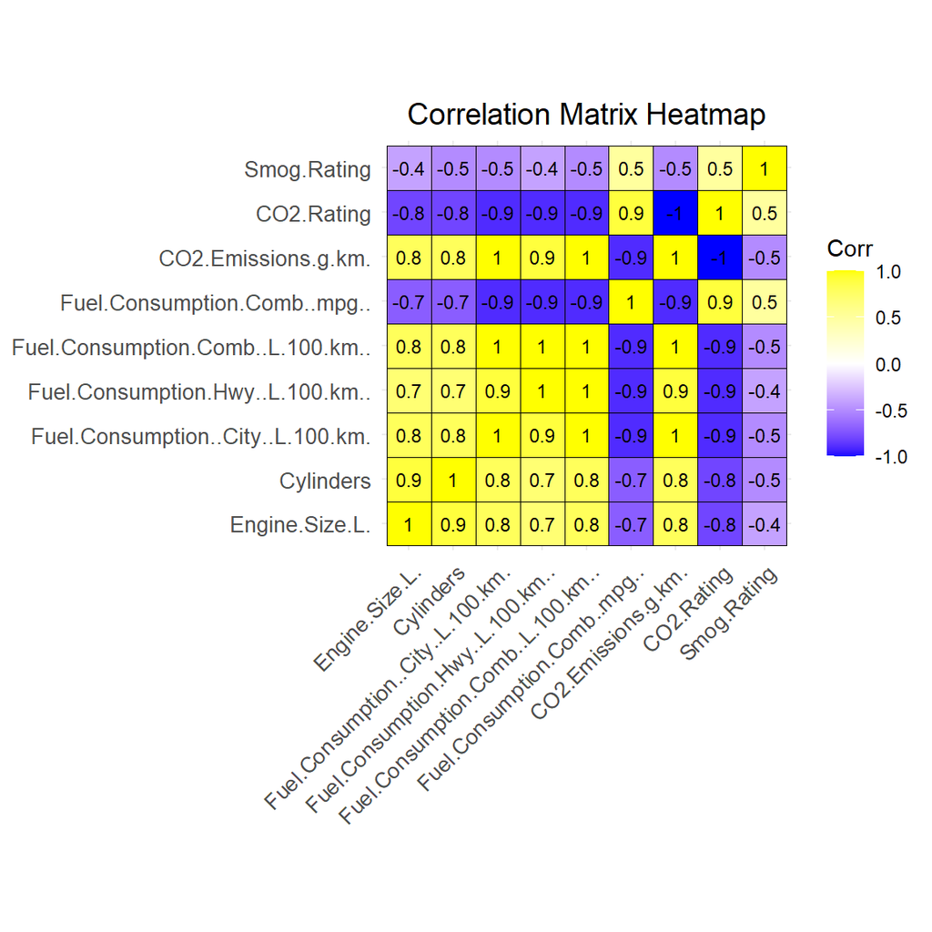

```r
library(ggcorrplot)

# Drop column "Model.Year"
Data_4 <- subset(Data_4, select = -Model.Year)
Data_4_numeric <- Data_4[, sapply(Data_4, is.numeric)]

# Compute correlation matrix for selected variables
cor_matrix <- round(cor(Data_4_numeric),1)

# Create the heatmap with readable text and labels
ggcorrplot(cor_matrix,
           method = "square",
           type = "full",   # Full correlation matrix
           lab = TRUE,      # Show correlation values
           lab_size = 3,    # Reduce label size for better readability
           colors = c("blue", "white", "yellow"),  # Clearer color gradient
           outline.color = "black",  # Add black grid for clarity
           title = "Correlation Matrix Heatmap",
           ggtheme = theme_minimal()) +
  theme(axis.text.x = element_text(angle = 45, hjust = 1, vjust = 1, size = 10),  # Rotate x-axis labels for readability
        axis.text.y = element_text(size = 10),  # Keep y-axis readable
        plot.title = element_text(hjust = 0.5, size = 14))  # Center and adjust title size
```

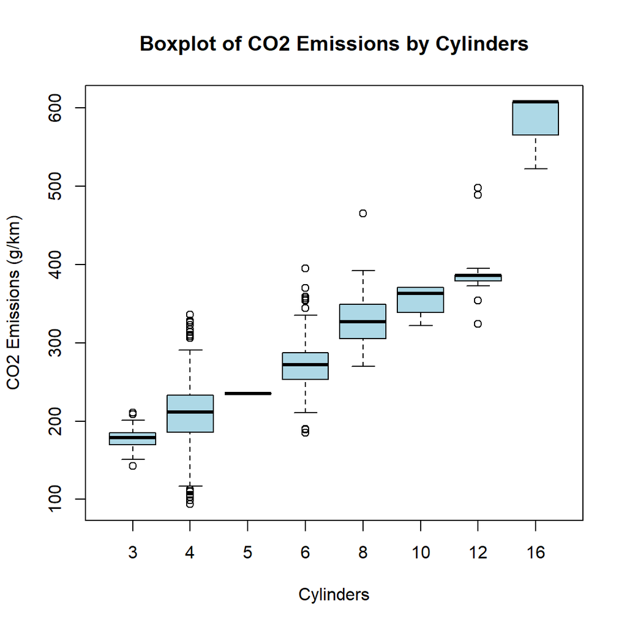

```r
# Create boxplots for all numeric columns
boxplot(CO2.Emissions.g.km. ~ Cylinders, data = Data_4,
        main = "Boxplot of CO2 Emissions by Cylinders",
        xlab = "Cylinders", ylab = "CO2 Emissions (g/km)",
        col = "lightblue", border = "black")
```

```r
library(GGally)
```